# Supervised Learning : Cost-Sensitive Learning for Severe Class Imbalance

[John Pauline Pineda](https://github.com/JohnPaulinePineda)

December 13, 2022

# **1. Table of Contents**

This project explores different cost-sensitive procedures for handling imbalanced data for classification using various helpful packages in **R**. Methods applied in the analysis to address imbalanced data included model structures which support cost-sensitive learning, namely **Class-Weighted Support Vector Machine**, **Cost-Sensitive Classification and Regression Trees** and **Cost-Sensitive C5.0 Decision Trees**. The resulting predictions derived from the candidate models were evaluated in terms of their discrimination power on the minority class using the specificity metric. The specificity values were compared to those of the baseline models without cost-sensitive learning applied. All results were consolidated in a **Summary** presented at the end of the document.  
Cost-sensitive learning and class weights address imbalanced classification problems when the cost of missing a minority class case might be different than incorrectly classifying an example from the majority class. In cost-sensitive learning, instead of each instance being either correctly or incorrectly classified, each class (or instance) is given a misclassification cost. Thus, instead of trying to optimize the accuracy, the problem is then to minimize the total misclassification cost. Meanwhile, class weights are adjustments made to reduce the bias towards the most occurring categories in the data and compensate for the underrepresentation of the minority class by increasing the importance on correctly identifying examples from this group. The algorithms applied in this study (mostly contained in the **caret** package) attempt to learn models on imbalanced data that have uneven penalties or costs when making predictions.

## 1.1 Sample Data

The **Sonar** dataset from the **mlbench** package was used for this illustrated example. The original dataset was transformed to simulate class imbalance.  
Preliminary dataset assessment:  
**[A]** 136 rows (observations)  
**[A.1]** Train Set = 96 observations with class ratio of 80:20  
**[A.2]** Test Set = 40 observations with class ratio of 80:20  
**[B]** 61 columns (variables)  
**[B.1]** 1/61 response = Class variable (factor)  
**[B.1.1]** Levels = Class=R < Class=M  
**[B.2]** 60/61 predictors = All remaining variables (60/60 numeric)

**Code Chunk | Output**

```r
##################################
# Loading R libraries
##################################
library(AppliedPredictiveModeling)
library(caret)
library(rpart)
library(lattice)
library(dplyr)
library(tidyr)
library(moments)
library(skimr)
library(RANN)
library(mlbench)
library(pls)
library(corrplot)
library(tidyverse)
library(lares)
library(DMwR2)
library(gridExtra)
library(rattle)
library(rpart.plot)
library(RColorBrewer)
library(stats)
library(nnet)
library(elasticnet)
library(earth)
library(party)
library(kernlab)
library(randomForest)
library(Cubist)
library(pROC)
library(mda)
library(klaR)
library(pamr)
library(MLmetrics)
library(C50)

##################################
# Loading source and
# formulating the train set
##################################
data(Sonar)

Sonar.Original <- Sonar

Sonar.M <- Sonar[Sonar$Class=="M",]
Sonar.R <- Sonar[Sonar$Class=="R",]
set.seed(12345678)
Sonar.R.Reduced <- Sonar.R[sample(1:nrow(Sonar.R),25),]

Sonar <- as.data.frame(rbind(Sonar.M,Sonar.R.Reduced))

set.seed(12345678)
Sonar_Partition <- createDataPartition(Sonar$Class, p = .70, list = FALSE)
Sonar_Train <- Sonar[Sonar_Partition,]
Sonar_Test  <- Sonar[-Sonar_Partition,]

##################################
# Performing a general exploration of the train set
##################################
dim(Sonar_Train)
```

```
## [1] 96 61
```

```r
str(Sonar_Train)
```

```
## 'data.frame':    96 obs. of  61 variables:
##  $ V1   : num  0.0629 0.0587 0.0428 0.0599 0.0264 0.0454 0.0283 0.0114 0.0414 0.0228 ...
##  $ V2   : num  0.1065 0.121 0.0555 0.0474 0.0071 ...
##  $ V3   : num  0.1526 0.1268 0.0708 0.0498 0.0342 ...
##  $ V4   : num  0.1229 0.1498 0.0618 0.0387 0.0793 ...
##  $ V5   : num  0.144 0.144 0.121 0.103 0.104 ...
##  $ V6   : num  0.119 0.0561 0.1524 0.0773 0.0783 ...
##  $ V7   : num  0.0884 0.0832 0.1543 0.0853 0.1417 ...
##  $ V8   : num  0.0907 0.0672 0.0391 0.0447 0.1176 ...
##  $ V9   : num  0.2107 0.1372 0.061 0.1094 0.0453 ...
##  $ V10  : num  0.3597 0.2352 0.0113 0.0351 0.0945 ...
##  $ V11  : num  0.547 0.321 0.126 0.158 0.113 ...
##  $ V12  : num  0.52 0.426 0.247 0.202 0.084 ...
##  $ V13  : num  0.5127 0.5201 0.3011 0.2268 0.0717 ...
##  $ V14  : num  0.539 0.491 0.375 0.283 0.197 ...
```

[output cut: 47 more lines]

```r
summary(Sonar_Train)
```

```
##        V1                V2                V3                V4
##  Min.   :0.00150   Min.   :0.00060   Min.   :0.00150   Min.   :0.00580
##  1st Qu.:0.01362   1st Qu.:0.01897   1st Qu.:0.02448   1st Qu.:0.02960
##  Median :0.02320   Median :0.03385   Median :0.03880   Median :0.04905
##  Mean   :0.03171   Mean   :0.04387   Mean   :0.04718   Mean   :0.05631
##  3rd Qu.:0.03982   3rd Qu.:0.05892   3rd Qu.:0.06212   3rd Qu.:0.07220
##  Max.   :0.13710   Max.   :0.15740   Max.   :0.16650   Max.   :0.16440
##        V5                V6               V7               V8
##  Min.   :0.00670   Min.   :0.0102   Min.   :0.0182   Min.   :0.0124
##  1st Qu.:0.04530   1st Qu.:0.0782   1st Qu.:0.0937   1st Qu.:0.0950
##  Median :0.07430   Median :0.1135   Median :0.1298   Median :0.1356
##  Mean   :0.08196   Mean   :0.1178   Mean   :0.1332   Mean   :0.1511
##  3rd Qu.:0.10855   3rd Qu.:0.1496   3rd Qu.:0.1683   3rd Qu.:0.1906
##  Max.   :0.24820   Max.   :0.3823   Max.   :0.3729   Max.   :0.4566
##        V9              V10              V11              V12
##  Min.   :0.0075   Min.   :0.0113   Min.   :0.0526   Min.   :0.0236
##  1st Qu.:0.1299   1st Qu.:0.1424   1st Qu.:0.1926   1st Qu.:0.1837
##  Median :0.1815   Median :0.2124   Median :0.2515   Median :0.2781
##  Mean   :0.2039   Mean   :0.2334   Mean   :0.2662   Mean   :0.2796
##  3rd Qu.:0.2596   3rd Qu.:0.2940   3rd Qu.:0.3335   3rd Qu.:0.3501
##  Max.   :0.6828   Max.   :0.5965   Max.   :0.6675   Max.   :0.5679
##       V13              V14              V15              V16
##  Min.   :0.0616   Min.   :0.0273   Min.   :0.0092   Min.   :0.0422
##  1st Qu.:0.2122   1st Qu.:0.1855   1st Qu.:0.1673   1st Qu.:0.1911
##  Median :0.2930   Median :0.2904   Median :0.2751   Median :0.3203
##  Mean   :0.3021   Mean   :0.3139   Mean   :0.3194   Mean   :0.3753
##  3rd Qu.:0.3730   3rd Qu.:0.4051   3rd Qu.:0.4403   3rd Qu.:0.5332
##  Max.   :0.7131   Max.   :0.9970   Max.   :0.9137   Max.   :0.9751
##       V17              V18              V19              V20
##  Min.   :0.0367   Min.   :0.0375   Min.   :0.1316   Min.   :0.0656
##  1st Qu.:0.2087   1st Qu.:0.2427   1st Qu.:0.2964   1st Qu.:0.3972
##  Median :0.3160   Median :0.3730   Median :0.4462   Median :0.6223
##  Mean   :0.4137   Mean   :0.4475   Mean   :0.5134   Mean   :0.5861
##  3rd Qu.:0.6466   3rd Qu.:0.6731   3rd Qu.:0.7310   3rd Qu.:0.7978
##  Max.   :1.0000   Max.   :0.9335   Max.   :0.9828   Max.   :1.0000
##       V21              V22              V23              V24
##  Min.   :0.0512   Min.   :0.0219   Min.   :0.0610   Min.   :0.0502
##  1st Qu.:0.4412   1st Qu.:0.3991   1st Qu.:0.4533   1st Qu.:0.5795
##  Median :0.6939   Median :0.7021   Median :0.7139   Median :0.6985
##  Mean   :0.6393   Mean   :0.6364   Mean   :0.6500   Mean   :0.6795
```

[output cut: 57 more lines]

```
##  Max.   :0.036100   Max.   :0.035200   Max.   :0.044700   Max.   :0.039400
##       V57                V58                V59                V60
##  Min.   :0.001100   Min.   :0.000900   Min.   :0.000100   Min.   :0.000600
##  1st Qu.:0.003700   1st Qu.:0.003600   1st Qu.:0.003550   1st Qu.:0.003100
##  Median :0.005750   Median :0.006300   Median :0.007000   Median :0.005100
##  Mean   :0.007678   Mean   :0.008472   Mean   :0.008259   Mean   :0.006066
##  3rd Qu.:0.010725   3rd Qu.:0.010275   3rd Qu.:0.010750   3rd Qu.:0.008125
##  Max.   :0.035500   Max.   :0.044000   Max.   :0.029400   Max.   :0.021800
##  Class
##  M:78
##  R:18
##
##
##
##
```

```r
##################################
# Performing a general exploration of the test set
##################################
dim(Sonar_Test)
```

```
## [1] 40 61
```

```r
str(Sonar_Test)
```

```
## 'data.frame':    40 obs. of  61 variables:
##  $ V1   : num  0.0491 0.1313 0.0201 0.0335 0.0162 ...
##  $ V2   : num  0.0279 0.2339 0.0423 0.0134 0.0253 ...
##  $ V3   : num  0.0592 0.3059 0.0554 0.0696 0.0262 ...
##  $ V4   : num  0.127 0.4264 0.0783 0.118 0.0386 ...
##  $ V5   : num  0.1772 0.401 0.062 0.0348 0.0645 ...
##  $ V6   : num  0.1908 0.1791 0.0871 0.118 0.0472 ...
##  $ V7   : num  0.222 0.185 0.12 0.195 0.106 ...
##  $ V8   : num  0.0768 0.0055 0.2707 0.1607 0.1388 ...
##  $ V9   : num  0.1246 0.1929 0.1206 0.3036 0.0598 ...
##  $ V10  : num  0.2028 0.2231 0.0279 0.4372 0.1334 ...
##  $ V11  : num  0.0947 0.2907 0.2251 0.5533 0.2969 ...
##  $ V12  : num  0.25 0.226 0.262 0.577 0.475 ...
##  $ V13  : num  0.221 0.314 0.177 0.702 0.568 ...
##  $ V14  : num  0.32 0.33 0.371 0.707 0.569 ...
```

[output cut: 47 more lines]

```r
summary(Sonar_Test)
```

```
##        V1                V2                V3                V4
##  Min.   :0.00470   Min.   :0.00220   Min.   :0.00450   Min.   :0.00760
##  1st Qu.:0.01620   1st Qu.:0.01392   1st Qu.:0.01770   1st Qu.:0.02615
##  Median :0.02495   Median :0.03190   Median :0.03660   Median :0.04465
##  Mean   :0.03229   Mean   :0.03954   Mean   :0.04819   Mean   :0.07107
##  3rd Qu.:0.03665   3rd Qu.:0.04850   3rd Qu.:0.05635   3rd Qu.:0.08830
##  Max.   :0.13130   Max.   :0.23390   Max.   :0.30590   Max.   :0.42640
##        V5                V6                V7                V8
##  Min.   :0.00970   Min.   :0.02260   Min.   :0.00330   Min.   :0.00550
##  1st Qu.:0.03470   1st Qu.:0.05325   1st Qu.:0.06792   1st Qu.:0.08903
##  Median :0.06155   Median :0.07610   Median :0.09480   Median :0.11180
##  Mean   :0.08154   Mean   :0.08995   Mean   :0.11237   Mean   :0.12967
##  3rd Qu.:0.08470   3rd Qu.:0.11365   3rd Qu.:0.14510   3rd Qu.:0.15188
##  Max.   :0.40100   Max.   :0.22470   Max.   :0.33220   Max.   :0.45900
##        V9              V10              V11              V12
##  Min.   :0.0494   Min.   :0.0193   Min.   :0.0523   Min.   :0.0259
##  1st Qu.:0.1000   1st Qu.:0.1261   1st Qu.:0.1572   1st Qu.:0.2245
##  Median :0.1439   Median :0.1813   Median :0.2363   Median :0.2599
##  Mean   :0.1795   Mean   :0.2212   Mean   :0.2595   Mean   :0.2809
##  3rd Qu.:0.2196   3rd Qu.:0.2596   3rd Qu.:0.2991   3rd Qu.:0.3141
##  Max.   :0.5664   Max.   :0.7106   Max.   :0.7342   Max.   :0.5771
##       V13              V14              V15              V16
##  Min.   :0.1184   Min.   :0.0336   Min.   :0.0166   Min.   :0.0572
##  1st Qu.:0.2081   1st Qu.:0.2122   1st Qu.:0.1990   1st Qu.:0.2072
##  Median :0.2581   Median :0.2959   Median :0.3125   Median :0.3199
##  Mean   :0.2880   Mean   :0.3048   Mean   :0.3301   Mean   :0.3778
##  3rd Qu.:0.3155   3rd Qu.:0.3464   3rd Qu.:0.4298   3rd Qu.:0.5161
##  Max.   :0.7022   Max.   :0.7067   Max.   :0.7367   Max.   :0.8278
##       V17              V18              V19              V20
##  Min.   :0.1162   Min.   :0.0837   Min.   :0.1151   Min.   :0.0902
##  1st Qu.:0.2159   1st Qu.:0.2492   1st Qu.:0.3366   1st Qu.:0.3652
##  Median :0.3154   Median :0.3607   Median :0.5134   Median :0.6252
##  Mean   :0.4086   Mean   :0.4693   Mean   :0.5419   Mean   :0.5995
##  3rd Qu.:0.6000   3rd Qu.:0.6776   3rd Qu.:0.8178   3rd Qu.:0.8684
##  Max.   :0.8999   Max.   :1.0000   Max.   :0.9975   Max.   :0.9911
##       V21              V22              V23              V24
##  Min.   :0.1354   Min.   :0.1127   Min.   :0.0563   Min.   :0.0239
##  1st Qu.:0.4244   1st Qu.:0.4482   1st Qu.:0.5467   1st Qu.:0.5782
##  Median :0.7064   Median :0.7190   Median :0.7579   Median :0.7542
##  Mean   :0.6382   Mean   :0.6577   Mean   :0.6836   Mean   :0.7058
```

[output cut: 57 more lines]

```
##  Max.   :0.039000   Max.   :0.03350   Max.   :0.037600   Max.   :0.02770
##       V57                V58                V59                V60
##  Min.   :0.000900   Min.   :0.000600   Min.   :0.000200   Min.   :0.00150
##  1st Qu.:0.003425   1st Qu.:0.003600   1st Qu.:0.003575   1st Qu.:0.00310
##  Median :0.005800   Median :0.005800   Median :0.006000   Median :0.00570
##  Mean   :0.007403   Mean   :0.008155   Mean   :0.009057   Mean   :0.00817
##  3rd Qu.:0.009025   3rd Qu.:0.011650   3rd Qu.:0.012450   3rd Qu.:0.01020
##  Max.   :0.024200   Max.   :0.037700   Max.   :0.036400   Max.   :0.04390
##  Class
##  M:33
##  R: 7
##
##
##
##
```

```r
##################################
# Formulating a data type assessment summary
##################################
PDA <- Sonar_Train
(PDA.Summary <- data.frame(
  Column.Index=c(1:length(names(PDA))),
  Column.Name= names(PDA),
  Column.Type=sapply(PDA, function(x) class(x)),
  row.names=NULL)
)
```

```
##    Column.Index Column.Name Column.Type
## 1             1          V1     numeric
## 2             2          V2     numeric
## 3             3          V3     numeric
## 4             4          V4     numeric
## 5             5          V5     numeric
## 6             6          V6     numeric
## 7             7          V7     numeric
## 8             8          V8     numeric
## 9             9          V9     numeric
## 10           10         V10     numeric
## 11           11         V11     numeric
## 12           12         V12     numeric
## 13           13         V13     numeric
## 14           14         V14     numeric
```

[output cut: 47 more lines]

## 1.2 Data Quality Assessment

**[A]** No missing observations noted for any variable.  
**[B]** Low variance observed for 17 variables with First.Second.Mode.Ratio>5.  
**[B.1]** V9 variable (numeric)  
**[B.2]** V10 variable (numeric)  
**[B.3]** V12 variable (numeric)  
**[B.4]** V16 variable (numeric)  
**[B.5]** V19 variable (numeric)  
**[B.6]** V26 variable (numeric)  
**[B.7]** V28 variable (numeric)  
**[B.8]** V32 variable (numeric)  
**[B.9]** V34 variable (numeric)  
**[B.10]** V35 variable (numeric)  
**[B.11]** V37 variable (numeric)  
**[B.12]** V38 variable (numeric)  
**[B.13]** V41 variable (numeric)  
**[B.14]** V42 variable (numeric)  
**[B.15]** V43 variable (numeric)  
**[B.16]** V45 variable (numeric)  
**[B.17]** V48 variable (numeric)  
**[C]** No low variance noted for any variable with Unique.Count.Ratio<0.01.  
**[D]** No high skewness noted for any variable with Skewness>3 or Skewness<(-3).

**Code Chunk | Output**

```r
##################################
# Loading dataset
##################################
DQA <- Sonar_Train

##################################
# Formulating an overall data quality assessment summary
##################################
(DQA.Summary <- data.frame(
  Column.Index=c(1:length(names(DQA))),
  Column.Name= names(DQA),
  Column.Type=sapply(DQA, function(x) class(x)),
  Row.Count=sapply(DQA, function(x) nrow(DQA)),
  NA.Count=sapply(DQA,function(x)sum(is.na(x))),
  Fill.Rate=sapply(DQA,function(x)format(round((sum(!is.na(x))/nrow(DQA)),3),nsmall=3)),
  row.names=NULL)
)
```

```
##    Column.Index Column.Name Column.Type Row.Count NA.Count Fill.Rate
## 1             1          V1     numeric        96        0     1.000
## 2             2          V2     numeric        96        0     1.000
## 3             3          V3     numeric        96        0     1.000
## 4             4          V4     numeric        96        0     1.000
## 5             5          V5     numeric        96        0     1.000
## 6             6          V6     numeric        96        0     1.000
## 7             7          V7     numeric        96        0     1.000
## 8             8          V8     numeric        96        0     1.000
## 9             9          V9     numeric        96        0     1.000
## 10           10         V10     numeric        96        0     1.000
## 11           11         V11     numeric        96        0     1.000
## 12           12         V12     numeric        96        0     1.000
## 13           13         V13     numeric        96        0     1.000
## 14           14         V14     numeric        96        0     1.000
```

[output cut: 47 more lines]

```r
##################################
# Listing all predictors
##################################
DQA.Predictors <- DQA[,!names(DQA) %in% c("Class")]

##################################
# Listing all numeric predictors
##################################
DQA.Predictors.Numeric <- DQA.Predictors[,sapply(DQA.Predictors, is.numeric)]

if (length(names(DQA.Predictors.Numeric))>0) {
    print(paste0("There are ",
               (length(names(DQA.Predictors.Numeric))),
               " numeric predictor variable(s)."))
} else {
  print("There are no numeric predictor variables.")
}
```

```
## [1] "There are 60 numeric predictor variable(s)."
```

```r
##################################
# Listing all factor predictors
##################################
DQA.Predictors.Factor <- DQA.Predictors[,sapply(DQA.Predictors, is.factor)]

if (length(names(DQA.Predictors.Factor))>0) {
    print(paste0("There are ",
               (length(names(DQA.Predictors.Factor))),
               " factor predictor variable(s)."))
} else {
  print("There are no factor predictor variables.")
}
```

```
## [1] "There are no factor predictor variables."
```

```r
##################################
# Formulating a data quality assessment summary for factor predictors
##################################
if (length(names(DQA.Predictors.Factor))>0) {

  ##################################
  # Formulating a function to determine the first mode
  ##################################
  FirstModes <- function(x) {
    ux <- unique(na.omit(x))
    tab <- tabulate(match(x, ux))
    ux[tab == max(tab)]
  }

  ##################################
  # Formulating a function to determine the second mode
  ##################################
  SecondModes <- function(x) {
    ux <- unique(na.omit(x))
    tab <- tabulate(match(x, ux))
    fm = ux[tab == max(tab)]
    sm = x[!(x %in% fm)]
    usm <- unique(sm)
    tabsm <- tabulate(match(sm, usm))
    ifelse(is.na(usm[tabsm == max(tabsm)])==TRUE,
           return("x"),
           return(usm[tabsm == max(tabsm)]))
  }

  (DQA.Predictors.Factor.Summary <- data.frame(
  Column.Name= names(DQA.Predictors.Factor),
  Column.Type=sapply(DQA.Predictors.Factor, function(x) class(x)),
  Unique.Count=sapply(DQA.Predictors.Factor, function(x) length(unique(x))),
  First.Mode.Value=sapply(DQA.Predictors.Factor, function(x) as.character(FirstModes(x)[1])),
  Second.Mode.Value=sapply(DQA.Predictors.Factor, function(x) as.character(SecondModes(x)[1])),
  First.Mode.Count=sapply(DQA.Predictors.Factor, function(x) sum(na.omit(x) == FirstModes(x)[1])),
  Second.Mode.Count=sapply(DQA.Predictors.Factor, function(x) sum(na.omit(x) == SecondModes(x)[1])),
  Unique.Count.Ratio=sapply(DQA.Predictors.Factor, function(x) format(round((length(unique(x))/nrow(DQA.Predictors.Factor)),3), nsmall=3)),
  First.Second.Mode.Ratio=sapply(DQA.Predictors.Factor, function(x) format(round((sum(na.omit(x) == FirstModes(x)[1])/sum(na.omit(x) == SecondModes(x)[1])),3), nsmall=3)),
  row.names=NULL)
  )

}

##################################
# Formulating a data quality assessment summary for numeric predictors
##################################
if (length(names(DQA.Predictors.Numeric))>0) {

  ##################################
  # Formulating a function to determine the first mode
  ##################################
  FirstModes <- function(x) {
    ux <- unique(na.omit(x))
    tab <- tabulate(match(x, ux))
    ux[tab == max(tab)]
  }

  ##################################
  # Formulating a function to determine the second mode
  ##################################
  SecondModes <- function(x) {
    ux <- unique(na.omit(x))
    tab <- tabulate(match(x, ux))
    fm = ux[tab == max(tab)]
    sm = na.omit(x)[!(na.omit(x) %in% fm)]
    usm <- unique(sm)
    tabsm <- tabulate(match(sm, usm))
    ifelse(is.na(usm[tabsm == max(tabsm)])==TRUE,
           return(0.00001),
           return(usm[tabsm == max(tabsm)]))
  }

  (DQA.Predictors.Numeric.Summary <- data.frame(
  Column.Name= names(DQA.Predictors.Numeric),
  Column.Type=sapply(DQA.Predictors.Numeric, function(x) class(x)),
  Unique.Count=sapply(DQA.Predictors.Numeric, function(x) length(unique(x))),
  Unique.Count.Ratio=sapply(DQA.Predictors.Numeric, function(x) format(round((length(unique(x))/nrow(DQA.Predictors.Numeric)),3), nsmall=3)),
  First.Mode.Value=sapply(DQA.Predictors.Numeric, function(x) format(round((FirstModes(x)[1]),3),nsmall=3)),
  Second.Mode.Value=sapply(DQA.Predictors.Numeric, function(x) format(round((SecondModes(x)[1]),3),nsmall=3)),
  First.Mode.Count=sapply(DQA.Predictors.Numeric, function(x) sum(na.omit(x) == FirstModes(x)[1])),
  Second.Mode.Count=sapply(DQA.Predictors.Numeric, function(x) sum(na.omit(x) == SecondModes(x)[1])),
  First.Second.Mode.Ratio=sapply(DQA.Predictors.Numeric, function(x) format(round((sum(na.omit(x) == FirstModes(x)[1])/sum(na.omit(x) == SecondModes(x)[1])),3), nsmall=3)),
  Minimum=sapply(DQA.Predictors.Numeric, function(x) format(round(min(x,na.rm = TRUE),3), nsmall=3)),
  Mean=sapply(DQA.Predictors.Numeric, function(x) format(round(mean(x,na.rm = TRUE),3), nsmall=3)),
  Median=sapply(DQA.Predictors.Numeric, function(x) format(round(median(x,na.rm = TRUE),3), nsmall=3)),
  Maximum=sapply(DQA.Predictors.Numeric, function(x) format(round(max(x,na.rm = TRUE),3), nsmall=3)),
  Skewness=sapply(DQA.Predictors.Numeric, function(x) format(round(skewness(x,na.rm = TRUE),3), nsmall=3)),
  Kurtosis=sapply(DQA.Predictors.Numeric, function(x) format(round(kurtosis(x,na.rm = TRUE),3), nsmall=3)),
  Percentile25th=sapply(DQA.Predictors.Numeric, function(x) format(round(quantile(x,probs=0.25,na.rm = TRUE),3), nsmall=3)),
  Percentile75th=sapply(DQA.Predictors.Numeric, function(x) format(round(quantile(x,probs=0.75,na.rm = TRUE),3), nsmall=3)),
  row.names=NULL)
  )

}
```

```
##    Column.Name Column.Type Unique.Count Unique.Count.Ratio First.Mode.Value
## 1           V1     numeric           91              0.948            0.021
## 2           V2     numeric           93              0.969            0.019
## 3           V3     numeric           92              0.958            0.030
## 4           V4     numeric           90              0.938            0.061
## 5           V5     numeric           93              0.969            0.112
## 6           V6     numeric           94              0.979            0.152
## 7           V7     numeric           94              0.979            0.149
## 8           V8     numeric           95              0.990            0.168
## 9           V9     numeric           96              1.000            0.211
## 10         V10     numeric           96              1.000            0.360
## 11         V11     numeric           94              0.979            0.213
## 12         V12     numeric           96              1.000            0.520
## 13         V13     numeric           95              0.990            0.286
## 14         V14     numeric           93              0.969            0.290
```

[output cut: 168 more lines]

```r
##################################
# Identifying potential data quality issues
##################################

##################################
# Checking for missing observations
##################################
if ((nrow(DQA.Summary[DQA.Summary$NA.Count>0,]))>0){
  print(paste0("Missing observations noted for ",
               (nrow(DQA.Summary[DQA.Summary$NA.Count>0,])),
               " variable(s) with NA.Count>0 and Fill.Rate<1.0."))
  DQA.Summary[DQA.Summary$NA.Count>0,]
} else {
  print("No missing observations noted.")
}
```

```
## [1] "No missing observations noted."
```

```r
##################################
# Checking for zero or near-zero variance predictors
##################################
if (length(names(DQA.Predictors.Factor))==0) {
  print("No factor predictors noted.")
} else if (nrow(DQA.Predictors.Factor.Summary[as.numeric(as.character(DQA.Predictors.Factor.Summary$First.Second.Mode.Ratio))>5,])>0){
  print(paste0("Low variance observed for ",
               (nrow(DQA.Predictors.Factor.Summary[as.numeric(as.character(DQA.Predictors.Factor.Summary$First.Second.Mode.Ratio))>5,])),
               " factor variable(s) with First.Second.Mode.Ratio>5."))
  DQA.Predictors.Factor.Summary[as.numeric(as.character(DQA.Predictors.Factor.Summary$First.Second.Mode.Ratio))>5,]
} else {
  print("No low variance factor predictors due to high first-second mode ratio noted.")
}
```

```
## [1] "No factor predictors noted."
```

```r
if (length(names(DQA.Predictors.Numeric))==0) {
  print("No numeric predictors noted.")
} else if (nrow(DQA.Predictors.Numeric.Summary[as.numeric(as.character(DQA.Predictors.Numeric.Summary$First.Second.Mode.Ratio))>5,])>0){
  print(paste0("Low variance observed for ",
               (nrow(DQA.Predictors.Numeric.Summary[as.numeric(as.character(DQA.Predictors.Numeric.Summary$First.Second.Mode.Ratio))>5,])),
               " numeric variable(s) with First.Second.Mode.Ratio>5."))
  DQA.Predictors.Numeric.Summary[as.numeric(as.character(DQA.Predictors.Numeric.Summary$First.Second.Mode.Ratio))>5,]
} else {
  print("No low variance numeric predictors due to high first-second mode ratio noted.")
}
```

```
## [1] "Low variance observed for 17 numeric variable(s) with First.Second.Mode.Ratio>5."
```

```
##    Column.Name Column.Type Unique.Count Unique.Count.Ratio First.Mode.Value
## 9           V9     numeric           96              1.000            0.211
## 10         V10     numeric           96              1.000            0.360
## 12         V12     numeric           96              1.000            0.520
## 16         V16     numeric           96              1.000            0.871
## 19         V19     numeric           96              1.000            0.792
## 26         V26     numeric           91              0.948            1.000
## 28         V28     numeric           88              0.917            1.000
## 32         V32     numeric           96              1.000            0.189
## 34         V34     numeric           96              1.000            0.196
## 35         V35     numeric           96              1.000            0.267
## 37         V37     numeric           96              1.000            0.107
## 38         V38     numeric           96              1.000            0.202
## 41         V41     numeric           96              1.000            0.131
## 42         V42     numeric           96              1.000            0.178
```

[output cut: 39 more lines]

```r
if (length(names(DQA.Predictors.Numeric))==0) {
  print("No numeric predictors noted.")
} else if (nrow(DQA.Predictors.Numeric.Summary[as.numeric(as.character(DQA.Predictors.Numeric.Summary$Unique.Count.Ratio))<0.01,])>0){
  print(paste0("Low variance observed for ",
               (nrow(DQA.Predictors.Numeric.Summary[as.numeric(as.character(DQA.Predictors.Numeric.Summary$Unique.Count.Ratio))<0.01,])),
               " numeric variable(s) with Unique.Count.Ratio<0.01."))
  DQA.Predictors.Numeric.Summary[as.numeric(as.character(DQA.Predictors.Numeric.Summary$Unique.Count.Ratio))<0.01,]
} else {
  print("No low variance numeric predictors due to low unique count ratio noted.")
}
```

```
## [1] "No low variance numeric predictors due to low unique count ratio noted."
```

```r
##################################
# Checking for skewed predictors
##################################
if (length(names(DQA.Predictors.Numeric))==0) {
  print("No numeric predictors noted.")
} else if (nrow(DQA.Predictors.Numeric.Summary[as.numeric(as.character(DQA.Predictors.Numeric.Summary$Skewness))>3 |
                                               as.numeric(as.character(DQA.Predictors.Numeric.Summary$Skewness))<(-3),])>0){
  print(paste0("High skewness observed for ",
  (nrow(DQA.Predictors.Numeric.Summary[as.numeric(as.character(DQA.Predictors.Numeric.Summary$Skewness))>3 |
                                               as.numeric(as.character(DQA.Predictors.Numeric.Summary$Skewness))<(-3),])),
  " numeric variable(s) with Skewness>3 or Skewness<(-3)."))
  DQA.Predictors.Numeric.Summary[as.numeric(as.character(DQA.Predictors.Numeric.Summary$Skewness))>3 |
                                 as.numeric(as.character(DQA.Predictors.Numeric.Summary$Skewness))<(-3),]
} else {
  print("No skewed numeric predictors noted.")
}
```

```
## [1] "No skewed numeric predictors noted."
```

## 1.3 Data Preprocessing

### 1.3.1 Outlier

**Code Chunk | Output**

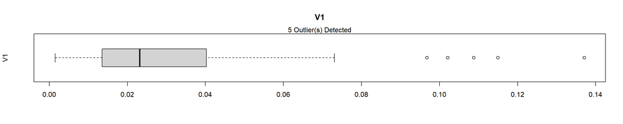

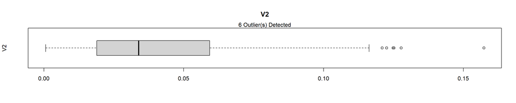

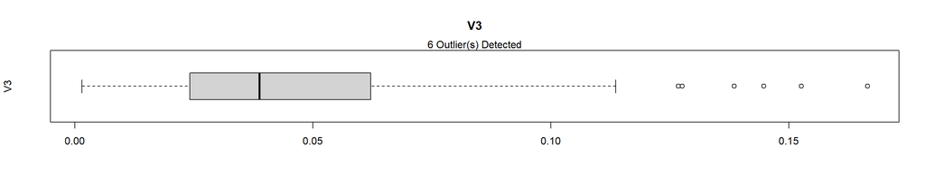

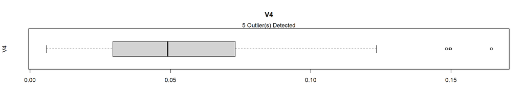

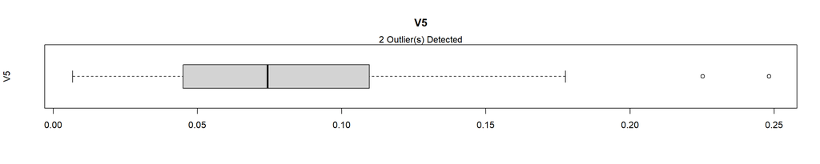

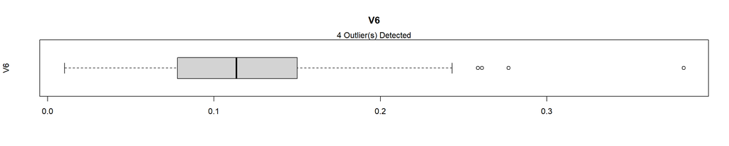

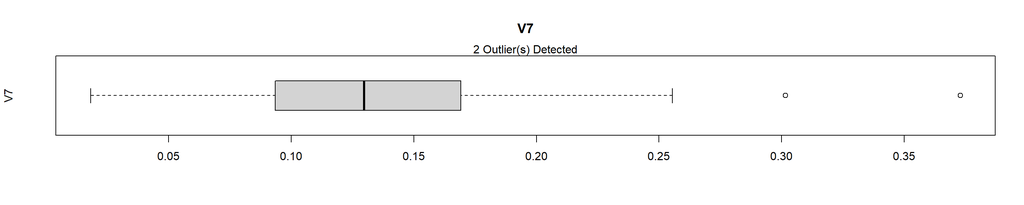

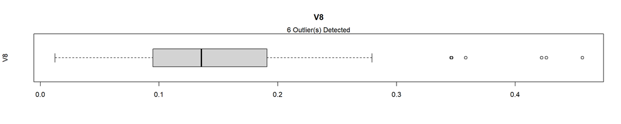

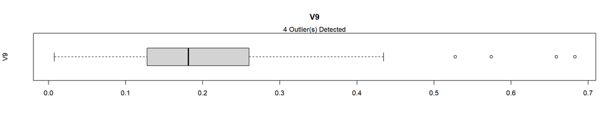

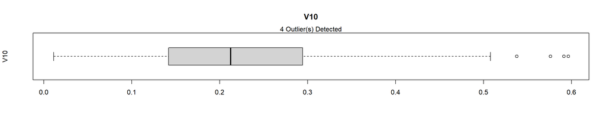

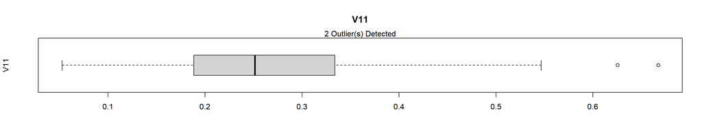

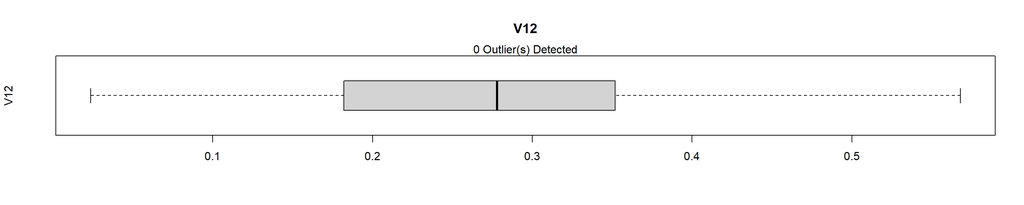

[48 more figures not shown]

```r
##################################
# Loading dataset
##################################
DPA <- Sonar_Train

##################################
# Listing all predictors
##################################
DPA.Predictors <- DPA[,!names(DPA) %in% c("Class")]

##################################
# Listing all numeric predictors
##################################
DPA.Predictors.Numeric <- DPA.Predictors[,sapply(DPA.Predictors, is.numeric)]

##################################
# Identifying outliers for the numeric predictors
##################################
OutlierCountList <- c()

for (i in 1:ncol(DPA.Predictors.Numeric)) {
  Outliers <- boxplot.stats(DPA.Predictors.Numeric[,i])$out
  OutlierCount <- length(Outliers)
  OutlierCountList <- append(OutlierCountList,OutlierCount)
  OutlierIndices <- which(DPA.Predictors.Numeric[,i] %in% c(Outliers))
  boxplot(DPA.Predictors.Numeric[,i],
          ylab = names(DPA.Predictors.Numeric)[i],
          main = names(DPA.Predictors.Numeric)[i],
          horizontal=TRUE)
  mtext(paste0(OutlierCount, " Outlier(s) Detected"))
}
```

```r
OutlierCountSummary <- as.data.frame(cbind(names(DPA.Predictors.Numeric),(OutlierCountList)))
names(OutlierCountSummary) <- c("NumericPredictors","OutlierCount")
OutlierCountSummary$OutlierCount <- as.numeric(as.character(OutlierCountSummary$OutlierCount))
NumericPredictorWithOutlierCount <- nrow(OutlierCountSummary[OutlierCountSummary$OutlierCount>0,])
print(paste0(NumericPredictorWithOutlierCount, " numeric variable(s) were noted with outlier(s)." ))
```

```
## [1] "38 numeric variable(s) were noted with outlier(s)."
```

```r
##################################
# Gathering descriptive statistics
##################################
(DPA_Skimmed <- skim(DPA.Predictors.Numeric))
```

Data summary

| Name | DPA.Predictors.Numeric |
| --- | --- |
| Number of rows | 96 |
| Number of columns | 60 |
| _______________________ |  |
| Column type frequency: |  |
| numeric | 60 |
| ________________________ |  |
| Group variables | None |

**Variable type: numeric**

| skim_variable | n_missing | complete_rate | mean | sd | p0 | p25 | p50 | p75 | p100 | hist |
| --- | --- | --- | --- | --- | --- | --- | --- | --- | --- | --- |
| V1 | 0 | 1 | 0.03 | 0.03 | 0.00 | 0.01 | 0.02 | 0.04 | 0.14 | ▇▃▂▁▁ |
| V2 | 0 | 1 | 0.04 | 0.03 | 0.00 | 0.02 | 0.03 | 0.06 | 0.16 | ▇▆▂▁▁ |
| V3 | 0 | 1 | 0.05 | 0.03 | 0.00 | 0.02 | 0.04 | 0.06 | 0.17 | ▇▆▂▁▁ |
| V4 | 0 | 1 | 0.06 | 0.04 | 0.01 | 0.03 | 0.05 | 0.07 | 0.16 | ▇▇▃▁▁ |
| V5 | 0 | 1 | 0.08 | 0.05 | 0.01 | 0.05 | 0.07 | 0.11 | 0.25 | ▇▇▅▁▁ |
| V6 | 0 | 1 | 0.12 | 0.06 | 0.01 | 0.08 | 0.11 | 0.15 | 0.38 | ▅▇▂▁▁ |
| V7 | 0 | 1 | 0.13 | 0.06 | 0.02 | 0.09 | 0.13 | 0.17 | 0.37 | ▃▇▃▁▁ |
| V8 | 0 | 1 | 0.15 | 0.09 | 0.01 | 0.10 | 0.14 | 0.19 | 0.46 | ▆▇▃▁▁ |
| V9 | 0 | 1 | 0.20 | 0.12 | 0.01 | 0.13 | 0.18 | 0.26 | 0.68 | ▅▇▃▁▁ |
| V10 | 0 | 1 | 0.23 | 0.13 | 0.01 | 0.14 | 0.21 | 0.29 | 0.60 | ▃▇▅▂▁ |
| V11 | 0 | 1 | 0.27 | 0.12 | 0.05 | 0.19 | 0.25 | 0.33 | 0.67 | ▅▇▅▂▁ |
| V12 | 0 | 1 | 0.28 | 0.13 | 0.02 | 0.18 | 0.28 | 0.35 | 0.57 | ▃▅▇▃▂ |
| V13 | 0 | 1 | 0.30 | 0.13 | 0.06 | 0.21 | 0.29 | 0.37 | 0.71 | ▃▇▅▂▁ |
| V14 | 0 | 1 | 0.31 | 0.17 | 0.03 | 0.19 | 0.29 | 0.41 | 1.00 | ▇▇▃▁▁ |
| V15 | 0 | 1 | 0.32 | 0.21 | 0.01 | 0.17 | 0.28 | 0.44 | 0.91 | ▇▅▆▁▁ |
| V16 | 0 | 1 | 0.38 | 0.23 | 0.04 | 0.19 | 0.32 | 0.53 | 0.98 | ▇▅▅▂▂ |
| V17 | 0 | 1 | 0.41 | 0.25 | 0.04 | 0.21 | 0.32 | 0.65 | 1.00 | ▇▇▃▅▂ |
| V18 | 0 | 1 | 0.45 | 0.25 | 0.04 | 0.24 | 0.37 | 0.67 | 0.93 | ▃▇▂▃▃ |
| V19 | 0 | 1 | 0.51 | 0.25 | 0.13 | 0.30 | 0.45 | 0.73 | 0.98 | ▇▇▃▅▅ |
| V20 | 0 | 1 | 0.59 | 0.26 | 0.07 | 0.40 | 0.62 | 0.80 | 1.00 | ▅▆▅▇▆ |
| V21 | 0 | 1 | 0.64 | 0.27 | 0.05 | 0.44 | 0.69 | 0.84 | 1.00 | ▂▃▅▆▇ |
| V22 | 0 | 1 | 0.64 | 0.27 | 0.02 | 0.40 | 0.70 | 0.85 | 1.00 | ▂▃▂▆▇ |
| V23 | 0 | 1 | 0.65 | 0.26 | 0.06 | 0.45 | 0.71 | 0.87 | 1.00 | ▂▂▃▅▇ |
| V24 | 0 | 1 | 0.68 | 0.24 | 0.05 | 0.58 | 0.70 | 0.90 | 1.00 | ▂▂▃▇▇ |
| V25 | 0 | 1 | 0.68 | 0.25 | 0.02 | 0.57 | 0.72 | 0.87 | 1.00 | ▂▂▃▇▇ |
| V26 | 0 | 1 | 0.71 | 0.22 | 0.16 | 0.56 | 0.76 | 0.88 | 1.00 | ▂▂▅▇▇ |
| V27 | 0 | 1 | 0.71 | 0.25 | 0.10 | 0.50 | 0.79 | 0.91 | 1.00 | ▁▂▂▃▇ |
| V28 | 0 | 1 | 0.71 | 0.25 | 0.06 | 0.56 | 0.78 | 0.91 | 1.00 | ▁▂▃▅▇ |
| V29 | 0 | 1 | 0.65 | 0.25 | 0.01 | 0.47 | 0.71 | 0.87 | 1.00 | ▂▂▅▅▇ |
| V30 | 0 | 1 | 0.59 | 0.22 | 0.06 | 0.41 | 0.60 | 0.72 | 1.00 | ▁▆▇▇▅ |
| V31 | 0 | 1 | 0.50 | 0.23 | 0.10 | 0.33 | 0.44 | 0.65 | 0.97 | ▃▇▅▃▃ |
| V32 | 0 | 1 | 0.44 | 0.22 | 0.09 | 0.28 | 0.41 | 0.58 | 0.93 | ▆▇▆▃▂ |
| V33 | 0 | 1 | 0.41 | 0.21 | 0.05 | 0.24 | 0.39 | 0.54 | 1.00 | ▆▇▇▃▁ |
| V34 | 0 | 1 | 0.39 | 0.22 | 0.06 | 0.22 | 0.36 | 0.54 | 0.95 | ▇▇▃▅▂ |
| V35 | 0 | 1 | 0.38 | 0.26 | 0.02 | 0.17 | 0.29 | 0.58 | 0.95 | ▇▆▃▃▂ |
| V36 | 0 | 1 | 0.36 | 0.28 | 0.01 | 0.14 | 0.28 | 0.53 | 1.00 | ▇▅▂▂▂ |
| V37 | 0 | 1 | 0.35 | 0.26 | 0.04 | 0.14 | 0.26 | 0.49 | 0.91 | ▇▃▂▁▃ |
| V38 | 0 | 1 | 0.35 | 0.22 | 0.06 | 0.17 | 0.32 | 0.44 | 0.95 | ▇▆▂▂▁ |
| V39 | 0 | 1 | 0.35 | 0.20 | 0.04 | 0.18 | 0.31 | 0.48 | 0.97 | ▇▇▅▂▁ |
| V40 | 0 | 1 | 0.32 | 0.18 | 0.02 | 0.20 | 0.28 | 0.43 | 0.93 | ▅▇▃▁▁ |
| V41 | 0 | 1 | 0.30 | 0.17 | 0.04 | 0.17 | 0.27 | 0.41 | 0.90 | ▇▇▃▂▁ |
| V42 | 0 | 1 | 0.31 | 0.18 | 0.04 | 0.17 | 0.28 | 0.40 | 0.82 | ▇▇▆▁▁ |
| V43 | 0 | 1 | 0.27 | 0.15 | 0.03 | 0.16 | 0.26 | 0.35 | 0.75 | ▆▇▅▂▁ |
| V44 | 0 | 1 | 0.24 | 0.14 | 0.03 | 0.14 | 0.19 | 0.31 | 0.58 | ▅▇▂▂▂ |
| V45 | 0 | 1 | 0.24 | 0.17 | 0.04 | 0.11 | 0.17 | 0.36 | 0.70 | ▇▃▂▂▁ |
| V46 | 0 | 1 | 0.19 | 0.16 | 0.01 | 0.08 | 0.14 | 0.23 | 0.73 | ▇▅▂▁▁ |
| V47 | 0 | 1 | 0.14 | 0.10 | 0.02 | 0.08 | 0.11 | 0.18 | 0.55 | ▇▃▁▁▁ |
| V48 | 0 | 1 | 0.11 | 0.07 | 0.01 | 0.05 | 0.09 | 0.14 | 0.33 | ▆▇▂▁▁ |
| V49 | 0 | 1 | 0.06 | 0.04 | 0.01 | 0.03 | 0.05 | 0.09 | 0.20 | ▇▇▃▂▁ |
| V50 | 0 | 1 | 0.02 | 0.02 | 0.00 | 0.01 | 0.02 | 0.03 | 0.08 | ▇▅▂▁▁ |
| V51 | 0 | 1 | 0.02 | 0.01 | 0.00 | 0.01 | 0.02 | 0.02 | 0.10 | ▇▃▁▁▁ |
| V52 | 0 | 1 | 0.02 | 0.01 | 0.00 | 0.01 | 0.01 | 0.02 | 0.07 | ▇▃▁▁▁ |
| V53 | 0 | 1 | 0.01 | 0.01 | 0.00 | 0.00 | 0.01 | 0.02 | 0.04 | ▇▃▃▁▁ |
| V54 | 0 | 1 | 0.01 | 0.01 | 0.00 | 0.01 | 0.01 | 0.02 | 0.04 | ▆▇▂▂▁ |
| V55 | 0 | 1 | 0.01 | 0.01 | 0.00 | 0.00 | 0.01 | 0.01 | 0.04 | ▇▃▁▁▁ |
| V56 | 0 | 1 | 0.01 | 0.01 | 0.00 | 0.00 | 0.01 | 0.01 | 0.04 | ▇▅▁▁▁ |
| V57 | 0 | 1 | 0.01 | 0.01 | 0.00 | 0.00 | 0.01 | 0.01 | 0.04 | ▇▅▁▁▁ |
| V58 | 0 | 1 | 0.01 | 0.01 | 0.00 | 0.00 | 0.01 | 0.01 | 0.04 | ▇▂▁▁▁ |
| V59 | 0 | 1 | 0.01 | 0.01 | 0.00 | 0.00 | 0.01 | 0.01 | 0.03 | ▇▇▂▁▁ |
| V60 | 0 | 1 | 0.01 | 0.00 | 0.00 | 0.00 | 0.01 | 0.01 | 0.02 | ▇▆▂▁▁ |

```r
###################################
# Verifying the data dimensions
###################################
dim(DPA.Predictors.Numeric)
```

```
## [1] 96 60
```

### 1.3.2 Zero and Near-Zero Variance

**[A]** Low variance noted for 17 variables from the previous data quality assessment using a lower threshold.  
**[B]** No low variance noted for any variables using a preprocessing summary from the **caret** package. The nearZeroVar method using both the freqCut and uniqueCut criteria set at 95/5 and 10, respectively, were applied on the dataset.

**Code Chunk | Output**

```r
##################################
# Loading dataset
##################################
DPA <- Sonar_Train

##################################
# Gathering descriptive statistics
##################################
(DPA_Skimmed <- skim(DPA))
```

Data summary

| Name | DPA |
| --- | --- |
| Number of rows | 96 |
| Number of columns | 61 |
| _______________________ |  |
| Column type frequency: |  |
| factor | 1 |
| numeric | 60 |
| ________________________ |  |
| Group variables | None |

**Variable type: factor**

| skim_variable | n_missing | complete_rate | ordered | n_unique | top_counts |
| --- | --- | --- | --- | --- | --- |
| Class | 0 | 1 | FALSE | 2 | M: 78, R: 18 |

**Variable type: numeric**

| skim_variable | n_missing | complete_rate | mean | sd | p0 | p25 | p50 | p75 | p100 | hist |
| --- | --- | --- | --- | --- | --- | --- | --- | --- | --- | --- |
| V1 | 0 | 1 | 0.03 | 0.03 | 0.00 | 0.01 | 0.02 | 0.04 | 0.14 | ▇▃▂▁▁ |
| V2 | 0 | 1 | 0.04 | 0.03 | 0.00 | 0.02 | 0.03 | 0.06 | 0.16 | ▇▆▂▁▁ |
| V3 | 0 | 1 | 0.05 | 0.03 | 0.00 | 0.02 | 0.04 | 0.06 | 0.17 | ▇▆▂▁▁ |
| V4 | 0 | 1 | 0.06 | 0.04 | 0.01 | 0.03 | 0.05 | 0.07 | 0.16 | ▇▇▃▁▁ |
| V5 | 0 | 1 | 0.08 | 0.05 | 0.01 | 0.05 | 0.07 | 0.11 | 0.25 | ▇▇▅▁▁ |
| V6 | 0 | 1 | 0.12 | 0.06 | 0.01 | 0.08 | 0.11 | 0.15 | 0.38 | ▅▇▂▁▁ |
| V7 | 0 | 1 | 0.13 | 0.06 | 0.02 | 0.09 | 0.13 | 0.17 | 0.37 | ▃▇▃▁▁ |
| V8 | 0 | 1 | 0.15 | 0.09 | 0.01 | 0.10 | 0.14 | 0.19 | 0.46 | ▆▇▃▁▁ |
| V9 | 0 | 1 | 0.20 | 0.12 | 0.01 | 0.13 | 0.18 | 0.26 | 0.68 | ▅▇▃▁▁ |
| V10 | 0 | 1 | 0.23 | 0.13 | 0.01 | 0.14 | 0.21 | 0.29 | 0.60 | ▃▇▅▂▁ |
| V11 | 0 | 1 | 0.27 | 0.12 | 0.05 | 0.19 | 0.25 | 0.33 | 0.67 | ▅▇▅▂▁ |
| V12 | 0 | 1 | 0.28 | 0.13 | 0.02 | 0.18 | 0.28 | 0.35 | 0.57 | ▃▅▇▃▂ |
| V13 | 0 | 1 | 0.30 | 0.13 | 0.06 | 0.21 | 0.29 | 0.37 | 0.71 | ▃▇▅▂▁ |
| V14 | 0 | 1 | 0.31 | 0.17 | 0.03 | 0.19 | 0.29 | 0.41 | 1.00 | ▇▇▃▁▁ |
| V15 | 0 | 1 | 0.32 | 0.21 | 0.01 | 0.17 | 0.28 | 0.44 | 0.91 | ▇▅▆▁▁ |
| V16 | 0 | 1 | 0.38 | 0.23 | 0.04 | 0.19 | 0.32 | 0.53 | 0.98 | ▇▅▅▂▂ |
| V17 | 0 | 1 | 0.41 | 0.25 | 0.04 | 0.21 | 0.32 | 0.65 | 1.00 | ▇▇▃▅▂ |
| V18 | 0 | 1 | 0.45 | 0.25 | 0.04 | 0.24 | 0.37 | 0.67 | 0.93 | ▃▇▂▃▃ |
| V19 | 0 | 1 | 0.51 | 0.25 | 0.13 | 0.30 | 0.45 | 0.73 | 0.98 | ▇▇▃▅▅ |
| V20 | 0 | 1 | 0.59 | 0.26 | 0.07 | 0.40 | 0.62 | 0.80 | 1.00 | ▅▆▅▇▆ |
| V21 | 0 | 1 | 0.64 | 0.27 | 0.05 | 0.44 | 0.69 | 0.84 | 1.00 | ▂▃▅▆▇ |
| V22 | 0 | 1 | 0.64 | 0.27 | 0.02 | 0.40 | 0.70 | 0.85 | 1.00 | ▂▃▂▆▇ |
| V23 | 0 | 1 | 0.65 | 0.26 | 0.06 | 0.45 | 0.71 | 0.87 | 1.00 | ▂▂▃▅▇ |
| V24 | 0 | 1 | 0.68 | 0.24 | 0.05 | 0.58 | 0.70 | 0.90 | 1.00 | ▂▂▃▇▇ |
| V25 | 0 | 1 | 0.68 | 0.25 | 0.02 | 0.57 | 0.72 | 0.87 | 1.00 | ▂▂▃▇▇ |
| V26 | 0 | 1 | 0.71 | 0.22 | 0.16 | 0.56 | 0.76 | 0.88 | 1.00 | ▂▂▅▇▇ |
| V27 | 0 | 1 | 0.71 | 0.25 | 0.10 | 0.50 | 0.79 | 0.91 | 1.00 | ▁▂▂▃▇ |
| V28 | 0 | 1 | 0.71 | 0.25 | 0.06 | 0.56 | 0.78 | 0.91 | 1.00 | ▁▂▃▅▇ |
| V29 | 0 | 1 | 0.65 | 0.25 | 0.01 | 0.47 | 0.71 | 0.87 | 1.00 | ▂▂▅▅▇ |
| V30 | 0 | 1 | 0.59 | 0.22 | 0.06 | 0.41 | 0.60 | 0.72 | 1.00 | ▁▆▇▇▅ |
| V31 | 0 | 1 | 0.50 | 0.23 | 0.10 | 0.33 | 0.44 | 0.65 | 0.97 | ▃▇▅▃▃ |
| V32 | 0 | 1 | 0.44 | 0.22 | 0.09 | 0.28 | 0.41 | 0.58 | 0.93 | ▆▇▆▃▂ |
| V33 | 0 | 1 | 0.41 | 0.21 | 0.05 | 0.24 | 0.39 | 0.54 | 1.00 | ▆▇▇▃▁ |
| V34 | 0 | 1 | 0.39 | 0.22 | 0.06 | 0.22 | 0.36 | 0.54 | 0.95 | ▇▇▃▅▂ |
| V35 | 0 | 1 | 0.38 | 0.26 | 0.02 | 0.17 | 0.29 | 0.58 | 0.95 | ▇▆▃▃▂ |
| V36 | 0 | 1 | 0.36 | 0.28 | 0.01 | 0.14 | 0.28 | 0.53 | 1.00 | ▇▅▂▂▂ |
| V37 | 0 | 1 | 0.35 | 0.26 | 0.04 | 0.14 | 0.26 | 0.49 | 0.91 | ▇▃▂▁▃ |
| V38 | 0 | 1 | 0.35 | 0.22 | 0.06 | 0.17 | 0.32 | 0.44 | 0.95 | ▇▆▂▂▁ |
| V39 | 0 | 1 | 0.35 | 0.20 | 0.04 | 0.18 | 0.31 | 0.48 | 0.97 | ▇▇▅▂▁ |
| V40 | 0 | 1 | 0.32 | 0.18 | 0.02 | 0.20 | 0.28 | 0.43 | 0.93 | ▅▇▃▁▁ |
| V41 | 0 | 1 | 0.30 | 0.17 | 0.04 | 0.17 | 0.27 | 0.41 | 0.90 | ▇▇▃▂▁ |
| V42 | 0 | 1 | 0.31 | 0.18 | 0.04 | 0.17 | 0.28 | 0.40 | 0.82 | ▇▇▆▁▁ |
| V43 | 0 | 1 | 0.27 | 0.15 | 0.03 | 0.16 | 0.26 | 0.35 | 0.75 | ▆▇▅▂▁ |
| V44 | 0 | 1 | 0.24 | 0.14 | 0.03 | 0.14 | 0.19 | 0.31 | 0.58 | ▅▇▂▂▂ |
| V45 | 0 | 1 | 0.24 | 0.17 | 0.04 | 0.11 | 0.17 | 0.36 | 0.70 | ▇▃▂▂▁ |
| V46 | 0 | 1 | 0.19 | 0.16 | 0.01 | 0.08 | 0.14 | 0.23 | 0.73 | ▇▅▂▁▁ |
| V47 | 0 | 1 | 0.14 | 0.10 | 0.02 | 0.08 | 0.11 | 0.18 | 0.55 | ▇▃▁▁▁ |
| V48 | 0 | 1 | 0.11 | 0.07 | 0.01 | 0.05 | 0.09 | 0.14 | 0.33 | ▆▇▂▁▁ |
| V49 | 0 | 1 | 0.06 | 0.04 | 0.01 | 0.03 | 0.05 | 0.09 | 0.20 | ▇▇▃▂▁ |
| V50 | 0 | 1 | 0.02 | 0.02 | 0.00 | 0.01 | 0.02 | 0.03 | 0.08 | ▇▅▂▁▁ |
| V51 | 0 | 1 | 0.02 | 0.01 | 0.00 | 0.01 | 0.02 | 0.02 | 0.10 | ▇▃▁▁▁ |
| V52 | 0 | 1 | 0.02 | 0.01 | 0.00 | 0.01 | 0.01 | 0.02 | 0.07 | ▇▃▁▁▁ |
| V53 | 0 | 1 | 0.01 | 0.01 | 0.00 | 0.00 | 0.01 | 0.02 | 0.04 | ▇▃▃▁▁ |
| V54 | 0 | 1 | 0.01 | 0.01 | 0.00 | 0.01 | 0.01 | 0.02 | 0.04 | ▆▇▂▂▁ |
| V55 | 0 | 1 | 0.01 | 0.01 | 0.00 | 0.00 | 0.01 | 0.01 | 0.04 | ▇▃▁▁▁ |
| V56 | 0 | 1 | 0.01 | 0.01 | 0.00 | 0.00 | 0.01 | 0.01 | 0.04 | ▇▅▁▁▁ |
| V57 | 0 | 1 | 0.01 | 0.01 | 0.00 | 0.00 | 0.01 | 0.01 | 0.04 | ▇▅▁▁▁ |
| V58 | 0 | 1 | 0.01 | 0.01 | 0.00 | 0.00 | 0.01 | 0.01 | 0.04 | ▇▂▁▁▁ |
| V59 | 0 | 1 | 0.01 | 0.01 | 0.00 | 0.00 | 0.01 | 0.01 | 0.03 | ▇▇▂▁▁ |
| V60 | 0 | 1 | 0.01 | 0.00 | 0.00 | 0.00 | 0.01 | 0.01 | 0.02 | ▇▆▂▁▁ |

```r
##################################
# Identifying columns with low variance
###################################
DPA_LowVariance <- nearZeroVar(DPA,
                               freqCut = 95/5,
                               uniqueCut = 10,
                               saveMetrics= TRUE)
(DPA_LowVariance[DPA_LowVariance$nzv,])
```

```
## [1] freqRatio     percentUnique zeroVar       nzv
## <0 rows> (or 0-length row.names)
```

```r
if ((nrow(DPA_LowVariance[DPA_LowVariance$nzv,]))==0){

  print("No low variance predictors noted.")

} else {

  print(paste0("Low variance observed for ",
               (nrow(DPA_LowVariance[DPA_LowVariance$nzv,])),
               " numeric variable(s) with First.Second.Mode.Ratio>4 and Unique.Count.Ratio<0.10."))

  DPA_LowVarianceForRemoval <- (nrow(DPA_LowVariance[DPA_LowVariance$nzv,]))

  print(paste0("Low variance can be resolved by removing ",
               (nrow(DPA_LowVariance[DPA_LowVariance$nzv,])),
               " numeric variable(s)."))

  for (j in 1:DPA_LowVarianceForRemoval) {
  DPA_LowVarianceRemovedVariable <- rownames(DPA_LowVariance[DPA_LowVariance$nzv,])[j]
  print(paste0("Variable ",
               j,
               " for removal: ",
               DPA_LowVarianceRemovedVariable))
  }

  DPA %>%
  skim() %>%
  dplyr::filter(skim_variable %in% rownames(DPA_LowVariance[DPA_LowVariance$nzv,]))

  ##################################
  # Filtering out columns with low variance
  #################################
  DPA_ExcludedLowVariance <- DPA[,!names(DPA) %in% rownames(DPA_LowVariance[DPA_LowVariance$nzv,])]

  ##################################
  # Gathering descriptive statistics
  ##################################
  (DPA_ExcludedLowVariance_Skimmed <- skim(DPA_ExcludedLowVariance))

  ###################################
  # Verifying the data dimensions
  ###################################
  dim(DPA_ExcludedLowVariance)

}
```

```
## [1] "No low variance predictors noted."
```

### 1.3.3 Collinearity

**[A]** No high correlation > 95% were noted for any variable as confirmed using the preprocessing summaries from the **caret** and **lares** packages.

**Code Chunk | Output**

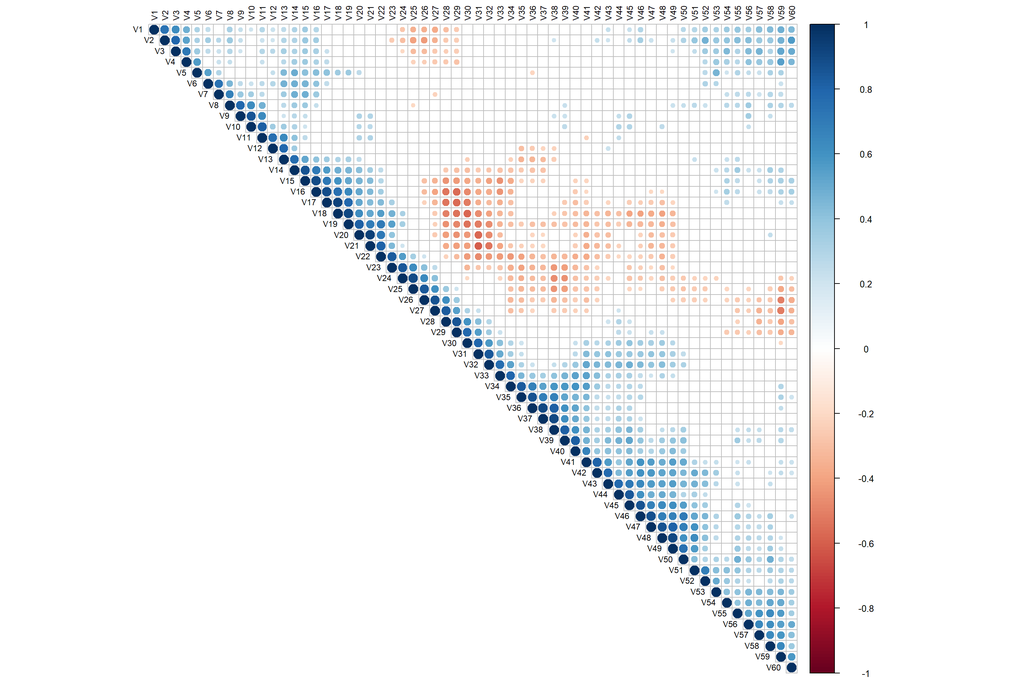

```r
##################################
# Loading dataset
##################################
DPA <- Sonar_Train

##################################
# Listing all predictors
##################################
DPA.Predictors <- DPA[,!names(DPA) %in% c("Class")]

##################################
# Listing all numeric predictors
##################################
DPA.Predictors.Numeric <- DPA.Predictors[,sapply(DPA.Predictors, is.numeric)]

##################################
# Visualizing pairwise correlation between predictors
##################################
DPA_CorrelationTest <- cor.mtest(DPA.Predictors.Numeric,
                       method = "pearson",
                       conf.level = .95)

corrplot(cor(DPA.Predictors.Numeric,
             method = "pearson",
             use="pairwise.complete.obs"),
         method = "circle",
         type = "upper",
         order = "original",
         tl.col = "black",
         tl.cex = 0.75,
         tl.srt = 90,
         sig.level = 0.05,
         p.mat = DPA_CorrelationTest$p,
         insig = "blank")
```

```r
##################################
# Identifying the highly correlated variables
##################################
DPA_Correlation <-  cor(DPA.Predictors.Numeric,
                        method = "pearson",
                        use="pairwise.complete.obs")
(DPA_HighlyCorrelatedCount <- sum(abs(DPA_Correlation[upper.tri(DPA_Correlation)]) > 0.95))
```

```
## [1] 0
```

```r
if (DPA_HighlyCorrelatedCount == 0) {

  print("No highly correlated predictors noted.")

} else {
  print(paste0("High correlation observed for ",
               (DPA_HighlyCorrelatedCount),
               " pairs of numeric variable(s) with Correlation.Coefficient>0.95."))

  (DPA_HighlyCorrelatedPairs <- corr_cross(DPA.Predictors.Numeric,
  max_pvalue = 0.05,
  top = DPA_HighlyCorrelatedCount,
  rm.na = TRUE,
  grid = FALSE
))

}
```

```
## [1] "No highly correlated predictors noted."
```

```r
if (DPA_HighlyCorrelatedCount > 0) {
  DPA_HighlyCorrelated <- findCorrelation(DPA_Correlation, cutoff = 0.95)

  (DPA_HighlyCorrelatedForRemoval <- length(DPA_HighlyCorrelated))

  print(paste0("High correlation can be resolved by removing ",
               (DPA_HighlyCorrelatedForRemoval),
               " numeric variable(s)."))

  for (j in 1:DPA_HighlyCorrelatedForRemoval) {
  DPA_HighlyCorrelatedRemovedVariable <- colnames(DPA.Predictors.Numeric)[DPA_HighlyCorrelated[j]]
  print(paste0("Variable ",
               j,
               " for removal: ",
               DPA_HighlyCorrelatedRemovedVariable))
  }

  ##################################
  # Filtering out columns with high correlation
  #################################
  DPA_ExcludedHighCorrelation <- DPA[,-DPA_HighlyCorrelated]

  ##################################
  # Gathering descriptive statistics
  ##################################
  (DPA_ExcludedHighCorrelation_Skimmed <- skim(DPA_ExcludedHighCorrelation))

  ###################################
  # Verifying the data dimensions
  ###################################
  dim(DPA_ExcludedHighCorrelation)

}
```

### 1.3.4 Linear Dependencies

**[A]** No linear dependencies noted for any subset of variables using the preprocessing summary from the **caret** package applying the findLinearCombos method which utilizes the QR decomposition of a matrix to enumerate sets of linear combinations (if they exist).

**Code Chunk | Output**

```r
##################################
# Loading dataset
##################################
DPA <- Sonar_Train

##################################
# Listing all predictors
##################################
DPA.Predictors <- DPA[,!names(DPA) %in% c("Class")]

##################################
# Listing all numeric predictors
##################################
DPA.Predictors.Numeric <- DPA.Predictors[,sapply(DPA.Predictors, is.numeric)]

##################################
# Identifying the linearly dependent variables
##################################
DPA_LinearlyDependent <- findLinearCombos(DPA.Predictors.Numeric)

(DPA_LinearlyDependentCount <- length(DPA_LinearlyDependent$linearCombos))
```

```
## [1] 0
```

```r
if (DPA_LinearlyDependentCount == 0) {
  print("No linearly dependent predictors noted.")
} else {
  print(paste0("Linear dependency observed for ",
               (DPA_LinearlyDependentCount),
               " subset(s) of numeric variable(s)."))

  for (i in 1:DPA_LinearlyDependentCount) {
    DPA_LinearlyDependentSubset <- colnames(DPA.Predictors.Numeric)[DPA_LinearlyDependent$linearCombos[[i]]]
    print(paste0("Linear dependent variable(s) for subset ",
                 i,
                 " include: ",
                 DPA_LinearlyDependentSubset))
  }

}
```

```
## [1] "No linearly dependent predictors noted."
```

```r
##################################
# Identifying the linearly dependent variables for removal
##################################

if (DPA_LinearlyDependentCount > 0) {
  DPA_LinearlyDependent <- findLinearCombos(DPA.Predictors.Numeric)

  DPA_LinearlyDependentForRemoval <- length(DPA_LinearlyDependent$remove)

  print(paste0("Linear dependency can be resolved by removing ",
               (DPA_LinearlyDependentForRemoval),
               " numeric variable(s)."))

  for (j in 1:DPA_LinearlyDependentForRemoval) {
  DPA_LinearlyDependentRemovedVariable <- colnames(DPA.Predictors.Numeric)[DPA_LinearlyDependent$remove[j]]
  print(paste0("Variable ",
               j,
               " for removal: ",
               DPA_LinearlyDependentRemovedVariable))
  }

  ##################################
  # Filtering out columns with linear dependency
  #################################
  DPA_ExcludedLinearlyDependent <- DPA[,-DPA_LinearlyDependent$remove]

  ##################################
  # Gathering descriptive statistics
  ##################################
  (DPA_ExcludedLinearlyDependent_Skimmed <- skim(DPA_ExcludedLinearlyDependent))

  ###################################
  # Verifying the data dimensions
  ###################################
  dim(DPA_ExcludedLinearlyDependent)

} else {

  ###################################
  # Verifying the data dimensions
  ###################################
  dim(DPA)

}
```

```
## [1] 96 61
```

### 1.3.5 Shape Transformation

**[A]** A number of numeric variables in the dataset were observed to be right-skewed which required shape transformation for data distribution stability. Considering that all numeric variables were strictly positive values, the BoxCox method from the **caret** package was used to transform their distributional shapes.

**Code Chunk | Output**

```r
##################################
# Loading dataset
##################################
DPA <- Sonar_Train

##################################
# Listing all predictors
##################################
DPA.Predictors <- DPA[,!names(DPA) %in% c("Class")]

##################################
# Listing all numeric predictors
##################################
DPA.Predictors.Numeric <- DPA.Predictors[,sapply(DPA.Predictors, is.numeric)]

##################################
# Applying a Box-Cox transformation
##################################
DPA_BoxCox <- preProcess(DPA.Predictors.Numeric, method = c("BoxCox"))
DPA_BoxCoxTransformed <- predict(DPA_BoxCox, DPA.Predictors.Numeric)

##################################
# Gathering descriptive statistics
##################################
(DPA_BoxCoxTransformedSkimmed <- skim(DPA_BoxCoxTransformed))
```

Data summary

| Name | DPA_BoxCoxTransformed |
| --- | --- |
| Number of rows | 96 |
| Number of columns | 60 |
| _______________________ |  |
| Column type frequency: |  |
| numeric | 60 |
| ________________________ |  |
| Group variables | None |

**Variable type: numeric**

| skim_variable | n_missing | complete_rate | mean | sd | p0 | p25 | p50 | p75 | p100 | hist |
| --- | --- | --- | --- | --- | --- | --- | --- | --- | --- | --- |
| V1 | 0 | 1 | -2.61 | 0.38 | -3.64 | -2.88 | -2.64 | -2.38 | -1.64 | ▁▅▇▅▁ |
| V2 | 0 | 1 | -2.11 | 0.31 | -2.97 | -2.32 | -2.13 | -1.91 | -1.42 | ▁▃▇▆▂ |
| V3 | 0 | 1 | -2.07 | 0.28 | -2.86 | -2.24 | -2.08 | -1.89 | -1.39 | ▁▃▇▅▂ |
| V4 | 0 | 1 | -1.98 | 0.27 | -2.62 | -2.17 | -1.98 | -1.82 | -1.39 | ▁▆▇▅▂ |
| V5 | 0 | 1 | -1.62 | 0.22 | -2.16 | -1.77 | -1.62 | -1.47 | -1.07 | ▂▆▇▆▁ |
| V6 | 0 | 1 | -1.34 | 0.18 | -1.80 | -1.44 | -1.33 | -1.23 | -0.76 | ▂▅▇▂▁ |
| V7 | 0 | 1 | -1.18 | 0.14 | -1.52 | -1.26 | -1.18 | -1.09 | -0.74 | ▂▆▇▃▁ |
| V8 | 0 | 1 | -1.37 | 0.27 | -2.07 | -1.52 | -1.38 | -1.21 | -0.67 | ▁▃▇▃▁ |
| V9 | 0 | 1 | -1.23 | 0.31 | -2.15 | -1.40 | -1.24 | -1.04 | -0.35 | ▁▃▇▃▁ |
| V10 | 0 | 1 | -1.07 | 0.26 | -1.79 | -1.25 | -1.08 | -0.92 | -0.46 | ▁▃▇▅▂ |
| V11 | 0 | 1 | -1.00 | 0.24 | -1.54 | -1.12 | -1.00 | -0.85 | -0.37 | ▂▃▇▃▁ |
| V12 | 0 | 1 | -0.86 | 0.19 | -1.32 | -0.99 | -0.85 | -0.74 | -0.47 | ▂▅▇▇▃ |
| V13 | 0 | 1 | -0.93 | 0.25 | -1.50 | -1.08 | -0.92 | -0.78 | -0.31 | ▂▅▇▅▂ |
| V14 | 0 | 1 | -1.05 | 0.39 | -2.20 | -1.32 | -1.03 | -0.79 | 0.00 | ▁▃▇▆▁ |
| V15 | 0 | 1 | -1.08 | 0.48 | -2.52 | -1.38 | -1.07 | -0.73 | -0.09 | ▁▃▇▇▃ |
| V16 | 0 | 1 | -1.01 | 0.51 | -2.35 | -1.41 | -1.02 | -0.59 | -0.03 | ▁▆▇▇▅ |
| V17 | 0 | 1 | -0.94 | 0.53 | -2.42 | -1.34 | -1.03 | -0.42 | 0.00 | ▁▅▇▅▇ |
| V18 | 0 | 1 | -0.76 | 0.42 | -1.83 | -1.08 | -0.81 | -0.37 | -0.07 | ▁▅▇▅▆ |
| V19 | 0 | 1 | -0.64 | 0.39 | -1.39 | -0.96 | -0.69 | -0.29 | -0.02 | ▃▇▅▇▇ |
| V20 | 0 | 1 | 0.59 | 0.26 | 0.07 | 0.40 | 0.62 | 0.80 | 1.00 | ▅▆▅▇▆ |
| V21 | 0 | 1 | -0.33 | 0.23 | -0.81 | -0.52 | -0.30 | -0.15 | 0.00 | ▃▃▅▇▇ |
| V22 | 0 | 1 | -0.34 | 0.24 | -0.82 | -0.56 | -0.29 | -0.15 | 0.00 | ▃▅▅▇▇ |
| V23 | 0 | 1 | -0.30 | 0.20 | -0.70 | -0.48 | -0.27 | -0.13 | 0.00 | ▃▅▃▇▇ |
| V24 | 0 | 1 | -0.27 | 0.18 | -0.66 | -0.37 | -0.28 | -0.10 | 0.00 | ▅▂▇▆▇ |
| V25 | 0 | 1 | -0.27 | 0.18 | -0.66 | -0.38 | -0.26 | -0.12 | 0.00 | ▃▃▇▇▇ |
| V26 | 0 | 1 | -0.24 | 0.16 | -0.56 | -0.37 | -0.22 | -0.12 | 0.00 | ▃▅▆▇▇ |
| V27 | 0 | 1 | -0.24 | 0.19 | -0.61 | -0.42 | -0.19 | -0.09 | 0.00 | ▃▃▃▃▇ |
| V28 | 0 | 1 | -0.24 | 0.19 | -0.62 | -0.38 | -0.21 | -0.09 | 0.00 | ▃▂▅▆▇ |
| V29 | 0 | 1 | -0.31 | 0.21 | -0.77 | -0.48 | -0.28 | -0.13 | 0.00 | ▂▆▃▆▇ |
| V30 | 0 | 1 | 0.59 | 0.22 | 0.06 | 0.41 | 0.60 | 0.72 | 1.00 | ▁▆▇▇▅ |
| V31 | 0 | 1 | -0.66 | 0.35 | -1.50 | -0.90 | -0.70 | -0.40 | -0.03 | ▁▅▇▆▆ |
| V32 | 0 | 1 | -0.76 | 0.37 | -1.56 | -1.00 | -0.75 | -0.49 | -0.07 | ▃▇▇▇▆ |
| V33 | 0 | 1 | -0.77 | 0.33 | -1.56 | -1.03 | -0.76 | -0.53 | 0.00 | ▁▇▇▇▂ |
| V34 | 0 | 1 | -0.85 | 0.40 | -1.70 | -1.14 | -0.83 | -0.54 | -0.05 | ▂▆▇▆▃ |
| V35 | 0 | 1 | -0.92 | 0.50 | -1.95 | -1.26 | -0.97 | -0.49 | -0.05 | ▃▇▇▆▇ |
| V36 | 0 | 1 | -1.03 | 0.59 | -2.55 | -1.49 | -1.06 | -0.57 | 0.00 | ▁▅▇▆▆ |
| V37 | 0 | 1 | -1.34 | 0.81 | -3.35 | -1.93 | -1.35 | -0.72 | -0.09 | ▁▅▇▇▇ |
| V38 | 0 | 1 | -1.27 | 0.67 | -2.78 | -1.74 | -1.13 | -0.82 | -0.05 | ▂▅▅▇▅ |
| V39 | 0 | 1 | -0.99 | 0.42 | -2.03 | -1.33 | -1.00 | -0.66 | -0.03 | ▁▇▇▆▂ |
| V40 | 0 | 1 | -0.92 | 0.32 | -1.70 | -1.11 | -0.94 | -0.69 | -0.07 | ▁▆▇▅▁ |
| V41 | 0 | 1 | -1.08 | 0.40 | -2.03 | -1.38 | -1.09 | -0.78 | -0.10 | ▂▆▇▆▂ |
| V42 | 0 | 1 | -1.01 | 0.37 | -1.78 | -1.27 | -1.00 | -0.77 | -0.19 | ▃▅▇▅▂ |
| V43 | 0 | 1 | -1.00 | 0.29 | -1.65 | -1.20 | -0.98 | -0.82 | -0.27 | ▃▆▇▅▂ |
| V44 | 0 | 1 | -1.36 | 0.47 | -2.60 | -1.63 | -1.41 | -1.05 | -0.52 | ▁▃▇▅▅ |
| V45 | 0 | 1 | -1.70 | 0.74 | -3.35 | -2.20 | -1.75 | -1.02 | -0.35 | ▂▅▇▃▆ |
| V46 | 0 | 1 | -1.57 | 0.56 | -3.10 | -1.95 | -1.60 | -1.28 | -0.31 | ▁▅▇▅▃ |
| V47 | 0 | 1 | -2.16 | 0.66 | -4.02 | -2.56 | -2.22 | -1.70 | -0.59 | ▁▅▇▅▂ |
| V48 | 0 | 1 | -1.70 | 0.35 | -2.55 | -1.95 | -1.70 | -1.50 | -0.93 | ▂▅▇▅▂ |
| V49 | 0 | 1 | -1.93 | 0.29 | -2.57 | -2.13 | -1.94 | -1.71 | -1.28 | ▃▆▇▆▂ |
| V50 | 0 | 1 | -3.94 | 0.64 | -5.43 | -4.34 | -3.95 | -3.54 | -2.49 | ▂▆▇▆▃ |
| V51 | 0 | 1 | -2.37 | 0.21 | -2.93 | -2.49 | -2.38 | -2.25 | -1.66 | ▂▅▇▂▁ |
| V52 | 0 | 1 | -4.40 | 0.66 | -6.65 | -4.74 | -4.41 | -4.00 | -2.65 | ▁▂▇▆▁ |
| V53 | 0 | 1 | -2.52 | 0.18 | -2.99 | -2.65 | -2.55 | -2.38 | -2.10 | ▁▆▇▇▂ |
| V54 | 0 | 1 | -2.51 | 0.19 | -2.91 | -2.64 | -2.50 | -2.39 | -2.11 | ▂▃▇▃▃ |
| V55 | 0 | 1 | -4.95 | 0.78 | -6.81 | -5.60 | -4.87 | -4.37 | -3.11 | ▂▇▇▇▁ |
| V56 | 0 | 1 | -2.58 | 0.17 | -3.01 | -2.68 | -2.58 | -2.46 | -2.07 | ▁▆▇▃▁ |
| V57 | 0 | 1 | -5.11 | 0.71 | -6.81 | -5.60 | -5.16 | -4.54 | -3.34 | ▂▇▇▇▂ |
| V58 | 0 | 1 | -5.07 | 0.79 | -7.01 | -5.63 | -5.07 | -4.58 | -3.12 | ▁▅▇▅▂ |
| V59 | 0 | 1 | -2.59 | 0.18 | -3.12 | -2.72 | -2.58 | -2.48 | -2.18 | ▁▃▇▅▂ |
| V60 | 0 | 1 | -3.27 | 0.25 | -3.87 | -3.43 | -3.26 | -3.09 | -2.67 | ▂▆▇▆▂ |

```r
###################################
# Verifying the data dimensions
###################################
dim(DPA_BoxCoxTransformed)
```

```
## [1] 96 60
```

### 1.3.6 Centering and Scaling

**[A]** To maintain numerical stability during modelling, centering and scaling transformations were applied on the transformed numeric variables. The center method from the **caret** package was implemented which subtracts the average value of a numeric variable to all the values. As a result of centering, the variables had zero mean values. In addition, the scale method, also from the **caret** package, was applied which performs a center transformation with each value of the variable divided by its standard deviation. Scaling the data coerced the values to have a common standard deviation of one.

**Code Chunk | Output**

```r
##################################
# Loading dataset
##################################
DPA <- Sonar_Train

##################################
# Listing all predictors
##################################
DPA.Predictors <- DPA[,!names(DPA) %in% c("Class")]

##################################
# Listing all numeric predictors
##################################
DPA.Predictors.Numeric <- DPA.Predictors[,sapply(DPA.Predictors, is.numeric)]

##################################
# Applying a Box-Cox transformation
##################################
DPA_BoxCox <- preProcess(DPA.Predictors.Numeric, method = c("BoxCox"))
DPA_BoxCoxTransformed <- predict(DPA_BoxCox, DPA.Predictors.Numeric)

##################################
# Applying a center and scale data transformation
##################################
DPA.Predictors.Numeric_BoxCoxTransformed_CenteredScaled <- preProcess(DPA_BoxCoxTransformed, method = c("center","scale"))
DPA.Predictors.Numeric_BoxCoxTransformed_CenteredScaledTransformed <- predict(DPA.Predictors.Numeric_BoxCoxTransformed_CenteredScaled, DPA_BoxCoxTransformed)

##################################
# Gathering descriptive statistics
##################################
(DPA.Predictors.Numeric_BoxCoxTransformed_CenteredScaledTransformedSkimmed <- skim(DPA.Predictors.Numeric_BoxCoxTransformed_CenteredScaledTransformed))
```

Data summary

| Name | DPA.Predictors.Numeric_Bo… |
| --- | --- |
| Number of rows | 96 |
| Number of columns | 60 |
| _______________________ |  |
| Column type frequency: |  |
| numeric | 60 |
| ________________________ |  |
| Group variables | None |

**Variable type: numeric**

| skim_variable | n_missing | complete_rate | mean | sd | p0 | p25 | p50 | p75 | p100 | hist |
| --- | --- | --- | --- | --- | --- | --- | --- | --- | --- | --- |
| V1 | 0 | 1 | 0 | 1 | -2.69 | -0.72 | -0.09 | 0.61 | 2.54 | ▁▅▇▅▁ |
| V2 | 0 | 1 | 0 | 1 | -2.81 | -0.68 | -0.05 | 0.66 | 2.26 | ▁▃▇▆▂ |
| V3 | 0 | 1 | 0 | 1 | -2.79 | -0.60 | -0.02 | 0.65 | 2.41 | ▁▃▇▅▂ |
| V4 | 0 | 1 | 0 | 1 | -2.40 | -0.71 | 0.00 | 0.63 | 2.23 | ▁▆▇▅▂ |
| V5 | 0 | 1 | 0 | 1 | -2.44 | -0.69 | 0.02 | 0.67 | 2.49 | ▂▆▇▆▁ |
| V6 | 0 | 1 | 0 | 1 | -2.57 | -0.58 | 0.06 | 0.62 | 3.20 | ▂▅▇▂▁ |
| V7 | 0 | 1 | 0 | 1 | -2.33 | -0.57 | 0.04 | 0.62 | 3.08 | ▂▆▇▃▁ |
| V8 | 0 | 1 | 0 | 1 | -2.54 | -0.55 | -0.01 | 0.59 | 2.56 | ▁▃▇▃▁ |
| V9 | 0 | 1 | 0 | 1 | -2.90 | -0.52 | -0.01 | 0.60 | 2.79 | ▁▃▇▃▁ |
| V10 | 0 | 1 | 0 | 1 | -2.73 | -0.67 | -0.03 | 0.59 | 2.34 | ▁▃▇▅▂ |
| V11 | 0 | 1 | 0 | 1 | -2.29 | -0.53 | -0.01 | 0.63 | 2.64 | ▂▃▇▃▁ |
| V12 | 0 | 1 | 0 | 1 | -2.42 | -0.70 | 0.06 | 0.59 | 2.02 | ▂▅▇▇▃ |
| V13 | 0 | 1 | 0 | 1 | -2.30 | -0.60 | 0.05 | 0.60 | 2.47 | ▂▅▇▅▂ |
| V14 | 0 | 1 | 0 | 1 | -2.92 | -0.68 | 0.05 | 0.67 | 2.67 | ▁▃▇▆▁ |
| V15 | 0 | 1 | 0 | 1 | -3.02 | -0.65 | 0.01 | 0.73 | 2.07 | ▁▃▇▇▃ |
| V16 | 0 | 1 | 0 | 1 | -2.63 | -0.78 | -0.01 | 0.83 | 1.95 | ▁▆▇▇▅ |
| V17 | 0 | 1 | 0 | 1 | -2.82 | -0.77 | -0.17 | 0.99 | 1.78 | ▁▅▇▅▇ |
| V18 | 0 | 1 | 0 | 1 | -2.53 | -0.76 | -0.13 | 0.94 | 1.64 | ▁▅▇▅▆ |
| V19 | 0 | 1 | 0 | 1 | -1.93 | -0.82 | -0.12 | 0.90 | 1.62 | ▃▇▅▇▇ |
| V20 | 0 | 1 | 0 | 1 | -2.01 | -0.73 | 0.14 | 0.82 | 1.60 | ▅▆▅▇▆ |
| V21 | 0 | 1 | 0 | 1 | -2.03 | -0.80 | 0.17 | 0.78 | 1.43 | ▃▃▅▇▇ |
| V22 | 0 | 1 | 0 | 1 | -2.06 | -0.93 | 0.21 | 0.80 | 1.42 | ▃▅▅▇▇ |
| V23 | 0 | 1 | 0 | 1 | -1.95 | -0.86 | 0.18 | 0.87 | 1.50 | ▃▅▃▇▇ |
| V24 | 0 | 1 | 0 | 1 | -2.09 | -0.53 | -0.02 | 0.94 | 1.49 | ▅▂▇▆▇ |
| V25 | 0 | 1 | 0 | 1 | -2.13 | -0.59 | 0.08 | 0.82 | 1.48 | ▃▃▇▇▇ |
| V26 | 0 | 1 | 0 | 1 | -1.99 | -0.77 | 0.12 | 0.77 | 1.51 | ▃▅▆▇▇ |
| V27 | 0 | 1 | 0 | 1 | -1.94 | -0.95 | 0.26 | 0.83 | 1.29 | ▃▃▃▃▇ |
| V28 | 0 | 1 | 0 | 1 | -2.01 | -0.73 | 0.19 | 0.84 | 1.30 | ▃▂▅▆▇ |
| V29 | 0 | 1 | 0 | 1 | -2.16 | -0.81 | 0.18 | 0.88 | 1.50 | ▂▆▃▆▇ |
| V30 | 0 | 1 | 0 | 1 | -2.42 | -0.80 | 0.07 | 0.61 | 1.90 | ▁▆▇▇▅ |
| V31 | 0 | 1 | 0 | 1 | -2.40 | -0.69 | -0.11 | 0.73 | 1.77 | ▁▅▇▆▆ |
| V32 | 0 | 1 | 0 | 1 | -2.15 | -0.65 | 0.02 | 0.74 | 1.87 | ▃▇▇▇▆ |
| V33 | 0 | 1 | 0 | 1 | -2.40 | -0.79 | 0.03 | 0.71 | 2.31 | ▁▇▇▇▂ |
| V34 | 0 | 1 | 0 | 1 | -2.14 | -0.75 | 0.04 | 0.76 | 2.02 | ▂▆▇▆▃ |
| V35 | 0 | 1 | 0 | 1 | -2.08 | -0.68 | -0.11 | 0.85 | 1.74 | ▃▇▇▆▇ |
| V36 | 0 | 1 | 0 | 1 | -2.57 | -0.78 | -0.04 | 0.78 | 1.75 | ▁▅▇▆▆ |
| V37 | 0 | 1 | 0 | 1 | -2.48 | -0.73 | -0.01 | 0.77 | 1.54 | ▁▅▇▇▇ |
| V38 | 0 | 1 | 0 | 1 | -2.25 | -0.70 | 0.22 | 0.67 | 1.81 | ▂▅▅▇▅ |
| V39 | 0 | 1 | 0 | 1 | -2.48 | -0.81 | -0.01 | 0.79 | 2.29 | ▁▇▇▆▂ |
| V40 | 0 | 1 | 0 | 1 | -2.46 | -0.62 | -0.07 | 0.71 | 2.67 | ▁▆▇▅▁ |
| V41 | 0 | 1 | 0 | 1 | -2.35 | -0.73 | -0.03 | 0.74 | 2.42 | ▂▆▇▆▂ |
| V42 | 0 | 1 | 0 | 1 | -2.09 | -0.71 | 0.04 | 0.65 | 2.23 | ▃▅▇▅▂ |
| V43 | 0 | 1 | 0 | 1 | -2.23 | -0.68 | 0.05 | 0.60 | 2.51 | ▃▆▇▅▂ |
| V44 | 0 | 1 | 0 | 1 | -2.66 | -0.58 | -0.10 | 0.67 | 1.81 | ▁▃▇▅▅ |
| V45 | 0 | 1 | 0 | 1 | -2.21 | -0.67 | -0.06 | 0.93 | 1.82 | ▂▅▇▃▆ |
| V46 | 0 | 1 | 0 | 1 | -2.72 | -0.67 | -0.05 | 0.53 | 2.27 | ▁▅▇▅▃ |
| V47 | 0 | 1 | 0 | 1 | -2.81 | -0.60 | -0.08 | 0.70 | 2.37 | ▁▅▇▅▂ |
| V48 | 0 | 1 | 0 | 1 | -2.44 | -0.72 | 0.01 | 0.57 | 2.21 | ▂▅▇▅▂ |
| V49 | 0 | 1 | 0 | 1 | -2.21 | -0.69 | -0.02 | 0.79 | 2.26 | ▃▆▇▆▂ |
| V50 | 0 | 1 | 0 | 1 | -2.31 | -0.61 | -0.02 | 0.62 | 2.25 | ▂▆▇▆▃ |
| V51 | 0 | 1 | 0 | 1 | -2.60 | -0.53 | -0.01 | 0.59 | 3.36 | ▂▅▇▂▁ |
| V52 | 0 | 1 | 0 | 1 | -3.42 | -0.52 | -0.02 | 0.60 | 2.65 | ▁▂▇▆▁ |
| V53 | 0 | 1 | 0 | 1 | -2.66 | -0.76 | -0.19 | 0.78 | 2.34 | ▁▆▇▇▂ |
| V54 | 0 | 1 | 0 | 1 | -2.12 | -0.69 | 0.01 | 0.62 | 2.05 | ▂▃▇▃▃ |
| V55 | 0 | 1 | 0 | 1 | -2.39 | -0.83 | 0.11 | 0.75 | 2.37 | ▂▇▇▇▁ |
| V56 | 0 | 1 | 0 | 1 | -2.63 | -0.61 | 0.00 | 0.74 | 3.08 | ▁▆▇▃▁ |
| V57 | 0 | 1 | 0 | 1 | -2.40 | -0.69 | -0.07 | 0.81 | 2.49 | ▂▇▇▇▂ |
| V58 | 0 | 1 | 0 | 1 | -2.44 | -0.70 | 0.01 | 0.62 | 2.45 | ▁▅▇▅▂ |
| V59 | 0 | 1 | 0 | 1 | -2.88 | -0.69 | 0.06 | 0.62 | 2.25 | ▁▃▇▅▂ |
| V60 | 0 | 1 | 0 | 1 | -2.43 | -0.65 | 0.02 | 0.71 | 2.39 | ▂▆▇▆▂ |

```r
###################################
# Verifying the data dimensions
###################################
dim(DPA.Predictors.Numeric_BoxCoxTransformed_CenteredScaledTransformed)
```

```
## [1] 96 60
```

### 1.3.7 Pre-Processed Dataset

**[A]** 136 rows (observations)  
**[A.1]** Train Set = 96 observations with class ratio of 80:20  
**[A.2]** Test Set = 40 observations with class ratio of 80:20  
**[B]** 61 columns (variables)  
**[B.1]** 1/61 response = Class variable (factor)  
**[B.1.1]** Levels = Class=R < Class=M  
**[B.2]** 60/61 predictors = All remaining variables (60/60 numeric)  
**[C]** Pre-processing actions applied:  
**[C.1]** Centering, scaling and shape transformation applied to improve data quality  
**[C.2]** No outlier treatment applied since the high values noted were contextually valid and sensible  
**[C.3]** No predictors removed due to zero or near-zero variance  
**[C.4]** No predictors removed due to high correlation  
**[C.5]** No predictors removed due to linear dependencies

**Code Chunk | Output**

```r
##################################
# Creating the pre-modelling
# train set
##################################
Class <- DPA$Class
PMA.Predictors.Numeric  <- DPA.Predictors.Numeric_BoxCoxTransformed_CenteredScaledTransformed
PMA_BoxCoxTransformed_CenteredScaledTransformed <- cbind(Class,PMA.Predictors.Numeric)
PMA_PreModelling_Train <- PMA_BoxCoxTransformed_CenteredScaledTransformed

##################################
# Gathering descriptive statistics
##################################
(PMA_PreModelling_Train_Skimmed <- skim(PMA_PreModelling_Train))
```

Data summary

| Name | PMA_PreModelling_Train |
| --- | --- |
| Number of rows | 96 |
| Number of columns | 61 |
| _______________________ |  |
| Column type frequency: |  |
| factor | 1 |
| numeric | 60 |
| ________________________ |  |
| Group variables | None |

**Variable type: factor**

| skim_variable | n_missing | complete_rate | ordered | n_unique | top_counts |
| --- | --- | --- | --- | --- | --- |
| Class | 0 | 1 | FALSE | 2 | M: 78, R: 18 |

**Variable type: numeric**

| skim_variable | n_missing | complete_rate | mean | sd | p0 | p25 | p50 | p75 | p100 | hist |
| --- | --- | --- | --- | --- | --- | --- | --- | --- | --- | --- |
| V1 | 0 | 1 | 0 | 1 | -2.69 | -0.72 | -0.09 | 0.61 | 2.54 | ▁▅▇▅▁ |
| V2 | 0 | 1 | 0 | 1 | -2.81 | -0.68 | -0.05 | 0.66 | 2.26 | ▁▃▇▆▂ |
| V3 | 0 | 1 | 0 | 1 | -2.79 | -0.60 | -0.02 | 0.65 | 2.41 | ▁▃▇▅▂ |
| V4 | 0 | 1 | 0 | 1 | -2.40 | -0.71 | 0.00 | 0.63 | 2.23 | ▁▆▇▅▂ |
| V5 | 0 | 1 | 0 | 1 | -2.44 | -0.69 | 0.02 | 0.67 | 2.49 | ▂▆▇▆▁ |
| V6 | 0 | 1 | 0 | 1 | -2.57 | -0.58 | 0.06 | 0.62 | 3.20 | ▂▅▇▂▁ |
| V7 | 0 | 1 | 0 | 1 | -2.33 | -0.57 | 0.04 | 0.62 | 3.08 | ▂▆▇▃▁ |
| V8 | 0 | 1 | 0 | 1 | -2.54 | -0.55 | -0.01 | 0.59 | 2.56 | ▁▃▇▃▁ |
| V9 | 0 | 1 | 0 | 1 | -2.90 | -0.52 | -0.01 | 0.60 | 2.79 | ▁▃▇▃▁ |
| V10 | 0 | 1 | 0 | 1 | -2.73 | -0.67 | -0.03 | 0.59 | 2.34 | ▁▃▇▅▂ |
| V11 | 0 | 1 | 0 | 1 | -2.29 | -0.53 | -0.01 | 0.63 | 2.64 | ▂▃▇▃▁ |
| V12 | 0 | 1 | 0 | 1 | -2.42 | -0.70 | 0.06 | 0.59 | 2.02 | ▂▅▇▇▃ |
| V13 | 0 | 1 | 0 | 1 | -2.30 | -0.60 | 0.05 | 0.60 | 2.47 | ▂▅▇▅▂ |
| V14 | 0 | 1 | 0 | 1 | -2.92 | -0.68 | 0.05 | 0.67 | 2.67 | ▁▃▇▆▁ |
| V15 | 0 | 1 | 0 | 1 | -3.02 | -0.65 | 0.01 | 0.73 | 2.07 | ▁▃▇▇▃ |
| V16 | 0 | 1 | 0 | 1 | -2.63 | -0.78 | -0.01 | 0.83 | 1.95 | ▁▆▇▇▅ |
| V17 | 0 | 1 | 0 | 1 | -2.82 | -0.77 | -0.17 | 0.99 | 1.78 | ▁▅▇▅▇ |
| V18 | 0 | 1 | 0 | 1 | -2.53 | -0.76 | -0.13 | 0.94 | 1.64 | ▁▅▇▅▆ |
| V19 | 0 | 1 | 0 | 1 | -1.93 | -0.82 | -0.12 | 0.90 | 1.62 | ▃▇▅▇▇ |
| V20 | 0 | 1 | 0 | 1 | -2.01 | -0.73 | 0.14 | 0.82 | 1.60 | ▅▆▅▇▆ |
| V21 | 0 | 1 | 0 | 1 | -2.03 | -0.80 | 0.17 | 0.78 | 1.43 | ▃▃▅▇▇ |
| V22 | 0 | 1 | 0 | 1 | -2.06 | -0.93 | 0.21 | 0.80 | 1.42 | ▃▅▅▇▇ |
| V23 | 0 | 1 | 0 | 1 | -1.95 | -0.86 | 0.18 | 0.87 | 1.50 | ▃▅▃▇▇ |
| V24 | 0 | 1 | 0 | 1 | -2.09 | -0.53 | -0.02 | 0.94 | 1.49 | ▅▂▇▆▇ |
| V25 | 0 | 1 | 0 | 1 | -2.13 | -0.59 | 0.08 | 0.82 | 1.48 | ▃▃▇▇▇ |
| V26 | 0 | 1 | 0 | 1 | -1.99 | -0.77 | 0.12 | 0.77 | 1.51 | ▃▅▆▇▇ |
| V27 | 0 | 1 | 0 | 1 | -1.94 | -0.95 | 0.26 | 0.83 | 1.29 | ▃▃▃▃▇ |
| V28 | 0 | 1 | 0 | 1 | -2.01 | -0.73 | 0.19 | 0.84 | 1.30 | ▃▂▅▆▇ |
| V29 | 0 | 1 | 0 | 1 | -2.16 | -0.81 | 0.18 | 0.88 | 1.50 | ▂▆▃▆▇ |
| V30 | 0 | 1 | 0 | 1 | -2.42 | -0.80 | 0.07 | 0.61 | 1.90 | ▁▆▇▇▅ |
| V31 | 0 | 1 | 0 | 1 | -2.40 | -0.69 | -0.11 | 0.73 | 1.77 | ▁▅▇▆▆ |
| V32 | 0 | 1 | 0 | 1 | -2.15 | -0.65 | 0.02 | 0.74 | 1.87 | ▃▇▇▇▆ |
| V33 | 0 | 1 | 0 | 1 | -2.40 | -0.79 | 0.03 | 0.71 | 2.31 | ▁▇▇▇▂ |
| V34 | 0 | 1 | 0 | 1 | -2.14 | -0.75 | 0.04 | 0.76 | 2.02 | ▂▆▇▆▃ |
| V35 | 0 | 1 | 0 | 1 | -2.08 | -0.68 | -0.11 | 0.85 | 1.74 | ▃▇▇▆▇ |
| V36 | 0 | 1 | 0 | 1 | -2.57 | -0.78 | -0.04 | 0.78 | 1.75 | ▁▅▇▆▆ |
| V37 | 0 | 1 | 0 | 1 | -2.48 | -0.73 | -0.01 | 0.77 | 1.54 | ▁▅▇▇▇ |
| V38 | 0 | 1 | 0 | 1 | -2.25 | -0.70 | 0.22 | 0.67 | 1.81 | ▂▅▅▇▅ |
| V39 | 0 | 1 | 0 | 1 | -2.48 | -0.81 | -0.01 | 0.79 | 2.29 | ▁▇▇▆▂ |
| V40 | 0 | 1 | 0 | 1 | -2.46 | -0.62 | -0.07 | 0.71 | 2.67 | ▁▆▇▅▁ |
| V41 | 0 | 1 | 0 | 1 | -2.35 | -0.73 | -0.03 | 0.74 | 2.42 | ▂▆▇▆▂ |
| V42 | 0 | 1 | 0 | 1 | -2.09 | -0.71 | 0.04 | 0.65 | 2.23 | ▃▅▇▅▂ |
| V43 | 0 | 1 | 0 | 1 | -2.23 | -0.68 | 0.05 | 0.60 | 2.51 | ▃▆▇▅▂ |
| V44 | 0 | 1 | 0 | 1 | -2.66 | -0.58 | -0.10 | 0.67 | 1.81 | ▁▃▇▅▅ |
| V45 | 0 | 1 | 0 | 1 | -2.21 | -0.67 | -0.06 | 0.93 | 1.82 | ▂▅▇▃▆ |
| V46 | 0 | 1 | 0 | 1 | -2.72 | -0.67 | -0.05 | 0.53 | 2.27 | ▁▅▇▅▃ |
| V47 | 0 | 1 | 0 | 1 | -2.81 | -0.60 | -0.08 | 0.70 | 2.37 | ▁▅▇▅▂ |
| V48 | 0 | 1 | 0 | 1 | -2.44 | -0.72 | 0.01 | 0.57 | 2.21 | ▂▅▇▅▂ |
| V49 | 0 | 1 | 0 | 1 | -2.21 | -0.69 | -0.02 | 0.79 | 2.26 | ▃▆▇▆▂ |
| V50 | 0 | 1 | 0 | 1 | -2.31 | -0.61 | -0.02 | 0.62 | 2.25 | ▂▆▇▆▃ |
| V51 | 0 | 1 | 0 | 1 | -2.60 | -0.53 | -0.01 | 0.59 | 3.36 | ▂▅▇▂▁ |
| V52 | 0 | 1 | 0 | 1 | -3.42 | -0.52 | -0.02 | 0.60 | 2.65 | ▁▂▇▆▁ |
| V53 | 0 | 1 | 0 | 1 | -2.66 | -0.76 | -0.19 | 0.78 | 2.34 | ▁▆▇▇▂ |
| V54 | 0 | 1 | 0 | 1 | -2.12 | -0.69 | 0.01 | 0.62 | 2.05 | ▂▃▇▃▃ |
| V55 | 0 | 1 | 0 | 1 | -2.39 | -0.83 | 0.11 | 0.75 | 2.37 | ▂▇▇▇▁ |
| V56 | 0 | 1 | 0 | 1 | -2.63 | -0.61 | 0.00 | 0.74 | 3.08 | ▁▆▇▃▁ |
| V57 | 0 | 1 | 0 | 1 | -2.40 | -0.69 | -0.07 | 0.81 | 2.49 | ▂▇▇▇▂ |
| V58 | 0 | 1 | 0 | 1 | -2.44 | -0.70 | 0.01 | 0.62 | 2.45 | ▁▅▇▅▂ |
| V59 | 0 | 1 | 0 | 1 | -2.88 | -0.69 | 0.06 | 0.62 | 2.25 | ▁▃▇▅▂ |
| V60 | 0 | 1 | 0 | 1 | -2.43 | -0.65 | 0.02 | 0.71 | 2.39 | ▂▆▇▆▂ |

```r
###################################
# Verifying the data dimensions
# for the train set
###################################
dim(PMA_PreModelling_Train)
```

```
## [1] 96 61
```

```r
##################################
# Formulating the test set
##################################
DPA_Test <- Sonar_Test
DPA_Test.Predictors <- DPA_Test[,!names(DPA_Test) %in% c("Class")]
DPA_Test.Predictors.Numeric <- DPA_Test.Predictors[,sapply(DPA_Test.Predictors, is.numeric)]
DPA_Test_BoxCox <- preProcess(DPA_Test.Predictors.Numeric, method = c("BoxCox"))
DPA_Test_BoxCoxTransformed <- predict(DPA_Test_BoxCox, DPA_Test.Predictors.Numeric)
DPA_Test.Predictors.Numeric_BoxCoxTransformed_CenteredScaled <- preProcess(DPA_Test_BoxCoxTransformed, method = c("center","scale"))
DPA_Test.Predictors.Numeric_BoxCoxTransformed_CenteredScaledTransformed <- predict(DPA_Test.Predictors.Numeric_BoxCoxTransformed_CenteredScaled, DPA_Test_BoxCoxTransformed)

##################################
# Creating the pre-modelling
# test set
##################################
Class <- DPA_Test$Class
PMA_Test.Predictors.Numeric  <- DPA_Test.Predictors.Numeric_BoxCoxTransformed_CenteredScaledTransformed
PMA_Test_BoxCoxTransformed_CenteredScaledTransformed <- cbind(Class,PMA_Test.Predictors.Numeric)
PMA_PreModelling_Test <- PMA_Test_BoxCoxTransformed_CenteredScaledTransformed

##################################
# Gathering descriptive statistics
##################################
(PMA_PreModelling_Test_Skimmed <- skim(PMA_PreModelling_Test))
```

Data summary

| Name | PMA_PreModelling_Test |
| --- | --- |
| Number of rows | 40 |
| Number of columns | 61 |
| _______________________ |  |
| Column type frequency: |  |
| factor | 1 |
| numeric | 60 |
| ________________________ |  |
| Group variables | None |

**Variable type: factor**

| skim_variable | n_missing | complete_rate | ordered | n_unique | top_counts |
| --- | --- | --- | --- | --- | --- |
| Class | 0 | 1 | FALSE | 2 | M: 33, R: 7 |

**Variable type: numeric**

| skim_variable | n_missing | complete_rate | mean | sd | p0 | p25 | p50 | p75 | p100 | hist |
| --- | --- | --- | --- | --- | --- | --- | --- | --- | --- | --- |
| V1 | 0 | 1 | 0 | 1 | -2.49 | -0.67 | -0.04 | 0.53 | 2.40 | ▁▃▇▃▁ |
| V2 | 0 | 1 | 0 | 1 | -2.15 | -0.72 | 0.11 | 0.59 | 2.77 | ▂▆▇▃▁ |
| V3 | 0 | 1 | 0 | 1 | -2.02 | -0.59 | 0.17 | 0.62 | 2.39 | ▃▃▇▃▁ |
| V4 | 0 | 1 | 0 | 1 | -2.20 | -0.74 | -0.11 | 0.69 | 2.55 | ▂▇▇▅▁ |
| V5 | 0 | 1 | 0 | 1 | -2.24 | -0.66 | 0.06 | 0.46 | 2.40 | ▂▅▇▃▂ |
| V6 | 0 | 1 | 0 | 1 | -2.15 | -0.65 | -0.03 | 0.67 | 1.87 | ▂▅▇▆▅ |
| V7 | 0 | 1 | 0 | 1 | -2.66 | -0.61 | -0.13 | 0.61 | 2.59 | ▁▅▇▅▁ |
| V8 | 0 | 1 | 0 | 1 | -2.93 | -0.43 | -0.08 | 0.45 | 3.01 | ▁▂▇▂▁ |
| V9 | 0 | 1 | 0 | 1 | -1.95 | -0.73 | -0.09 | 0.64 | 2.29 | ▃▆▇▅▂ |
| V10 | 0 | 1 | 0 | 1 | -2.23 | -0.50 | -0.04 | 0.47 | 2.23 | ▂▃▇▃▁ |
| V11 | 0 | 1 | 0 | 1 | -2.20 | -0.62 | 0.06 | 0.47 | 2.26 | ▂▃▇▂▂ |
| V12 | 0 | 1 | 0 | 1 | -2.47 | -0.39 | -0.10 | 0.33 | 2.13 | ▁▂▇▃▂ |
| V13 | 0 | 1 | 0 | 1 | -2.21 | -0.57 | -0.01 | 0.48 | 2.17 | ▂▃▇▃▂ |
| V14 | 0 | 1 | 0 | 1 | -2.48 | -0.66 | 0.00 | 0.37 | 2.67 | ▁▃▇▃▁ |
| V15 | 0 | 1 | 0 | 1 | -2.49 | -0.71 | 0.01 | 0.64 | 2.04 | ▁▅▇▅▃ |
| V16 | 0 | 1 | 0 | 1 | -2.52 | -0.85 | -0.12 | 0.79 | 1.84 | ▁▆▆▇▃ |
| V17 | 0 | 1 | 0 | 1 | -1.87 | -0.81 | -0.16 | 0.94 | 1.63 | ▂▇▅▃▇ |
| V18 | 0 | 1 | 0 | 1 | -2.20 | -0.76 | -0.20 | 0.86 | 1.59 | ▁▆▇▃▇ |
| V19 | 0 | 1 | 0 | 1 | -1.82 | -0.69 | 0.00 | 1.00 | 1.52 | ▃▇▆▂▇ |
| V20 | 0 | 1 | 0 | 1 | -1.85 | -0.85 | 0.09 | 0.98 | 1.43 | ▃▃▅▅▇ |
| V21 | 0 | 1 | 0 | 1 | -1.83 | -0.91 | 0.22 | 0.68 | 1.56 | ▅▂▅▇▆ |
| V22 | 0 | 1 | 0 | 1 | -1.98 | -0.90 | 0.20 | 0.70 | 1.49 | ▃▃▃▇▅ |
| V23 | 0 | 1 | 0 | 1 | -2.05 | -0.68 | 0.22 | 0.67 | 1.42 | ▃▃▅▇▇ |
| V24 | 0 | 1 | 0 | 1 | -2.24 | -0.71 | 0.11 | 0.75 | 1.45 | ▂▅▆▇▇ |
| V25 | 0 | 1 | 0 | 1 | -1.79 | -0.83 | 0.00 | 0.92 | 1.41 | ▃▂▆▃▇ |
| V26 | 0 | 1 | 0 | 1 | -1.98 | -0.80 | 0.34 | 0.96 | 1.15 | ▂▃▂▂▇ |
| V27 | 0 | 1 | 0 | 1 | -1.91 | -0.86 | 0.22 | 0.97 | 1.10 | ▂▃▂▂▇ |
| V28 | 0 | 1 | 0 | 1 | -2.12 | -0.74 | 0.14 | 1.00 | 1.23 | ▂▃▅▃▇ |
| V29 | 0 | 1 | 0 | 1 | -2.01 | -0.81 | 0.05 | 0.90 | 1.69 | ▃▇▅▇▆ |
| V30 | 0 | 1 | 0 | 1 | -1.85 | -0.71 | 0.29 | 0.77 | 1.84 | ▃▇▃▇▃ |
| V31 | 0 | 1 | 0 | 1 | -2.08 | -0.57 | -0.13 | 0.65 | 2.11 | ▂▅▇▃▃ |
| V32 | 0 | 1 | 0 | 1 | -2.19 | -0.41 | 0.12 | 0.46 | 2.19 | ▂▂▇▂▂ |
| V33 | 0 | 1 | 0 | 1 | -2.15 | -0.59 | 0.08 | 0.73 | 1.96 | ▂▃▇▆▂ |
| V34 | 0 | 1 | 0 | 1 | -2.44 | -0.68 | -0.07 | 0.67 | 2.14 | ▁▅▇▆▃ |
| V35 | 0 | 1 | 0 | 1 | -1.85 | -0.72 | 0.07 | 0.77 | 1.80 | ▅▅▅▇▃ |
| V36 | 0 | 1 | 0 | 1 | -2.08 | -0.63 | -0.11 | 0.76 | 1.98 | ▃▃▇▇▂ |
| V37 | 0 | 1 | 0 | 1 | -2.28 | -0.61 | 0.05 | 0.80 | 1.99 | ▂▃▇▆▂ |
| V38 | 0 | 1 | 0 | 1 | -2.53 | -0.79 | 0.14 | 0.66 | 2.44 | ▁▇▇▇▂ |
| V39 | 0 | 1 | 0 | 1 | -1.77 | -0.71 | 0.27 | 0.61 | 2.08 | ▆▅▇▇▂ |
| V40 | 0 | 1 | 0 | 1 | -2.18 | -0.84 | 0.07 | 0.84 | 1.89 | ▁▇▇▇▂ |
| V41 | 0 | 1 | 0 | 1 | -1.77 | -0.81 | 0.12 | 0.74 | 1.76 | ▆▃▅▇▃ |
| V42 | 0 | 1 | 0 | 1 | -2.08 | -0.74 | -0.17 | 1.01 | 1.94 | ▂▇▇▅▃ |
| V43 | 0 | 1 | 0 | 1 | -2.14 | -0.69 | -0.15 | 0.99 | 1.59 | ▂▅▇▂▇ |
| V44 | 0 | 1 | 0 | 1 | -2.40 | -0.56 | -0.04 | 0.61 | 2.01 | ▁▃▇▅▃ |
| V45 | 0 | 1 | 0 | 1 | -2.22 | -0.70 | -0.04 | 0.43 | 1.92 | ▁▇▇▅▅ |
| V46 | 0 | 1 | 0 | 1 | -2.34 | -0.68 | -0.03 | 0.66 | 2.13 | ▁▇▇▇▃ |
| V47 | 0 | 1 | 0 | 1 | -2.06 | -0.61 | 0.07 | 0.66 | 2.28 | ▂▆▇▆▁ |
| V48 | 0 | 1 | 0 | 1 | -2.05 | -0.70 | -0.05 | 0.70 | 2.07 | ▃▆▇▆▂ |
| V49 | 0 | 1 | 0 | 1 | -1.83 | -0.75 | 0.05 | 0.78 | 1.77 | ▅▅▅▇▃ |
| V50 | 0 | 1 | 0 | 1 | -1.81 | -0.60 | 0.20 | 0.57 | 2.59 | ▃▃▇▂▁ |
| V51 | 0 | 1 | 0 | 1 | -2.15 | -0.57 | 0.02 | 0.57 | 2.09 | ▂▃▇▃▂ |
| V52 | 0 | 1 | 0 | 1 | -2.12 | -0.61 | 0.01 | 0.50 | 2.17 | ▃▆▇▅▃ |
| V53 | 0 | 1 | 0 | 1 | -2.04 | -0.36 | 0.05 | 0.51 | 2.65 | ▃▆▇▃▁ |
| V54 | 0 | 1 | 0 | 1 | -2.06 | -0.68 | -0.15 | 0.72 | 1.92 | ▃▆▇▇▅ |
| V55 | 0 | 1 | 0 | 1 | -1.93 | -0.71 | -0.17 | 0.77 | 1.84 | ▃▆▇▇▅ |
| V56 | 0 | 1 | 0 | 1 | -2.19 | -0.53 | 0.06 | 0.62 | 1.91 | ▂▃▇▅▃ |
| V57 | 0 | 1 | 0 | 1 | -2.34 | -0.64 | 0.04 | 0.60 | 1.86 | ▂▃▇▇▅ |
| V58 | 0 | 1 | 0 | 1 | -2.16 | -0.60 | -0.08 | 0.77 | 2.49 | ▃▇▇▇▁ |
| V59 | 0 | 1 | 0 | 1 | -2.56 | -0.74 | -0.21 | 0.70 | 2.43 | ▁▅▇▆▁ |
| V60 | 0 | 1 | 0 | 1 | -1.76 | -0.83 | -0.06 | 0.69 | 2.55 | ▅▇▇▅▁ |

```r
###################################
# Verifying the data dimensions
# for the test set
###################################
dim(PMA_PreModelling_Test)
```

```
## [1] 40 61
```

## 1.4 Data Exploration

**[A]** Numeric variables which demonstrated a differential relationships with the Class response variable include:  
**[A.1]** V1 variable (numeric)  
**[A.2]** V4 variable (numeric)  
**[A.3]** V9 variable (numeric)  
**[A.4]** V10 variable (numeric)  
**[A.5]** V11 variable (numeric)  
**[A.6]** V12 variable (numeric)  
**[A.7]** V13 variable (numeric)  
**[A.8]** V21 variable (numeric)  
**[A.9]** V45 variable (numeric)  
**[A.10]** V48 variable (numeric)  
**[A.11]** V49 variable (numeric)  
**[A.12]** V50 variable (numeric)  
**[A.13]** V51 variable (numeric)

**Code Chunk | Output**

```r
##################################
# Loading dataset
##################################
EDA <- PMA_PreModelling_Train

##################################
# Listing all predictors
##################################
EDA.Predictors <- EDA[,!names(EDA) %in% c("Class")]

##################################
# Listing all numeric predictors
##################################
EDA.Predictors.Numeric <- EDA.Predictors[,sapply(EDA.Predictors, is.numeric)]
ncol(EDA.Predictors.Numeric)
```

```
## [1] 60
```

```r
names(EDA.Predictors.Numeric)
```

```
##  [1] "V1"  "V2"  "V3"  "V4"  "V5"  "V6"  "V7"  "V8"  "V9"  "V10" "V11" "V12"
## [13] "V13" "V14" "V15" "V16" "V17" "V18" "V19" "V20" "V21" "V22" "V23" "V24"
## [25] "V25" "V26" "V27" "V28" "V29" "V30" "V31" "V32" "V33" "V34" "V35" "V36"
## [37] "V37" "V38" "V39" "V40" "V41" "V42" "V43" "V44" "V45" "V46" "V47" "V48"
## [49] "V49" "V50" "V51" "V52" "V53" "V54" "V55" "V56" "V57" "V58" "V59" "V60"
```

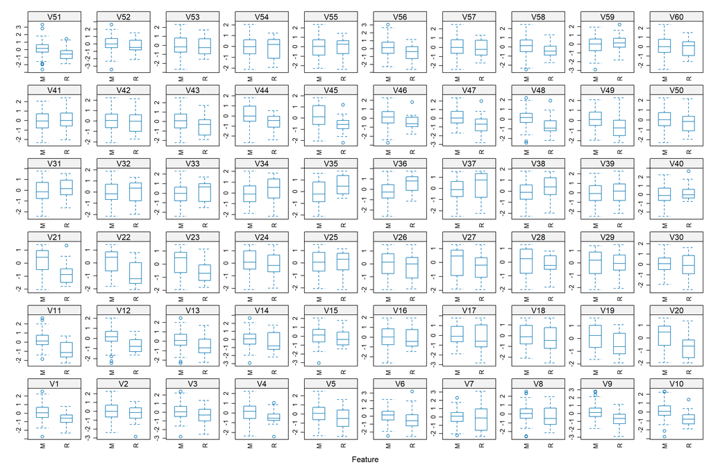

```r
##################################
# Formulating the box plots
##################################
featurePlot(x = EDA.Predictors.Numeric,
            y = EDA$Class,
            plot = "box",
            scales = list(x = list(relation="free", rot = 90),
                          y = list(relation="free")),
            adjust = 1.5,
            pch = "|")
```

## 1.5 Cost-Sensitive Learning Applied for Class Imbalance

### 1.5.1 Support Vector Machine - Radial Basis Function Kernel (SVM_R)

[Support Vector Machine](http://www.cs.cmu.edu/~pakyan/compbio/references/Drucker_NIPS_1996.pdf) plots each observation in an N-dimensional space corresponding to the number of features in the data set and finds a hyperplane that maximally separates the different classes by a maximally large margin (which is defined as the distance between the hyperplane and the closest data points from each class). The algorithm applies kernel transformation by mapping non-linearly separable data using the similarities between the points in a high-dimensional feature space for improved discrimination.  
**[A]** The support vector machine (radial basis function kernel) model from the **kernlab** package was implemented through the **caret** package. This version of the model applied uniform case weights between the classes of the response variable (Class=M:1, Class=R:1).  
**[B]** The model contains 2 hyperparameters:  
**[B.1]** sigma = sigma held constant at a value of 0.00873  
**[B.2]** C = cost made to vary across a range of 2^(-6) to 2^(1)  
**[C]** Specificity was particularly used as the metric for assessment to compare the effect of cost-sensitive learning to the minority class.  
**[D]** The cross-validated model performance of the final model is summarized as follows:  
**[D.1]** Final model configuration involves sigma=0.00873 and C=2.00000  
**[D.2]** Specificity = 0.60000  
**[E]** The model does not allow for ranking of predictors in terms of variable importance.  
**[F]** The independent test model performance of the final model is summarized as follows:  
**[F.1]** Specificity = 0.14286

**Code Chunk | Output**

```r
##################################
# Verifying the class distribution
# for the original data
##################################
table(PMA_PreModelling_Train$Class)
```

```
##
##  M  R
## 78 18
```

```r
##################################
# Creating a function for
# a customized summary metrics
##################################
fourMetricSummary <- function (data, lev = levels(data$obs), model = NULL)
{

  accKapp <- postResample(data[, "pred"], data[, "obs"])
  out <- c(accKapp,
           sensitivity(data[, "pred"], data[, "obs"], lev[1]),
           specificity(data[, "pred"], data[, "obs"], lev[2]))
  names(out)[3:4] <- c("Sensitivity", "Specificity")
  out
}

##################################
# Creating consistent fold assignments
# for the Repeated Cross Validation process
##################################
set.seed(12345678)
KFold_Control <- trainControl(method = "cv",
                                   classProbs = FALSE,
                                   summaryFunction = fourMetricSummary)

##################################
# Setting the conditions
# for hyperparameter tuning
##################################
##################################
# Pre-computing the sigma parameter
##################################
set.seed(12345678)
sigma <- sigest(Class~.,
                data=PMA_PreModelling_Train,
                frac=0.75)
names(sigma)=NULL
SVM_R_Grid <- data.frame(sigma=sigma[2], C=2^seq(-6,1,length=15))

##################################
# Running the support vector machine (radial basis function kernel) model
# by setting the caret method to 'svmRadial'
##################################
set.seed(12345678)
SVM_R_Tune <- train(x = PMA_PreModelling_Train[,!names(PMA_PreModelling_Train) %in% c("Class")],
                 y = PMA_PreModelling_Train$Class,
                 method = "svmRadial",
                 tuneGrid = SVM_R_Grid,
                 metric = "Specificity",
                 preProc = c("center", "scale"),
                 trControl = KFold_Control,
                 class.weights = c(M=1,R=1))

##################################
# Reporting the cross-validation results
# for the train set
##################################
SVM_R_Tune
```

```
## Support Vector Machines with Radial Basis Function Kernel
##
## 96 samples
## 60 predictors
##  2 classes: 'M', 'R'
##
## Pre-processing: centered (60), scaled (60)
## Resampling: Cross-Validated (10 fold)
## Summary of sample sizes: 86, 87, 86, 87, 87, 86, ...
## Resampling results across tuning parameters:
##
##   C           Accuracy   Kappa      Sensitivity  Specificity
##   0.01562500  0.8133333  0.0000000  1            0.0
##   0.02209709  0.8133333  0.0000000  1            0.0
##   0.03125000  0.8133333  0.0000000  1            0.0
##   0.04419417  0.8133333  0.0000000  1            0.0
##   0.06250000  0.8133333  0.0000000  1            0.0
##   0.08838835  0.8133333  0.0000000  1            0.0
##   0.12500000  0.8133333  0.0000000  1            0.0
##   0.17677670  0.8133333  0.0000000  1            0.0
##   0.25000000  0.8133333  0.0000000  1            0.0
##   0.35355339  0.8133333  0.0000000  1            0.0
##   0.50000000  0.8133333  0.0000000  1            0.0
##   0.70710678  0.8133333  0.0000000  1            0.0
##   1.00000000  0.8655556  0.3224080  1            0.3
##   1.41421356  0.9066667  0.5678930  1            0.5
##   2.00000000  0.9277778  0.6454849  1            0.6
##
## Tuning parameter 'sigma' was held constant at a value of 0.008732089
## Specificity was used to select the optimal model using the largest value.
## The final values used for the model were sigma = 0.008732089 and C = 2.
```

```r
SVM_R_Tune$finalModel
```

```
## Support Vector Machine object of class "ksvm"
##
## SV type: C-svc  (classification)
##  parameter : cost C = 2
##
## Gaussian Radial Basis kernel function.
##  Hyperparameter : sigma =  0.00873208894584695
##
## Number of Support Vectors : 57
##
## Objective Function Value : -33.2466
## Training error : 0.020833
```

```r
SVM_R_Tune$results
```

```
##          sigma          C  Accuracy     Kappa Sensitivity Specificity
## 1  0.008732089 0.01562500 0.8133333 0.0000000           1         0.0
## 2  0.008732089 0.02209709 0.8133333 0.0000000           1         0.0
## 3  0.008732089 0.03125000 0.8133333 0.0000000           1         0.0
## 4  0.008732089 0.04419417 0.8133333 0.0000000           1         0.0
## 5  0.008732089 0.06250000 0.8133333 0.0000000           1         0.0
## 6  0.008732089 0.08838835 0.8133333 0.0000000           1         0.0
## 7  0.008732089 0.12500000 0.8133333 0.0000000           1         0.0
## 8  0.008732089 0.17677670 0.8133333 0.0000000           1         0.0
## 9  0.008732089 0.25000000 0.8133333 0.0000000           1         0.0
## 10 0.008732089 0.35355339 0.8133333 0.0000000           1         0.0
## 11 0.008732089 0.50000000 0.8133333 0.0000000           1         0.0
## 12 0.008732089 0.70710678 0.8133333 0.0000000           1         0.0
## 13 0.008732089 1.00000000 0.8655556 0.3224080           1         0.3
## 14 0.008732089 1.41421356 0.9066667 0.5678930           1         0.5
```

[output cut: 17 more lines]

```r
(SVM_R_Train_Specificity <- SVM_R_Tune$results[SVM_R_Tune$results$C==SVM_R_Tune$bestTune$C,
                              c("Specificity")])
```

```
## [1] 0.6
```

```r
SVM_R_Train <- data.frame(SVM_R_Observed = PMA_PreModelling_Train$Class,
                      SVM_R_Predicted = predict(SVM_R_Tune,
                      PMA_PreModelling_Train[,!names(PMA_PreModelling_Train) %in% c("Class")],
                      type = "raw"))

(SVM_R_Train_ConfusionMatrix <- confusionMatrix(data = SVM_R_Train$SVM_R_Predicted,
                                                  reference = SVM_R_Train$SVM_R_Observed))
```

```
## Confusion Matrix and Statistics
##
##           Reference
## Prediction  M  R
##          M 78  2
##          R  0 16
##
##                Accuracy : 0.9792
##                  95% CI : (0.9268, 0.9975)
##     No Information Rate : 0.8125
##     P-Value [Acc > NIR] : 5.86e-07
##
##                   Kappa : 0.9286
##
##  Mcnemar's Test P-Value : 0.4795
##
##             Sensitivity : 1.0000
##             Specificity : 0.8889
##          Pos Pred Value : 0.9750
##          Neg Pred Value : 1.0000
##              Prevalence : 0.8125
##          Detection Rate : 0.8125
##    Detection Prevalence : 0.8333
##       Balanced Accuracy : 0.9444
##
##        'Positive' Class : M
##
```

```r
##################################
# Identifying and plotting the
# best model predictors
##################################
# model does not support variable importance measurement

##################################
# Independently evaluating the model
# on the test set
##################################
SVM_R_Test <- data.frame(SVM_R_Observed = PMA_PreModelling_Test$Class,
                      SVM_R_Predicted = predict(SVM_R_Tune,
                      PMA_PreModelling_Test[,!names(PMA_PreModelling_Test) %in% c("Class")],
                      type = "raw"))

SVM_R_Test
```

```
##    SVM_R_Observed SVM_R_Predicted
## 1               M               M
## 2               M               M
## 3               M               M
## 4               M               M
## 5               M               M
## 6               M               M
## 7               M               M
## 8               M               M
## 9               M               M
## 10              M               M
## 11              M               M
## 12              M               M
## 13              M               M
## 14              M               M
```

[output cut: 26 more lines]

```r
##################################
# Reporting the independent evaluation results
# for the test set
##################################
(SVM_R_Test_Specificity <- Specificity(y_pred = SVM_R_Test$SVM_R_Predicted,
                                       y_true = SVM_R_Test$SVM_R_Observed))
```

```
## [1] 0.1428571
```

```r
(SVM_R_Test_ConfusionMatrix <- confusionMatrix(data = SVM_R_Test$SVM_R_Predicted,
                                               reference = SVM_R_Test$SVM_R_Observed))
```

```
## Confusion Matrix and Statistics
##
##           Reference
## Prediction  M  R
##          M 32  6
##          R  1  1
##
##                Accuracy : 0.825
##                  95% CI : (0.6722, 0.9266)
##     No Information Rate : 0.825
##     P-Value [Acc > NIR] : 0.5992
##
##                   Kappa : 0.1566
##
##  Mcnemar's Test P-Value : 0.1306
##
##             Sensitivity : 0.9697
##             Specificity : 0.1429
##          Pos Pred Value : 0.8421
##          Neg Pred Value : 0.5000
##              Prevalence : 0.8250
##          Detection Rate : 0.8000
##    Detection Prevalence : 0.9500
##       Balanced Accuracy : 0.5563
##
##        'Positive' Class : M
##
```

### 1.5.2 Class-Weighted Support Vector Machine - Radial Basis Function Kernel (CW_SVM_R)

**Code Chunk | Output**

```r
##################################
# Verifying the class distribution
# for the original data
##################################
table(PMA_PreModelling_Train$Class)
```

```
##
##  M  R
## 78 18
```

```r
##################################
# Creating a function for
# a customized summary metrics
##################################
fourMetricSummary <- function (data, lev = levels(data$obs), model = NULL)
{

  accKapp <- postResample(data[, "pred"], data[, "obs"])
  out <- c(accKapp,
           sensitivity(data[, "pred"], data[, "obs"], lev[1]),
           specificity(data[, "pred"], data[, "obs"], lev[2]))
  names(out)[3:4] <- c("Sensitivity", "Specificity")
  out
}

##################################
# Creating consistent fold assignments
# for the Repeated Cross Validation process
##################################
set.seed(12345678)
KFold_Control <- trainControl(method = "cv",
                                   classProbs = FALSE,
                                   summaryFunction = fourMetricSummary)

##################################
# Setting the conditions
# for hyperparameter tuning
##################################
##################################
# Pre-computing the sigma parameter
##################################
set.seed(12345678)
sigma <- sigest(Class~.,
                data=PMA_PreModelling_Train,
                frac=0.75)
names(sigma)=NULL
CW_SVM_R_Grid <- data.frame(sigma=sigma[2], C=2^seq(-6,1,length=15))

##################################
# Running the support vector machine (radial basis function kernel) model
# by setting the caret method to 'svmRadial'
##################################
set.seed(12345678)
CW_SVM_R_Tune <- train(x = PMA_PreModelling_Train[,!names(PMA_PreModelling_Train) %in% c("Class")],
                 y = PMA_PreModelling_Train$Class,
                 method = "svmRadial",
                 tuneGrid = CW_SVM_R_Grid,
                 metric = "Specificity",
                 preProc = c("center", "scale"),
                 trControl = KFold_Control,
                 class.weights = c(M=1,R=4))

##################################
# Reporting the cross-validation results
# for the train set
##################################
CW_SVM_R_Tune
```

```
## Support Vector Machines with Radial Basis Function Kernel
##
## 96 samples
## 60 predictors
##  2 classes: 'M', 'R'
##
## Pre-processing: centered (60), scaled (60)
## Resampling: Cross-Validated (10 fold)
## Summary of sample sizes: 86, 87, 86, 87, 87, 86, ...
## Resampling results across tuning parameters:
##
##   C           Accuracy   Kappa      Sensitivity  Specificity
##   0.01562500  0.8133333  0.0000000  1.0000000    0.00
##   0.02209709  0.8133333  0.0000000  1.0000000    0.00
##   0.03125000  0.8133333  0.0000000  1.0000000    0.00
##   0.04419417  0.8133333  0.0000000  1.0000000    0.00
##   0.06250000  0.8133333  0.0000000  1.0000000    0.00
##   0.08838835  0.8444444  0.2230769  1.0000000    0.20
##   0.12500000  0.8633333  0.4848567  0.9357143    0.55
##   0.17677670  0.8422222  0.4554315  0.8964286    0.60
##   0.25000000  0.8322222  0.4389841  0.8839286    0.60
##   0.35355339  0.8633333  0.5094884  0.9089286    0.65
##   0.50000000  0.8844444  0.5566738  0.9339286    0.65
##   0.70710678  0.8944444  0.5758125  0.9464286    0.65
##   1.00000000  0.9166667  0.6324754  0.9732143    0.65
##   1.41421356  0.9066667  0.5940139  0.9732143    0.60
##   2.00000000  0.9066667  0.5940139  0.9732143    0.60
##
## Tuning parameter 'sigma' was held constant at a value of 0.008732089
## Specificity was used to select the optimal model using the largest value.
## The final values used for the model were sigma = 0.008732089 and C = 0.3535534.
```

```r
CW_SVM_R_Tune$finalModel
```

```
## Support Vector Machine object of class "ksvm"
##
## SV type: C-svc  (classification)
##  parameter : cost C = 0.353553390593274
##
## Gaussian Radial Basis kernel function.
##  Hyperparameter : sigma =  0.00873208894584695
##
## Number of Support Vectors : 78
##
## Objective Function Value : -25.2282
## Training error : 0.020833
```

```r
CW_SVM_R_Tune$results
```

```
##          sigma          C  Accuracy     Kappa Sensitivity Specificity
## 1  0.008732089 0.01562500 0.8133333 0.0000000   1.0000000        0.00
## 2  0.008732089 0.02209709 0.8133333 0.0000000   1.0000000        0.00
## 3  0.008732089 0.03125000 0.8133333 0.0000000   1.0000000        0.00
## 4  0.008732089 0.04419417 0.8133333 0.0000000   1.0000000        0.00
## 5  0.008732089 0.06250000 0.8133333 0.0000000   1.0000000        0.00
## 6  0.008732089 0.08838835 0.8444444 0.2230769   1.0000000        0.20
## 7  0.008732089 0.12500000 0.8633333 0.4848567   0.9357143        0.55
## 8  0.008732089 0.17677670 0.8422222 0.4554315   0.8964286        0.60
## 9  0.008732089 0.25000000 0.8322222 0.4389841   0.8839286        0.60
## 10 0.008732089 0.35355339 0.8633333 0.5094884   0.9089286        0.65
## 11 0.008732089 0.50000000 0.8844444 0.5566738   0.9339286        0.65
## 12 0.008732089 0.70710678 0.8944444 0.5758125   0.9464286        0.65
## 13 0.008732089 1.00000000 0.9166667 0.6324754   0.9732143        0.65
## 14 0.008732089 1.41421356 0.9066667 0.5940139   0.9732143        0.60
```

[output cut: 17 more lines]

```r
(CW_SVM_R_Train_Specificity <- CW_SVM_R_Tune$results[CW_SVM_R_Tune$results$C==CW_SVM_R_Tune$bestTune$C,
                              c("Specificity")])
```

```
## [1] 0.65
```

```r
CW_SVM_R_Train <- data.frame(CW_SVM_R_Observed = PMA_PreModelling_Train$Class,
                      CW_SVM_R_Predicted = predict(CW_SVM_R_Tune,
                      PMA_PreModelling_Train[,!names(PMA_PreModelling_Train) %in% c("Class")],
                      type = "raw"))

(CW_SVM_R_Train_ConfusionMatrix <- confusionMatrix(data = CW_SVM_R_Train$CW_SVM_R_Predicted,
                                                  reference = CW_SVM_R_Train$CW_SVM_R_Observed))
```

```
## Confusion Matrix and Statistics
##
##           Reference
## Prediction  M  R
##          M 77  1
##          R  1 17
##
##                Accuracy : 0.9792
##                  95% CI : (0.9268, 0.9975)
##     No Information Rate : 0.8125
##     P-Value [Acc > NIR] : 5.86e-07
##
##                   Kappa : 0.9316
##
##  Mcnemar's Test P-Value : 1
##
##             Sensitivity : 0.9872
##             Specificity : 0.9444
##          Pos Pred Value : 0.9872
##          Neg Pred Value : 0.9444
##              Prevalence : 0.8125
##          Detection Rate : 0.8021
##    Detection Prevalence : 0.8125
##       Balanced Accuracy : 0.9658
##
##        'Positive' Class : M
##
```

```r
##################################
# Identifying and plotting the
# best model predictors
##################################
# model does not support variable importance measurement

##################################
# Independently evaluating the model
# on the test set
##################################
CW_SVM_R_Test <- data.frame(CW_SVM_R_Observed = PMA_PreModelling_Test$Class,
                      CW_SVM_R_Predicted = predict(CW_SVM_R_Tune,
                      PMA_PreModelling_Test[,!names(PMA_PreModelling_Test) %in% c("Class")],
                      type = "raw"))

CW_SVM_R_Test
```

```
##    CW_SVM_R_Observed CW_SVM_R_Predicted
## 1                  M                  M
## 2                  M                  M
## 3                  M                  R
## 4                  M                  M
## 5                  M                  R
## 6                  M                  M
## 7                  M                  M
## 8                  M                  M
## 9                  M                  M
## 10                 M                  M
## 11                 M                  M
## 12                 M                  M
## 13                 M                  M
## 14                 M                  M
```

[output cut: 26 more lines]

```r
##################################
# Reporting the independent evaluation results
# for the test set
##################################
(CW_SVM_R_Test_Specificity <- Specificity(y_pred = CW_SVM_R_Test$CW_SVM_R_Predicted,
                                          y_true = CW_SVM_R_Test$CW_SVM_R_Observed))
```

```
## [1] 0.2857143
```

```r
(CW_SVM_R_Test_ConfusionMatrix <- confusionMatrix(data = CW_SVM_R_Test$CW_SVM_R_Predicted,
                                                 reference = CW_SVM_R_Test$CW_SVM_R_Observed))
```

```
## Confusion Matrix and Statistics
##
##           Reference
## Prediction  M  R
##          M 30  5
##          R  3  2
##
##                Accuracy : 0.8
##                  95% CI : (0.6435, 0.9095)
##     No Information Rate : 0.825
##     P-Value [Acc > NIR] : 0.7427
##
##                   Kappa : 0.2195
##
##  Mcnemar's Test P-Value : 0.7237
##
##             Sensitivity : 0.9091
##             Specificity : 0.2857
##          Pos Pred Value : 0.8571
##          Neg Pred Value : 0.4000
##              Prevalence : 0.8250
##          Detection Rate : 0.7500
##    Detection Prevalence : 0.8750
##       Balanced Accuracy : 0.5974
##
##        'Positive' Class : M
##
```

### 1.5.3 Classification and Regression Trees (CART)

[Classification and Regression Trees](https://www.semanticscholar.org/paper/Classification-and-Regression-Trees-Breiman-Friedman/8017699564136f93af21575810d557dba1ee6fc6) construct binary trees for both both nominal and continuous input attributes using Gini Index as its splitting criteria. The algorithm handles missing values by surrogating tests to approximate outcomes. In the pruning phase, CART uses pre-pruning technique called Cost-Complexity pruning to remove redundant branches from the decision tree to improve the accuracy. In the first stage, a sequence of increasingly smaller trees are built on the training data. In the second stage, one of these tree is chosen as the pruned tree, based on its classification accuracy on a pruning set, adopting a cross-validated method in its pruning technique.  
**[A]** The classification and regression trees model from the **rpart** package was implemented through the **caret** package. This version of the model applied uniform case weights between the classes of the response variable (Class=M:1, Class=R:1).  
**[B]** The model contains 1 hyperparameter:  
**[B.1]** cp = complexity parameter threshold made to vary across a range of values equal to 0.0001 to 0.0200  
**[C]** Specificity was particularly used as the metric for assessment to compare the effect of cost-sensitive learning to the minority class.  
**[D]** The cross-validated model performance of the final model is summarized as follows:  
**[D.1]** Final model configuration involves cp=0.0200  
**[D.2]** Specificity = 0.45000  
**[E]** The model allows for ranking of predictors in terms of variable importance. The top-performing predictors in the model are as follows:  
**[E.1]** V49 variable (numeric)  
**[E.2]** V11 variable (numeric)  
**[E.3]** V21 variable (numeric)  
**[E.4]** V22 variable (numeric)  
**[E.5]** V10 variable (numeric)  
**[F]** The independent test model performance of the final model is summarized as follows:  
**[F.1]** Specificity = 0.28571

**Code Chunk | Output**

```r
##################################
# Verifying the class distribution
# for the original data
##################################
table(PMA_PreModelling_Train$Class)
```

```
##
##  M  R
## 78 18
```

```r
##################################
# Creating a function for
# a customized summary metrics
##################################
fourMetricSummary <- function (data, lev = levels(data$obs), model = NULL)
{

  accKapp <- postResample(data[, "pred"], data[, "obs"])
  out <- c(accKapp,
           sensitivity(data[, "pred"], data[, "obs"], lev[1]),
           specificity(data[, "pred"], data[, "obs"], lev[2]))
  names(out)[3:4] <- c("Sensitivity", "Specificity")
  out
}

##################################
# Creating consistent fold assignments
# for the Repeated Cross Validation process
##################################
set.seed(12345678)
KFold_Control <- trainControl(method = "cv",
                                   classProbs = FALSE,
                                   summaryFunction = fourMetricSummary)

##################################
# Setting the conditions
# for hyperparameter tuning
##################################
CART_Grid = data.frame(cp = c(0.0001, 0.0005, 0.001, 0.005, 0.010, 0.015, 0.020))

##################################
# Formulating the cost matrix
##################################
CART_CostMatrix <- matrix(c(0,1,1,0), ncol=2)
rownames(CART_CostMatrix) <- levels(PMA_PreModelling_Train$Class)
colnames(CART_CostMatrix) <- levels(PMA_PreModelling_Train$Class)
CART_CostMatrix
```

```
##   M R
## M 0 1
## R 1 0
```

```r
##################################
# Running the classification and regression trees model
# by setting the caret method to 'rpart'
##################################
set.seed(12345678)
CART_Tune <- train(x = PMA_PreModelling_Train[,!names(PMA_PreModelling_Train) %in% c("Class")],
                 y = PMA_PreModelling_Train$Class,
                 method = "rpart",
                 tuneGrid = CART_Grid,
                 metric = "Specificity",
                 trControl = KFold_Control,
                 parms = list(loss=CART_CostMatrix))

##################################
# Reporting the cross-validation results
# for the train set
##################################
CART_Tune
```

```
## CART
##
## 96 samples
## 60 predictors
##  2 classes: 'M', 'R'
##
## No pre-processing
## Resampling: Cross-Validated (10 fold)
## Summary of sample sizes: 86, 87, 86, 87, 87, 86, ...
## Resampling results across tuning parameters:
##
##   cp      Accuracy   Kappa      Sensitivity  Specificity
##   0.0001  0.7922222  0.2829196  0.8714286    0.45
##   0.0005  0.7922222  0.2829196  0.8714286    0.45
##   0.0010  0.7922222  0.2829196  0.8714286    0.45
##   0.0050  0.7922222  0.2829196  0.8714286    0.45
##   0.0100  0.7922222  0.2829196  0.8714286    0.45
##   0.0150  0.7922222  0.2829196  0.8714286    0.45
##   0.0200  0.7922222  0.2829196  0.8714286    0.45
##
## Specificity was used to select the optimal model using the largest value.
## The final value used for the model was cp = 0.02.
```

```r
CART_Tune$finalModel
```

```
## n= 96
##
## node), split, n, loss, yval, (yprob)
##       * denotes terminal node
##
## 1) root 96 18 M (0.81250000 0.18750000)
##   2) V11>=-1.453302 87 10 M (0.88505747 0.11494253)
##     4) V49>=-1.421354 79  5 M (0.93670886 0.06329114) *
##     5) V49< -1.421354 8  3 R (0.37500000 0.62500000) *
##   3) V11< -1.453302 9  1 R (0.11111111 0.88888889) *
```

```r
CART_Tune$results
```

```
##       cp  Accuracy     Kappa Sensitivity Specificity AccuracySD   KappaSD
## 1 0.0001 0.7922222 0.2829196   0.8714286        0.45  0.1193317 0.4149074
## 2 0.0005 0.7922222 0.2829196   0.8714286        0.45  0.1193317 0.4149074
## 3 0.0010 0.7922222 0.2829196   0.8714286        0.45  0.1193317 0.4149074
## 4 0.0050 0.7922222 0.2829196   0.8714286        0.45  0.1193317 0.4149074
## 5 0.0100 0.7922222 0.2829196   0.8714286        0.45  0.1193317 0.4149074
## 6 0.0150 0.7922222 0.2829196   0.8714286        0.45  0.1193317 0.4149074
## 7 0.0200 0.7922222 0.2829196   0.8714286        0.45  0.1193317 0.4149074
##   SensitivitySD SpecificitySD
## 1     0.1225092     0.4377975
## 2     0.1225092     0.4377975
## 3     0.1225092     0.4377975
## 4     0.1225092     0.4377975
## 5     0.1225092     0.4377975
## 6     0.1225092     0.4377975
## 7     0.1225092     0.4377975
```

```r
(CART_Train_Specificity <- CART_Tune$results[CART_Tune$results$cp==CART_Tune$bestTune$cp,
                              c("Specificity")])
```

```
## [1] 0.45
```

```r
CART_Train <- data.frame(CART_Observed = PMA_PreModelling_Train$Class,
                      CART_Predicted = predict(CART_Tune,
                      PMA_PreModelling_Train[,!names(PMA_PreModelling_Train) %in% c("Class")],
                      type = "raw"))

(CART_Train_ConfusionMatrix <- confusionMatrix(data = CART_Train$CART_Predicted,
                                                  reference = CART_Train$CART_Observed))
```

```
## Confusion Matrix and Statistics
##
##           Reference
## Prediction  M  R
##          M 74  5
##          R  4 13
##
##                Accuracy : 0.9062
##                  95% CI : (0.8295, 0.9562)
##     No Information Rate : 0.8125
##     P-Value [Acc > NIR] : 0.008989
##
##                   Kappa : 0.6856
##
##  Mcnemar's Test P-Value : 1.000000
##
##             Sensitivity : 0.9487
##             Specificity : 0.7222
##          Pos Pred Value : 0.9367
##          Neg Pred Value : 0.7647
##              Prevalence : 0.8125
##          Detection Rate : 0.7708
##    Detection Prevalence : 0.8229
##       Balanced Accuracy : 0.8355
##
##        'Positive' Class : M
##
```

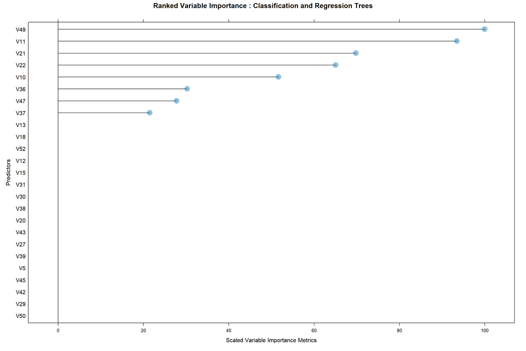

```r
##################################
# Identifying and plotting the
# best model predictors
##################################
CART_VarImp <- varImp(CART_Tune, scale = TRUE)
plot(CART_VarImp,
     top=25,
     scales=list(y=list(cex = .95)),
     main="Ranked Variable Importance : Classification and Regression Trees",
     xlab="Scaled Variable Importance Metrics",
     ylab="Predictors",
     cex=2,
     origin=0,
     alpha=0.45)
```

```r
##################################
# Independently evaluating the model
# on the test set
##################################
CART_Test <- data.frame(CART_Observed = PMA_PreModelling_Test$Class,
                      CART_Predicted = predict(CART_Tune,
                      PMA_PreModelling_Test[,!names(PMA_PreModelling_Test) %in% c("Class")],
                      type = "raw"))

CART_Test
```

```
##    CART_Observed CART_Predicted
## 1              M              M
## 2              M              M
## 3              M              M
## 4              M              M
## 5              M              M
## 6              M              M
## 7              M              R
## 8              M              R
## 9              M              M
## 10             M              M
## 11             M              M
## 12             M              M
## 13             M              M
## 14             M              M
```

[output cut: 26 more lines]

```r
##################################
# Reporting the independent evaluation results
# for the test set
##################################
(CART_Test_Specificity <- Specificity(y_pred = CART_Test$CART_Predicted,
                                       y_true = CART_Test$CART_Observed))
```

```
## [1] 0.2857143
```

```r
(CART_Test_ConfusionMatrix <- confusionMatrix(data = CART_Test$CART_Predicted,
                                               reference = CART_Test$CART_Observed))
```

```
## Confusion Matrix and Statistics
##
##           Reference
## Prediction  M  R
##          M 28  5
##          R  5  2
##
##                Accuracy : 0.75
##                  95% CI : (0.588, 0.8731)
##     No Information Rate : 0.825
##     P-Value [Acc > NIR] : 0.922
##
##                   Kappa : 0.1342
##
##  Mcnemar's Test P-Value : 1.000
##
##             Sensitivity : 0.8485
##             Specificity : 0.2857
##          Pos Pred Value : 0.8485
##          Neg Pred Value : 0.2857
##              Prevalence : 0.8250
##          Detection Rate : 0.7000
##    Detection Prevalence : 0.8250
##       Balanced Accuracy : 0.5671
##
##        'Positive' Class : M
##
```

### 1.5.4 Cost-Sensitive Classification and Regression Trees (CS_CART)

[Classification and Regression Trees](https://www.semanticscholar.org/paper/Classification-and-Regression-Trees-Breiman-Friedman/8017699564136f93af21575810d557dba1ee6fc6) construct binary trees for both both nominal and continuous input attributes using Gini Index as its splitting criteria. The algorithm handles missing values by surrogating tests to approximate outcomes. In the pruning phase, CART uses pre-pruning technique called Cost-Complexity pruning to remove redundant branches from the decision tree to improve the accuracy. In the first stage, a sequence of increasingly smaller trees are built on the training data. In the second stage, one of these tree is chosen as the pruned tree, based on its classification accuracy on a pruning set, adopting a cross-validated method in its pruning technique.  
[Cost-Sensitive Learning](https://link.springer.com/referencework/10.1007/978-0-387-30164-8) assigns different costs to the types of misclassification errors that can be made, then applies specialized methods to take those costs into account. Given a penalty associated with an incorrect prediction which is referred to as the cost, the algorithm aims to minimize the cost of a model on the training data set, where it is assumed that different types of prediction errors have a different and known associated cost. The varying misclassification costs are best understood using the idea of a cost matrix.  
**[A]** The classification and regression trees model from the **rpart** package was implemented through the **caret** package. This version of the model applied non-uniform case weights between the classes of the response variable (Class=M:1, Class=R:4).  
**[B]** The model contains 1 hyperparameter:  
**[B.1]** cp = complexity parameter threshold made to vary across a range of values equal to 0.0001 to 0.0200  
**[C]** Specificity was particularly used as the metric for assessment to compare the effect of cost-sensitive learning to the minority class.  
**[D]** The cross-validated model performance of the final model is summarized as follows:  
**[D.1]** Final model configuration involves cp=0.0200  
**[D.2]** Specificity = 0.30000  
**[E]** The model allows for ranking of predictors in terms of variable importance. The top-performing predictors in the model are as follows:  
**[E.1]** V21 variable (numeric)  
**[E.2]** V11 variable (numeric)  
**[E.3]** V10 variable (numeric)  
**[E.4]** V35 variable (numeric)  
**[E.5]** V48 variable (numeric)  
**[F]** The independent test model performance of the final model is summarized as follows:  
**[F.1]** Specificity = 0.71428

**Code Chunk | Output**

```r
##################################
# Verifying the class distribution
# for the original data
##################################
table(PMA_PreModelling_Train$Class)
```

```
##
##  M  R
## 78 18
```

```r
##################################
# Creating a function for
# a customized summary metrics
##################################
fourMetricSummary <- function (data, lev = levels(data$obs), model = NULL)
{

  accKapp <- postResample(data[, "pred"], data[, "obs"])
  out <- c(accKapp,
           sensitivity(data[, "pred"], data[, "obs"], lev[1]),
           specificity(data[, "pred"], data[, "obs"], lev[2]))
  names(out)[3:4] <- c("Sensitivity", "Specificity")
  out
}

##################################
# Creating consistent fold assignments
# for the Repeated Cross Validation process
##################################
set.seed(12345678)
KFold_Control <- trainControl(method = "cv",
                                   classProbs = FALSE,
                                   summaryFunction = fourMetricSummary)

##################################
# Setting the conditions
# for hyperparameter tuning
##################################
CS_CART_Grid = data.frame(cp = c(0.0001, 0.0005, 0.0010, 0.0050, 0.0100, 0.0150, 0.0200))

##################################
# Formulating the cost matrix
##################################
CS_CART_CostMatrix <- matrix(c(0,4,1,0), ncol=2)
rownames(CS_CART_CostMatrix) <- levels(PMA_PreModelling_Train$Class)
colnames(CS_CART_CostMatrix) <- levels(PMA_PreModelling_Train$Class)
CS_CART_CostMatrix
```

```
##   M R
## M 0 1
## R 4 0
```

```r
##################################
# Running the classification and regression trees model
# by setting the caret method to 'rpart'
##################################
set.seed(12345678)
CS_CART_Tune <- train(x = PMA_PreModelling_Train[,!names(PMA_PreModelling_Train) %in% c("Class")],
                 y = PMA_PreModelling_Train$Class,
                 method = "rpart",
                 tuneGrid = CS_CART_Grid,
                 metric = "Specificity",
                 trControl = KFold_Control,
                 parms = list(loss=CS_CART_CostMatrix))

##################################
# Reporting the cross-validation results
# for the train set
##################################
CS_CART_Tune
```

```
## CART
##
## 96 samples
## 60 predictors
##  2 classes: 'M', 'R'
##
## No pre-processing
## Resampling: Cross-Validated (10 fold)
## Summary of sample sizes: 86, 87, 86, 87, 87, 86, ...
## Resampling results across tuning parameters:
##
##   cp      Accuracy  Kappa     Sensitivity  Specificity
##   0.0001  0.76      0.169608  0.8535714    0.3
##   0.0005  0.76      0.169608  0.8535714    0.3
##   0.0010  0.76      0.169608  0.8535714    0.3
##   0.0050  0.76      0.169608  0.8535714    0.3
##   0.0100  0.76      0.169608  0.8535714    0.3
##   0.0150  0.76      0.169608  0.8535714    0.3
##   0.0200  0.76      0.169608  0.8535714    0.3
##
## Specificity was used to select the optimal model using the largest value.
## The final value used for the model was cp = 0.02.
```

```r
CS_CART_Tune$finalModel
```

```
## n= 96
##
## node), split, n, loss, yval, (yprob)
##       * denotes terminal node
##
## 1) root 96 72 M (0.81250000 0.18750000)
##   2) V11>=-0.92108 78 28 M (0.91025641 0.08974359)
##     4) V49>=-1.421354 71 12 M (0.95774648 0.04225352) *
##     5) V49< -1.421354 7  3 R (0.42857143 0.57142857) *
##   3) V11< -0.92108 18  7 R (0.38888889 0.61111111) *
```

```r
CS_CART_Tune$results
```

```
##       cp Accuracy    Kappa Sensitivity Specificity AccuracySD   KappaSD
## 1 0.0001     0.76 0.169608   0.8535714         0.3  0.1607766 0.3396056
## 2 0.0005     0.76 0.169608   0.8535714         0.3  0.1607766 0.3396056
## 3 0.0010     0.76 0.169608   0.8535714         0.3  0.1607766 0.3396056
## 4 0.0050     0.76 0.169608   0.8535714         0.3  0.1607766 0.3396056
## 5 0.0100     0.76 0.169608   0.8535714         0.3  0.1607766 0.3396056
## 6 0.0150     0.76 0.169608   0.8535714         0.3  0.1607766 0.3396056
## 7 0.0200     0.76 0.169608   0.8535714         0.3  0.1607766 0.3396056
##   SensitivitySD SpecificitySD
## 1     0.1921061     0.3496029
## 2     0.1921061     0.3496029
## 3     0.1921061     0.3496029
## 4     0.1921061     0.3496029
## 5     0.1921061     0.3496029
## 6     0.1921061     0.3496029
## 7     0.1921061     0.3496029
```

```r
(CS_CART_Train_Specificity <- CS_CART_Tune$results[CS_CART_Tune$results$cp==CS_CART_Tune$bestTune$cp,
                              c("Specificity")])
```

```
## [1] 0.3
```

```r
CS_CART_Train <- data.frame(CS_CART_Observed = PMA_PreModelling_Train$Class,
                      CS_CART_Predicted = predict(CS_CART_Tune,
                      PMA_PreModelling_Train[,!names(PMA_PreModelling_Train) %in% c("Class")],
                      type = "raw"))

(CS_CART_Train_ConfusionMatrix <- confusionMatrix(data = CS_CART_Train$CS_CART_Predicted,
                                                  reference = CS_CART_Train$CS_CART_Observed))
```

```
## Confusion Matrix and Statistics
##
##           Reference
## Prediction  M  R
##          M 68  3
##          R 10 15
##
##                Accuracy : 0.8646
##                  95% CI : (0.7796, 0.9259)
##     No Information Rate : 0.8125
##     P-Value [Acc > NIR] : 0.11704
##
##                   Kappa : 0.6134
##
##  Mcnemar's Test P-Value : 0.09609
##
##             Sensitivity : 0.8718
##             Specificity : 0.8333
##          Pos Pred Value : 0.9577
##          Neg Pred Value : 0.6000
##              Prevalence : 0.8125
##          Detection Rate : 0.7083
##    Detection Prevalence : 0.7396
##       Balanced Accuracy : 0.8526
##
##        'Positive' Class : M
##
```

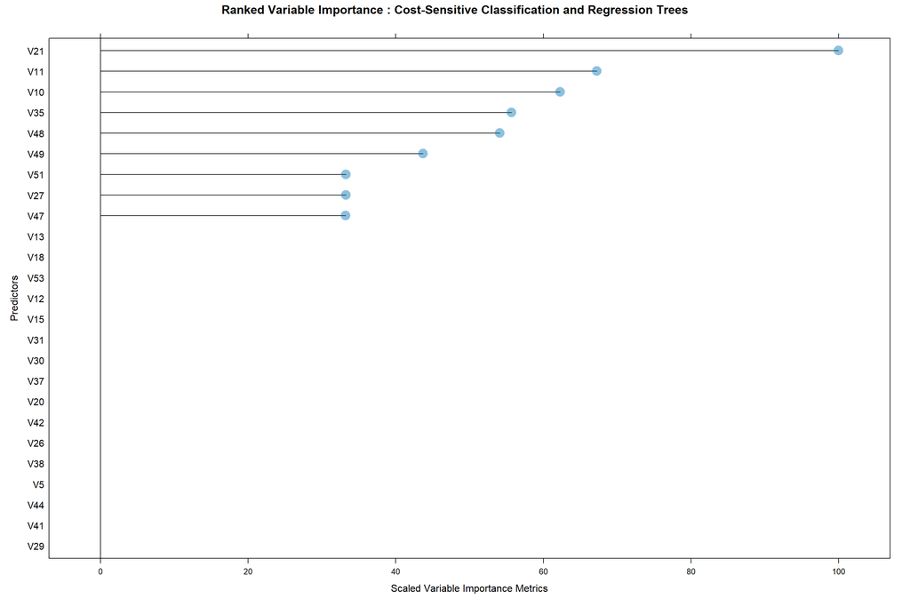

```r
##################################
# Identifying and plotting the
# best model predictors
##################################
CS_CART_VarImp <- varImp(CS_CART_Tune, scale = TRUE)
plot(CS_CART_VarImp,
     top=25,
     scales=list(y=list(cex = .95)),
     main="Ranked Variable Importance : Cost-Sensitive Classification and Regression Trees",
     xlab="Scaled Variable Importance Metrics",
     ylab="Predictors",
     cex=2,
     origin=0,
     alpha=0.45)
```

```r
##################################
# Independently evaluating the model
# on the test set
##################################
CS_CART_Test <- data.frame(CS_CART_Observed = PMA_PreModelling_Test$Class,
                      CS_CART_Predicted = predict(CS_CART_Tune,
                      PMA_PreModelling_Test[,!names(PMA_PreModelling_Test) %in% c("Class")],
                      type = "raw"))

CS_CART_Test
```

```
##    CS_CART_Observed CS_CART_Predicted
## 1                 M                 R
## 2                 M                 M
## 3                 M                 M
## 4                 M                 M
## 5                 M                 M
## 6                 M                 M
## 7                 M                 R
## 8                 M                 R
## 9                 M                 R
## 10                M                 M
## 11                M                 M
## 12                M                 M
## 13                M                 M
## 14                M                 M
```

[output cut: 26 more lines]

```r
##################################
# Reporting the independent evaluation results
# for the test set
##################################
(CS_CART_Test_Specificity <- Specificity(y_pred = CS_CART_Test$CS_CART_Predicted,
                                       y_true = CS_CART_Test$CS_CART_Observed))
```

```
## [1] 0.7142857
```

```r
(CS_CART_Test_ConfusionMatrix <- confusionMatrix(data = CS_CART_Test$CS_CART_Predicted,
                                               reference = CS_CART_Test$CS_CART_Observed))
```

```
## Confusion Matrix and Statistics
##
##           Reference
## Prediction  M  R
##          M 26  2
##          R  7  5
##
##                Accuracy : 0.775
##                  95% CI : (0.6155, 0.8916)
##     No Information Rate : 0.825
##     P-Value [Acc > NIR] : 0.8509
##
##                   Kappa : 0.3919
##
##  Mcnemar's Test P-Value : 0.1824
##
##             Sensitivity : 0.7879
##             Specificity : 0.7143
##          Pos Pred Value : 0.9286
##          Neg Pred Value : 0.4167
##              Prevalence : 0.8250
##          Detection Rate : 0.6500
##    Detection Prevalence : 0.7000
##       Balanced Accuracy : 0.7511
##
##        'Positive' Class : M
##
```

### 1.5.5 C5.0 Decision Trees (C50)

[C5.0 Decision Trees](https://link.springer.com/article/10.1007/BF00993309) generate multi-branch trees in a situation where one or more nominal inputs are given, using an information-based criterion (Entropy and Information Gain) as an attribute selection measure to build decision trees. For overfitting avoidance, the algorithm applies a pessimistic pruning approach called Rule-post pruning, to remove unreliable branches from the decision tree to reduce the size of the tree without any loss of its predictive accuracy. The Rule-post pruning starts off by converting a decision tree to an equivalent set of rules, then based on statistical confidence estimations for error rate it evaluates the rules with the aim of simplifying them without affecting the accuracy, adopting the Binomial Confidence Limit method. In a case of handling missing values, the algorithm allows to whether estimate missing values as a function of other attributes or apportions the case probabilistically among the results.  
**[A]** The C5.0 decision trees model from the **C50** and **plyr** packages was implemented through the **caret** package. This version of the model applied uniform case weights between the classes of the response variable (Class=M:1, Class=R:1).  
**[B]** The model contains 3 hyperparameters:  
**[B.1]** trials = number of boosting iterations made to vary across a range of values equal to 1 to 100  
**[B.2]** model = model type made to vary across a range of levels equal to TREE and RULES  
**[B.3]** winnow = winnow made to vary across a range of levels equal to TRUE and FALSE  
**[C]** Specificity was particularly used as the metric for assessment to compare the effect of cost-sensitive learning to the minority class.  
**[D]** The cross-validated model performance of the final model is summarized as follows:  
**[D.1]** Final model configuration involves trials=1, model=TREE and winnow=FALSE  
**[D.2]** Specificity = 0.55000  
**[E]** The model allows for ranking of predictors in terms of variable importance. The top-performing predictors in the model are as follows:  
**[E.1]** V11 variable (numeric)  
**[E.2]** V49 variable (numeric)  
**[E.3]** V37 variable (numeric)  
**[E.4]** V17 variable (numeric)  
**[E.5]** V20 variable (numeric)  
**[F]** The independent test model performance of the final model is summarized as follows:  
**[F.1]** Specificity = 0.14286

**Code Chunk | Output**

```r
##################################
# Verifying the class distribution
# for the original data
##################################
table(PMA_PreModelling_Train$Class)
```

```
##
##  M  R
## 78 18
```

```r
##################################
# Creating a function for
# a customized summary metrics
##################################
fourMetricSummary <- function (data, lev = levels(data$obs), model = NULL)
{

  accKapp <- postResample(data[, "pred"], data[, "obs"])
  out <- c(accKapp,
           sensitivity(data[, "pred"], data[, "obs"], lev[1]),
           specificity(data[, "pred"], data[, "obs"], lev[2]))
  names(out)[3:4] <- c("Sensitivity", "Specificity")
  out
}

##################################
# Creating consistent fold assignments
# for the Repeated Cross Validation process
##################################
set.seed(12345678)
KFold_Control <- trainControl(method = "cv",
                                   classProbs = FALSE,
                                   summaryFunction = fourMetricSummary)

##################################
# Setting the conditions
# for hyperparameter tuning
##################################
C50_Grid = expand.grid(trials = c(1:9, (1:10)*10),
                       model = c("tree", "rules"),
                       winnow = c(TRUE, FALSE))

##################################
# Formulating the cost matrix
##################################
C50_CostMatrix <- matrix(c(0,1,1,0), ncol=2)
rownames(C50_CostMatrix) <- levels(PMA_PreModelling_Train$Class)
colnames(C50_CostMatrix) <- levels(PMA_PreModelling_Train$Class)
C50_CostMatrix
```

```
##   M R
## M 0 1
## R 1 0
```

```r
##################################
# Running the C5.0 decision trees model
# by setting the caret method to 'C5.0'
##################################
set.seed(12345678)
C50_Tune <- train(x = PMA_PreModelling_Train[,!names(PMA_PreModelling_Train) %in% c("Class")],
                 y = PMA_PreModelling_Train$Class,
                 method = "C5.0",
                 tuneGrid = C50_Grid,
                 metric = "Specificity",
                 trControl = KFold_Control,
                 parms = list(loss=C50_CostMatrix))

##################################
# Reporting the cross-validation results
# for the train set
##################################
C50_Tune
```

```
## C5.0
##
## 96 samples
## 60 predictors
##  2 classes: 'M', 'R'
##
## No pre-processing
## Resampling: Cross-Validated (10 fold)
## Summary of sample sizes: 86, 87, 86, 87, 87, 86, ...
## Resampling results across tuning parameters:
##
##   model  winnow  trials  Accuracy   Kappa      Sensitivity  Specificity
##   rules  FALSE     1     0.8444444  0.3945908  0.9232143    0.50
##   rules  FALSE     2     0.8333333  0.2971608  0.9482143    0.35
##   rules  FALSE     3     0.8533333  0.4043357  0.9464286    0.45
##   rules  FALSE     4     0.8333333  0.1839465  0.9875000    0.20
##   rules  FALSE     5     0.8655556  0.3811992  0.9732143    0.40
##   rules  FALSE     6     0.8655556  0.3811992  0.9732143    0.40
##   rules  FALSE     7     0.8655556  0.3811992  0.9732143    0.40
##   rules  FALSE     8     0.8655556  0.3811992  0.9732143    0.40
##   rules  FALSE     9     0.8544444  0.3603297  0.9607143    0.40
##   rules  FALSE    10     0.8655556  0.3811992  0.9732143    0.40
##   rules  FALSE    20     0.8877778  0.4454849  1.0000000    0.40
##   rules  FALSE    30     0.8877778  0.4454849  1.0000000    0.40
##   rules  FALSE    40     0.8766667  0.4063545  0.9875000    0.40
##   rules  FALSE    50     0.8655556  0.3672241  0.9875000    0.35
##   rules  FALSE    60     0.8655556  0.3672241  0.9875000    0.35
##   rules  FALSE    70     0.8655556  0.3672241  0.9875000    0.35
##   rules  FALSE    80     0.8655556  0.3672241  0.9875000    0.35
##   rules  FALSE    90     0.8655556  0.3672241  0.9875000    0.35
##   rules  FALSE   100     0.8766667  0.4063545  0.9875000    0.40
##   rules   TRUE     1     0.8155556  0.1465909  0.9500000    0.20
##   rules   TRUE     2     0.8144444  0.2106294  0.9375000    0.30
##   rules   TRUE     3     0.8044444  0.1865909  0.9250000    0.30
##   rules   TRUE     4     0.8144444  0.2106294  0.9375000    0.30
##   rules   TRUE     5     0.8144444  0.2106294  0.9375000    0.30
##   rules   TRUE     6     0.8144444  0.2106294  0.9375000    0.30
##   rules   TRUE     7     0.8144444  0.2106294  0.9375000    0.30
##   rules   TRUE     8     0.8144444  0.2106294  0.9375000    0.30
##   rules   TRUE     9     0.8144444  0.2106294  0.9375000    0.30
```

[output cut: 37 more lines]

```
##   tree    TRUE     9     0.8044444  0.1952448  0.9250000    0.30
##   tree    TRUE    10     0.8044444  0.1952448  0.9250000    0.30
##   tree    TRUE    20     0.8044444  0.1952448  0.9250000    0.30
##   tree    TRUE    30     0.8044444  0.1952448  0.9250000    0.30
##   tree    TRUE    40     0.8044444  0.1952448  0.9250000    0.30
##   tree    TRUE    50     0.8044444  0.1952448  0.9250000    0.30
##   tree    TRUE    60     0.8044444  0.1952448  0.9250000    0.30
##   tree    TRUE    70     0.8044444  0.1952448  0.9250000    0.30
##   tree    TRUE    80     0.8044444  0.1952448  0.9250000    0.30
##   tree    TRUE    90     0.8044444  0.1952448  0.9250000    0.30
##   tree    TRUE   100     0.8044444  0.1952448  0.9250000    0.30
##
## Specificity was used to select the optimal model using the largest value.
## The final values used for the model were trials = 1, model = tree and winnow
##  = FALSE.
```

```r
C50_Tune$finalModel
```

```
##
## Call:
## (function (x, y, trials = 1, rules = FALSE, weights = NULL, control
##  = 3942L), parms = list(loss = structure(c(0, 1, 1, 0), dim = c(2L,
##  2L), dimnames = list(c("M", "R"), c("M", "R")))))
##
## Classification Tree
## Number of samples: 96
## Number of predictors: 60
##
## Tree size: 6
##
## Non-standard options: attempt to group attributes
```

```r
C50_Tune$results
```

```
##    model winnow trials  Accuracy     Kappa Sensitivity Specificity AccuracySD
## 39 rules  FALSE      1 0.8444444 0.3945908   0.9232143        0.50 0.08764563
## 58 rules   TRUE      1 0.8155556 0.1465909   0.9500000        0.20 0.10213093
## 1   tree  FALSE      1 0.8322222 0.4030199   0.8964286        0.55 0.11468930
## 20  tree   TRUE      1 0.7955556 0.1147589   0.9250000        0.20 0.11357756
## 40 rules  FALSE      2 0.8333333 0.2971608   0.9482143        0.35 0.05341557
## 59 rules   TRUE      2 0.8144444 0.2106294   0.9375000        0.30 0.10371032
## 2   tree  FALSE      2 0.8233333 0.2482776   0.9500000        0.30 0.04870054
## 21  tree   TRUE      2 0.8155556 0.1552448   0.9500000        0.20 0.11248533
## 41 rules  FALSE      3 0.8533333 0.4043357   0.9464286        0.45 0.09293271
## 60 rules   TRUE      3 0.8044444 0.1865909   0.9250000        0.30 0.09927031
## 3   tree  FALSE      3 0.8222222 0.3149126   0.9214286        0.40 0.10210406
## 22  tree   TRUE      3 0.7844444 0.1547589   0.9000000        0.30 0.10876536
## 42 rules  FALSE      4 0.8333333 0.1839465   0.9875000        0.20 0.05341557
## 61 rules   TRUE      4 0.8144444 0.2106294   0.9375000        0.30 0.10371032
```

[output cut: 139 more lines]

```r
(C50_Train_Specificity <- C50_Tune$results[C50_Tune$results$trials==C50_Tune$bestTune$trials &
                                             C50_Tune$results$model==C50_Tune$bestTune$model &
                                             C50_Tune$results$winnow==C50_Tune$bestTune$winnow,
                              c("Specificity")])
```

```
## [1] 0.55
```

```r
C50_Train <- data.frame(C50_Observed = PMA_PreModelling_Train$Class,
                      C50_Predicted = predict(C50_Tune,
                      PMA_PreModelling_Train[,!names(PMA_PreModelling_Train) %in% c("Class")],
                      type = "raw"))

(C50_Train_ConfusionMatrix <- confusionMatrix(data = C50_Train$C50_Predicted,
                                                  reference = C50_Train$C50_Observed))
```

```
## Confusion Matrix and Statistics
##
##           Reference
## Prediction  M  R
##          M 77  1
##          R  1 17
##
##                Accuracy : 0.9792
##                  95% CI : (0.9268, 0.9975)
##     No Information Rate : 0.8125
##     P-Value [Acc > NIR] : 5.86e-07
##
##                   Kappa : 0.9316
##
##  Mcnemar's Test P-Value : 1
##
##             Sensitivity : 0.9872
##             Specificity : 0.9444
##          Pos Pred Value : 0.9872
##          Neg Pred Value : 0.9444
##              Prevalence : 0.8125
##          Detection Rate : 0.8021
##    Detection Prevalence : 0.8125
##       Balanced Accuracy : 0.9658
##
##        'Positive' Class : M
##
```

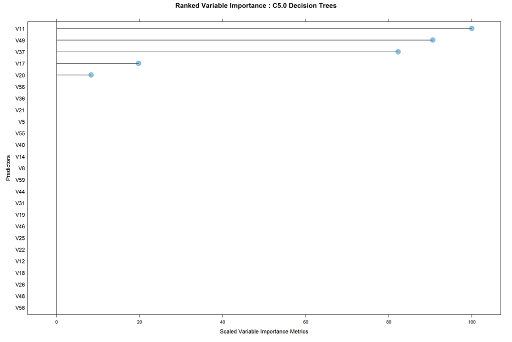

```r
##################################
# Identifying and plotting the
# best model predictors
##################################
C50_VarImp <- varImp(C50_Tune, scale = TRUE)
plot(C50_VarImp,
     top=25,
     scales=list(y=list(cex = .95)),
     main="Ranked Variable Importance : C5.0 Decision Trees",
     xlab="Scaled Variable Importance Metrics",
     ylab="Predictors",
     cex=2,
     origin=0,
     alpha=0.45)
```

```r
##################################
# Independently evaluating the model
# on the test set
##################################
C50_Test <- data.frame(C50_Observed = PMA_PreModelling_Test$Class,
                      C50_Predicted = predict(C50_Tune,
                      PMA_PreModelling_Test[,!names(PMA_PreModelling_Test) %in% c("Class")],
                      type = "raw"))

C50_Test
```

```
##    C50_Observed C50_Predicted
## 1             M             M
## 2             M             M
## 3             M             M
## 4             M             M
## 5             M             M
## 6             M             R
## 7             M             M
## 8             M             R
## 9             M             M
## 10            M             R
## 11            M             M
## 12            M             M
## 13            M             M
## 14            M             M
```

[output cut: 26 more lines]

```r
##################################
# Reporting the independent evaluation results
# for the test set
##################################
(C50_Test_Specificity <- Specificity(y_pred = C50_Test$C50_Predicted,
                                       y_true = C50_Test$C50_Observed))
```

```
## [1] 0.1428571
```

```r
(C50_Test_ConfusionMatrix <- confusionMatrix(data = C50_Test$C50_Predicted,
                                               reference = C50_Test$C50_Observed))
```

```
## Confusion Matrix and Statistics
##
##           Reference
## Prediction  M  R
##          M 28  6
##          R  5  1
##
##                Accuracy : 0.725
##                  95% CI : (0.5611, 0.854)
##     No Information Rate : 0.825
##     P-Value [Acc > NIR] : 0.9632
##
##                   Kappa : -0.0092
##
##  Mcnemar's Test P-Value : 1.0000
##
##             Sensitivity : 0.8485
##             Specificity : 0.1429
##          Pos Pred Value : 0.8235
##          Neg Pred Value : 0.1667
##              Prevalence : 0.8250
##          Detection Rate : 0.7000
##    Detection Prevalence : 0.8500
##       Balanced Accuracy : 0.4957
##
##        'Positive' Class : M
##
```

### 1.5.6 Cost-Sensitive C5.0 Decision Trees (CS_C50)

**Code Chunk | Output**

```r
##################################
# Verifying the class distribution
# for the original data
##################################
table(PMA_PreModelling_Train$Class)
```

```
##
##  M  R
## 78 18
```

```r
##################################
# Creating a function for
# a customized summary metrics
##################################
fourMetricSummary <- function (data, lev = levels(data$obs), model = NULL)
{

  accKapp <- postResample(data[, "pred"], data[, "obs"])
  out <- c(accKapp,
           sensitivity(data[, "pred"], data[, "obs"], lev[1]),
           specificity(data[, "pred"], data[, "obs"], lev[2]))
  names(out)[3:4] <- c("Sensitivity", "Specificity")
  out
}

##################################
# Creating consistent fold assignments
# for the Repeated Cross Validation process
##################################
set.seed(12345678)
KFold_Control <- trainControl(method = "cv",
                                   classProbs = FALSE,
                                   summaryFunction = fourMetricSummary)

##################################
# Setting the conditions
# for hyperparameter tuning
##################################
CS_C50_Grid = expand.grid(trials = c(1:9, (1:10)*10),
                       model = c("tree", "rules"),
                       winnow = c(TRUE, FALSE))

##################################
# Formulating the cost matrix
##################################
CS_C50_CostMatrix <- matrix(c(0,1,4,0), ncol=2)
rownames(CS_C50_CostMatrix) <- levels(PMA_PreModelling_Train$Class)
colnames(CS_C50_CostMatrix) <- levels(PMA_PreModelling_Train$Class)
CS_C50_CostMatrix
```

```
##   M R
## M 0 4
## R 1 0
```

```r
##################################
# Running the C5.0 decision trees model
# by setting the caret method to 'C5.0'
##################################
set.seed(12345678)
CS_C50_Tune <- train(x = PMA_PreModelling_Train[,!names(PMA_PreModelling_Train) %in% c("Class")],
                 y = PMA_PreModelling_Train$Class,
                 method = "C5.0",
                 tuneGrid = CS_C50_Grid,
                 metric = "Specificity",
                 trControl = KFold_Control,
                 parms = list(loss=CS_C50_CostMatrix))

##################################
# Reporting the cross-validation results
# for the train set
##################################
CS_C50_Tune
```

```
## C5.0
##
## 96 samples
## 60 predictors
##  2 classes: 'M', 'R'
##
## No pre-processing
## Resampling: Cross-Validated (10 fold)
## Summary of sample sizes: 86, 87, 86, 87, 87, 86, ...
## Resampling results across tuning parameters:
##
##   model  winnow  trials  Accuracy   Kappa      Sensitivity  Specificity
##   rules  FALSE     1     0.8444444  0.3945908  0.9232143    0.50
##   rules  FALSE     2     0.8333333  0.2971608  0.9482143    0.35
##   rules  FALSE     3     0.8533333  0.4043357  0.9464286    0.45
##   rules  FALSE     4     0.8333333  0.1839465  0.9875000    0.20
##   rules  FALSE     5     0.8655556  0.3811992  0.9732143    0.40
##   rules  FALSE     6     0.8655556  0.3811992  0.9732143    0.40
##   rules  FALSE     7     0.8655556  0.3811992  0.9732143    0.40
##   rules  FALSE     8     0.8655556  0.3811992  0.9732143    0.40
##   rules  FALSE     9     0.8544444  0.3603297  0.9607143    0.40
##   rules  FALSE    10     0.8655556  0.3811992  0.9732143    0.40
##   rules  FALSE    20     0.8877778  0.4454849  1.0000000    0.40
##   rules  FALSE    30     0.8877778  0.4454849  1.0000000    0.40
##   rules  FALSE    40     0.8766667  0.4063545  0.9875000    0.40
##   rules  FALSE    50     0.8655556  0.3672241  0.9875000    0.35
##   rules  FALSE    60     0.8655556  0.3672241  0.9875000    0.35
##   rules  FALSE    70     0.8655556  0.3672241  0.9875000    0.35
##   rules  FALSE    80     0.8655556  0.3672241  0.9875000    0.35
##   rules  FALSE    90     0.8655556  0.3672241  0.9875000    0.35
##   rules  FALSE   100     0.8766667  0.4063545  0.9875000    0.40
##   rules   TRUE     1     0.8155556  0.1465909  0.9500000    0.20
##   rules   TRUE     2     0.8144444  0.2106294  0.9375000    0.30
##   rules   TRUE     3     0.8044444  0.1865909  0.9250000    0.30
##   rules   TRUE     4     0.8144444  0.2106294  0.9375000    0.30
##   rules   TRUE     5     0.8144444  0.2106294  0.9375000    0.30
##   rules   TRUE     6     0.8144444  0.2106294  0.9375000    0.30
##   rules   TRUE     7     0.8144444  0.2106294  0.9375000    0.30
##   rules   TRUE     8     0.8144444  0.2106294  0.9375000    0.30
##   rules   TRUE     9     0.8144444  0.2106294  0.9375000    0.30
```

[output cut: 37 more lines]

```
##   tree    TRUE     9     0.8044444  0.1952448  0.9250000    0.30
##   tree    TRUE    10     0.8044444  0.1952448  0.9250000    0.30
##   tree    TRUE    20     0.8044444  0.1952448  0.9250000    0.30
##   tree    TRUE    30     0.8044444  0.1952448  0.9250000    0.30
##   tree    TRUE    40     0.8044444  0.1952448  0.9250000    0.30
##   tree    TRUE    50     0.8044444  0.1952448  0.9250000    0.30
##   tree    TRUE    60     0.8044444  0.1952448  0.9250000    0.30
##   tree    TRUE    70     0.8044444  0.1952448  0.9250000    0.30
##   tree    TRUE    80     0.8044444  0.1952448  0.9250000    0.30
##   tree    TRUE    90     0.8044444  0.1952448  0.9250000    0.30
##   tree    TRUE   100     0.8044444  0.1952448  0.9250000    0.30
##
## Specificity was used to select the optimal model using the largest value.
## The final values used for the model were trials = 1, model = tree and winnow
##  = FALSE.
```

```r
CS_C50_Tune$finalModel
```

```
##
## Call:
## (function (x, y, trials = 1, rules = FALSE, weights = NULL, control
##  = 3942L), parms = list(loss = structure(c(0, 1, 4, 0), dim = c(2L,
##  2L), dimnames = list(c("M", "R"), c("M", "R")))))
##
## Classification Tree
## Number of samples: 96
## Number of predictors: 60
##
## Tree size: 6
##
## Non-standard options: attempt to group attributes
```

```r
CS_C50_Tune$results
```

```
##    model winnow trials  Accuracy     Kappa Sensitivity Specificity AccuracySD
## 39 rules  FALSE      1 0.8444444 0.3945908   0.9232143        0.50 0.08764563
## 58 rules   TRUE      1 0.8155556 0.1465909   0.9500000        0.20 0.10213093
## 1   tree  FALSE      1 0.8322222 0.4030199   0.8964286        0.55 0.11468930
## 20  tree   TRUE      1 0.7955556 0.1147589   0.9250000        0.20 0.11357756
## 40 rules  FALSE      2 0.8333333 0.2971608   0.9482143        0.35 0.05341557
## 59 rules   TRUE      2 0.8144444 0.2106294   0.9375000        0.30 0.10371032
## 2   tree  FALSE      2 0.8233333 0.2482776   0.9500000        0.30 0.04870054
## 21  tree   TRUE      2 0.8155556 0.1552448   0.9500000        0.20 0.11248533
## 41 rules  FALSE      3 0.8533333 0.4043357   0.9464286        0.45 0.09293271
## 60 rules   TRUE      3 0.8044444 0.1865909   0.9250000        0.30 0.09927031
## 3   tree  FALSE      3 0.8222222 0.3149126   0.9214286        0.40 0.10210406
## 22  tree   TRUE      3 0.7844444 0.1547589   0.9000000        0.30 0.10876536
## 42 rules  FALSE      4 0.8333333 0.1839465   0.9875000        0.20 0.05341557
## 61 rules   TRUE      4 0.8144444 0.2106294   0.9375000        0.30 0.10371032
```

[output cut: 139 more lines]

```r
(CS_C50_Train_Specificity <- CS_C50_Tune$results[CS_C50_Tune$results$trials==CS_C50_Tune$bestTune$trials &
                                             CS_C50_Tune$results$model==CS_C50_Tune$bestTune$model &
                                             CS_C50_Tune$results$winnow==CS_C50_Tune$bestTune$winnow,
                              c("Specificity")])
```

```
## [1] 0.55
```

```r
CS_C50_Train <- data.frame(CS_C50_Observed = PMA_PreModelling_Train$Class,
                      CS_C50_Predicted = predict(CS_C50_Tune,
                      PMA_PreModelling_Train[,!names(PMA_PreModelling_Train) %in% c("Class")],
                      type = "raw"))

(CS_C50_Train_ConfusionMatrix <- confusionMatrix(data = CS_C50_Train$CS_C50_Predicted,
                                                  reference = CS_C50_Train$CS_C50_Observed))
```

```
## Confusion Matrix and Statistics
##
##           Reference
## Prediction  M  R
##          M 77  1
##          R  1 17
##
##                Accuracy : 0.9792
##                  95% CI : (0.9268, 0.9975)
##     No Information Rate : 0.8125
##     P-Value [Acc > NIR] : 5.86e-07
##
##                   Kappa : 0.9316
##
##  Mcnemar's Test P-Value : 1
##
##             Sensitivity : 0.9872
##             Specificity : 0.9444
##          Pos Pred Value : 0.9872
##          Neg Pred Value : 0.9444
##              Prevalence : 0.8125
##          Detection Rate : 0.8021
##    Detection Prevalence : 0.8125
##       Balanced Accuracy : 0.9658
##
##        'Positive' Class : M
##
```

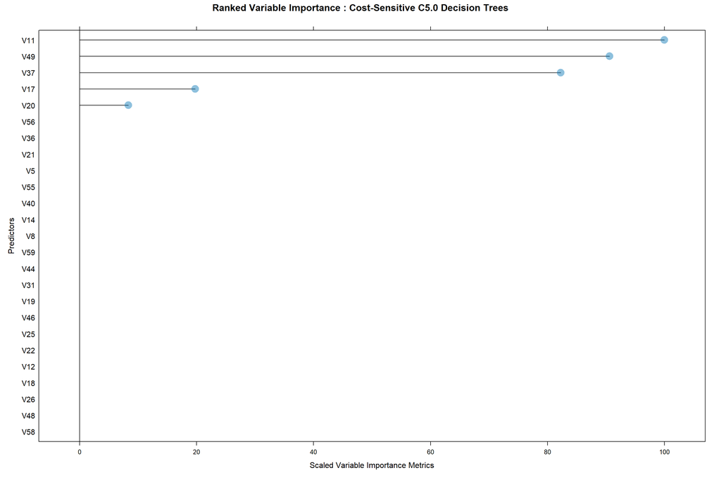

```r
##################################
# Identifying and plotting the
# best model predictors
##################################
CS_C50_VarImp <- varImp(CS_C50_Tune, scale = TRUE)
plot(CS_C50_VarImp,
     top=25,
     scales=list(y=list(cex = .95)),
     main="Ranked Variable Importance : Cost-Sensitive C5.0 Decision Trees",
     xlab="Scaled Variable Importance Metrics",
     ylab="Predictors",
     cex=2,
     origin=0,
     alpha=0.45)
```

```r
##################################
# Independently evaluating the model
# on the test set
##################################
CS_C50_Test <- data.frame(CS_C50_Observed = PMA_PreModelling_Test$Class,
                      CS_C50_Predicted = predict(CS_C50_Tune,
                      PMA_PreModelling_Test[,!names(PMA_PreModelling_Test) %in% c("Class")],
                      type = "raw"))

CS_C50_Test
```

```
##    CS_C50_Observed CS_C50_Predicted
## 1                M                M
## 2                M                M
## 3                M                M
## 4                M                M
## 5                M                M
## 6                M                R
## 7                M                M
## 8                M                R
## 9                M                M
## 10               M                R
## 11               M                M
## 12               M                M
## 13               M                M
## 14               M                M
```

[output cut: 26 more lines]

```r
##################################
# Reporting the independent evaluation results
# for the test set
##################################
(CS_C50_Test_Specificity <- Specificity(y_pred = CS_C50_Test$CS_C50_Predicted,
                                       y_true = CS_C50_Test$CS_C50_Observed))
```

```
## [1] 0.1428571
```

```r
(CS_C50_Test_ConfusionMatrix <- confusionMatrix(data = CS_C50_Test$CS_C50_Predicted,
                                               reference = CS_C50_Test$CS_C50_Observed))
```

```
## Confusion Matrix and Statistics
##
##           Reference
## Prediction  M  R
##          M 28  6
##          R  5  1
##
##                Accuracy : 0.725
##                  95% CI : (0.5611, 0.854)
##     No Information Rate : 0.825
##     P-Value [Acc > NIR] : 0.9632
##
##                   Kappa : -0.0092
##
##  Mcnemar's Test P-Value : 1.0000
##
##             Sensitivity : 0.8485
##             Specificity : 0.1429
##          Pos Pred Value : 0.8235
##          Neg Pred Value : 0.1667
##              Prevalence : 0.8250
##          Detection Rate : 0.7000
##    Detection Prevalence : 0.8500
##       Balanced Accuracy : 0.4957
##
##        'Positive' Class : M
##
```

## 1.6 Consolidated Findings

**[A]** Cross-validation and test results were observed to be generally unstable potentially driven by the low case numbers in the analysis.  
**[B]** The model which demonstrated the most consistent improvement in specificity metric after cost-sensitive training is as follows:  
**[B.1]** **SVM_R: Support Vector Machine - Radial Basis Function Kernel**  
**[B.1.1]** Test Specificity = 0.14286, Cross-Validation Specificity = 0.60000  
**[B.2]** **CW_SVM_R: Class-Weighted Support Vector Machine - Radial Basis Function Kernel**  
**[B.2.1]** Test Specificity = 0.28571, Cross-Validation Specificity = 0.65000

**Code Chunk | Output**

```r
##################################
# Consolidating all evaluation results
# for the train and test sets
# using the specificity metric
##################################
Model <- c('SVM_R','CW_SVM_R','CART','CS_CART','C50','CS_C50',
           'SVM_R','CW_SVM_R','CART','CS_CART','C50','CS_C50')

Set <- c(rep('Cross-Validation',6),rep('Test',6))

Specificity <- c(SVM_R_Train_Specificity,
                 CW_SVM_R_Train_Specificity,
                 CART_Train_Specificity,
                 CS_CART_Train_Specificity,
                 C50_Train_Specificity,
                 CS_C50_Train_Specificity,
                 SVM_R_Test_Specificity,
                 CW_SVM_R_Test_Specificity,
                 CART_Test_Specificity,
                 CS_CART_Test_Specificity,
                 C50_Test_Specificity,
                 CS_C50_Test_Specificity)

Specificity_Summary <- as.data.frame(cbind(Model,Set,Specificity))

Specificity_Summary$Specificity <- as.numeric(as.character(Specificity_Summary$Specificity))
Specificity_Summary$Set <- factor(Specificity_Summary$Set,
                                        levels = c("Cross-Validation",
                                                   "Test"))
Specificity_Summary$Model <- factor(Specificity_Summary$Model,
                                        levels =c('SVM_R',
                                                  'CW_SVM_R',
                                                  'CART',
                                                  'CS_CART',
                                                  'C50',
                                                  'CS_C50'))

print(Specificity_Summary, row.names=FALSE)
```

```
##     Model              Set Specificity
##     SVM_R Cross-Validation   0.6000000
##  CW_SVM_R Cross-Validation   0.6500000
##      CART Cross-Validation   0.4500000
##   CS_CART Cross-Validation   0.3000000
##       C50 Cross-Validation   0.5500000
##    CS_C50 Cross-Validation   0.5500000
##     SVM_R             Test   0.1428571
##  CW_SVM_R             Test   0.2857143
##      CART             Test   0.2857143
##   CS_CART             Test   0.7142857
##       C50             Test   0.1428571
##    CS_C50             Test   0.1428571
```

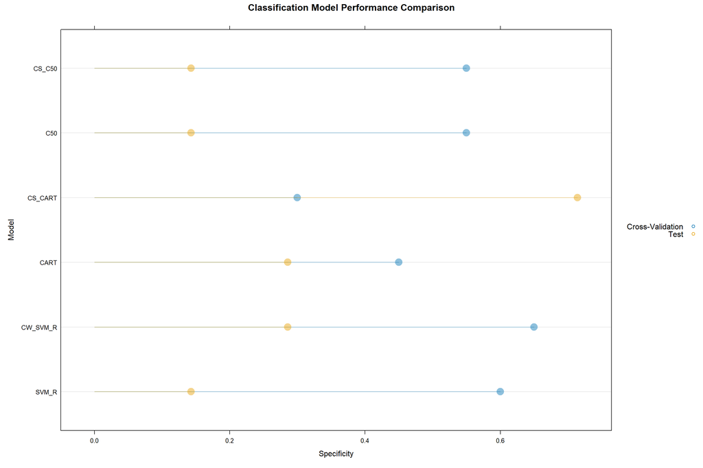

```r
(Specificity_Plot <- dotplot(Model ~ Specificity,
                           data = Specificity_Summary,
                           groups = Set,
                           main = "Classification Model Performance Comparison",
                           ylab = "Model",
                           xlab = "Specificity",
                           auto.key = list(adj = 1),
                           type=c("p", "h"),
                           origin = 0,
                           alpha = 0.45,
                           pch = 16,
                           cex = 2))
```

```r
##################################
# Consolidating the resampling results
# for the candidate models
##################################
(COST_COMPARISON_RESAMPLING <- resamples(list(SVM_R = SVM_R_Tune,
                                              CW_SVM_R = SVM_R_Tune,
                                              CART = CART_Tune,
                                              CS_CART = CS_CART_Tune,
                                              C50 = C50_Tune,
                                              CS_C50 = CS_C50_Tune)))
```

```
##
## Call:
## resamples.default(x = list(SVM_R = SVM_R_Tune, CW_SVM_R = SVM_R_Tune, CART
##  = CART_Tune, CS_CART = CS_CART_Tune, C50 = C50_Tune, CS_C50 = CS_C50_Tune))
##
## Models: SVM_R, CW_SVM_R, CART, CS_CART, C50, CS_C50
## Number of resamples: 10
## Performance metrics: Accuracy, Kappa, Sensitivity, Specificity
## Time estimates for: everything, final model fit
```

```r
summary(COST_COMPARISON_RESAMPLING)
```

```
##
## Call:
## summary.resamples(object = COST_COMPARISON_RESAMPLING)
##
## Models: SVM_R, CW_SVM_R, CART, CS_CART, C50, CS_C50
## Number of resamples: 10
##
## Accuracy
##               Min.   1st Qu.    Median      Mean   3rd Qu. Max. NA's
## SVM_R    0.8000000 0.8916667 0.9000000 0.9277778 1.0000000  1.0    0
## CW_SVM_R 0.8000000 0.8916667 0.9000000 0.9277778 1.0000000  1.0    0
## CART     0.6000000 0.7194444 0.7888889 0.7922222 0.8750000  1.0    0
## CS_CART  0.4000000 0.7777778 0.8000000 0.7600000 0.8666667  0.9    0
## C50      0.6666667 0.7777778 0.8000000 0.8322222 0.9000000  1.0    0
## CS_C50   0.6666667 0.7777778 0.8000000 0.8322222 0.9000000  1.0    0
##
## Kappa
##                Min.     1st Qu.     Median      Mean   3rd Qu.      Max. NA's
## SVM_R     0.0000000  0.61036789 0.61538462 0.6454849 1.0000000 1.0000000    0
## CW_SVM_R  0.0000000  0.61036789 0.61538462 0.6454849 1.0000000 1.0000000    0
## CART     -0.2500000 -0.09375000 0.29090909 0.2829196 0.5979021 1.0000000    0
## CS_CART  -0.3636364  0.00000000 0.02631579 0.1696080 0.4884868 0.6153846    0
## C50      -0.1538462  0.04545455 0.38750000 0.4030199 0.7064777 1.0000000    0
## CS_C50   -0.1538462  0.04545455 0.38750000 0.4030199 0.7064777 1.0000000    0
##
## Sensitivity
##               Min.   1st Qu. Median      Mean 3rd Qu. Max. NA's
## SVM_R    1.0000000 1.0000000 1.0000 1.0000000       1    1    0
## CW_SVM_R 1.0000000 1.0000000 1.0000 1.0000000       1    1    0
## CART     0.7142857 0.7500000 0.8750 0.8714286       1    1    0
## CS_CART  0.5000000 0.7544643 0.9375 0.8535714       1    1    0
## C50      0.7142857 0.8750000 0.8750 0.8964286       1    1    0
## CS_C50   0.7142857 0.8750000 0.8750 0.8964286       1    1    0
##
## Specificity
##          Min. 1st Qu. Median Mean 3rd Qu. Max. NA's
## SVM_R       0   0.500   0.50 0.60   1.000    1    0
## CW_SVM_R    0   0.500   0.50 0.60   1.000    1    0
## CART        0   0.000   0.50 0.45   0.875    1    0
## CS_CART     0   0.000   0.25 0.30   0.500    1    0
## C50         0   0.125   0.50 0.55   1.000    1    0
## CS_C50      0   0.125   0.50 0.55   1.000    1    0
```

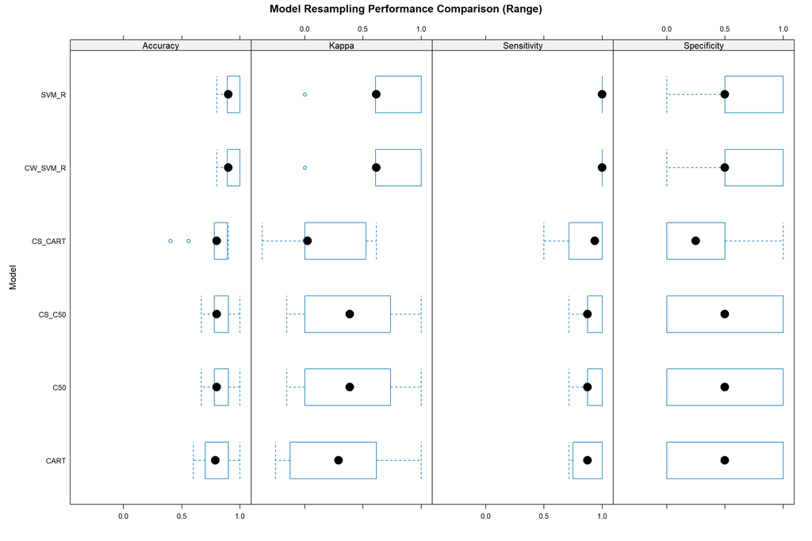

```r
##################################
# Exploring the resampling results
##################################
bwplot(COST_COMPARISON_RESAMPLING,
       main = "Model Resampling Performance Comparison (Range)",
       ylab = "Model",
       pch = 16,
       cex = 2,
       layout=c(4,1))
```

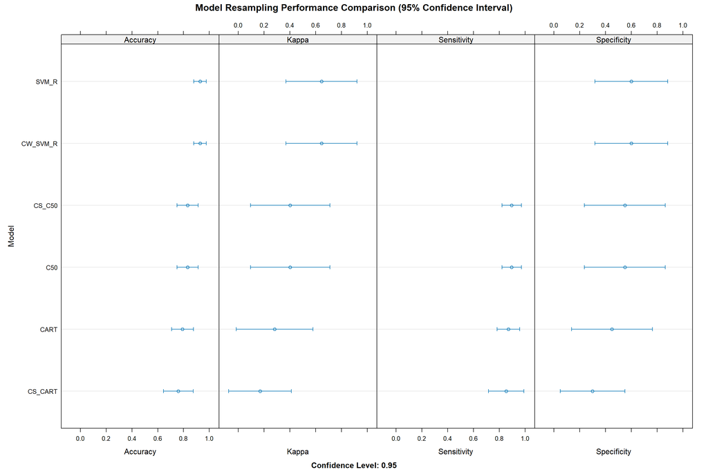

```r
dotplot(COST_COMPARISON_RESAMPLING,
       main = "Model Resampling Performance Comparison (95% Confidence Interval)",
       ylab = "Model",
       pch = 16,
       cex = 2,
       layout=c(4,1))
```

```r
##################################
# Consolidating all models
##################################
(COST_COMPARISON_MODELS <- (list(SVM_R = SVM_R_Tune,
                                 CW_SVM_R = CW_SVM_R_Tune,
                                 CART = CART_Tune,
                                 CS_CART = CS_CART_Tune,
                                 C50 = C50_Tune,
                                 CS_C50 = CS_C50_Tune)))
```

```
## $SVM_R
## Support Vector Machines with Radial Basis Function Kernel
##
## 96 samples
## 60 predictors
##  2 classes: 'M', 'R'
##
## Pre-processing: centered (60), scaled (60)
## Resampling: Cross-Validated (10 fold)
## Summary of sample sizes: 86, 87, 86, 87, 87, 86, ...
## Resampling results across tuning parameters:
##
##   C           Accuracy   Kappa      Sensitivity  Specificity
##   0.01562500  0.8133333  0.0000000  1            0.0
##   0.02209709  0.8133333  0.0000000  1            0.0
##   0.03125000  0.8133333  0.0000000  1            0.0
##   0.04419417  0.8133333  0.0000000  1            0.0
##   0.06250000  0.8133333  0.0000000  1            0.0
##   0.08838835  0.8133333  0.0000000  1            0.0
##   0.12500000  0.8133333  0.0000000  1            0.0
##   0.17677670  0.8133333  0.0000000  1            0.0
##   0.25000000  0.8133333  0.0000000  1            0.0
##   0.35355339  0.8133333  0.0000000  1            0.0
##   0.50000000  0.8133333  0.0000000  1            0.0
##   0.70710678  0.8133333  0.0000000  1            0.0
##   1.00000000  0.8655556  0.3224080  1            0.3
##   1.41421356  0.9066667  0.5678930  1            0.5
##   2.00000000  0.9277778  0.6454849  1            0.6
##
## Tuning parameter 'sigma' was held constant at a value of 0.008732089
## Specificity was used to select the optimal model using the largest value.
## The final values used for the model were sigma = 0.008732089 and C = 2.
##
## $CW_SVM_R
## Support Vector Machines with Radial Basis Function Kernel
##
## 96 samples
## 60 predictors
##  2 classes: 'M', 'R'
##
```

[output cut: 246 more lines]

```
##   tree    TRUE     9     0.8044444  0.1952448  0.9250000    0.30
##   tree    TRUE    10     0.8044444  0.1952448  0.9250000    0.30
##   tree    TRUE    20     0.8044444  0.1952448  0.9250000    0.30
##   tree    TRUE    30     0.8044444  0.1952448  0.9250000    0.30
##   tree    TRUE    40     0.8044444  0.1952448  0.9250000    0.30
##   tree    TRUE    50     0.8044444  0.1952448  0.9250000    0.30
##   tree    TRUE    60     0.8044444  0.1952448  0.9250000    0.30
##   tree    TRUE    70     0.8044444  0.1952448  0.9250000    0.30
##   tree    TRUE    80     0.8044444  0.1952448  0.9250000    0.30
##   tree    TRUE    90     0.8044444  0.1952448  0.9250000    0.30
##   tree    TRUE   100     0.8044444  0.1952448  0.9250000    0.30
##
## Specificity was used to select the optimal model using the largest value.
## The final values used for the model were trials = 1, model = tree and winnow
##  = FALSE.
```

```r
##################################
# Creating a function model performance
# on test data
##################################
COST_COMPARISON_TEST_Specificity <- function(model, data) {
  Data_Test <- data.frame(Observed = data$Class,
                          Predicted = predict(model,
                                              data[,!names(data) %in% c("Class")],
                      type = "raw"))
  Specificity <- Specificity(y_pred = Data_Test$Predicted,
                             y_true = Data_Test$Observed)
  return(Specificity)
}


COST_COMPARISON_TEST_SUMMARY <- lapply(COST_COMPARISON_MODELS,
                                       COST_COMPARISON_TEST_Specificity,
                                       data = PMA_PreModelling_Test)
COST_COMPARISON_TEST_SUMMARY <- lapply(COST_COMPARISON_TEST_SUMMARY, as.vector)
COST_COMPARISON_TEST_SUMMARY <- do.call("rbind", COST_COMPARISON_TEST_SUMMARY)
colnames(COST_COMPARISON_TEST_SUMMARY) <- c("Specificity")
(COST_COMPARISON_TEST_SUMMARY <- as.data.frame(COST_COMPARISON_TEST_SUMMARY))
```

```
##          Specificity
## SVM_R      0.1428571
## CW_SVM_R   0.2857143
## CART       0.2857143
## CS_CART    0.7142857
## C50        0.1428571
## CS_C50     0.1428571
```

# **2. Summary**

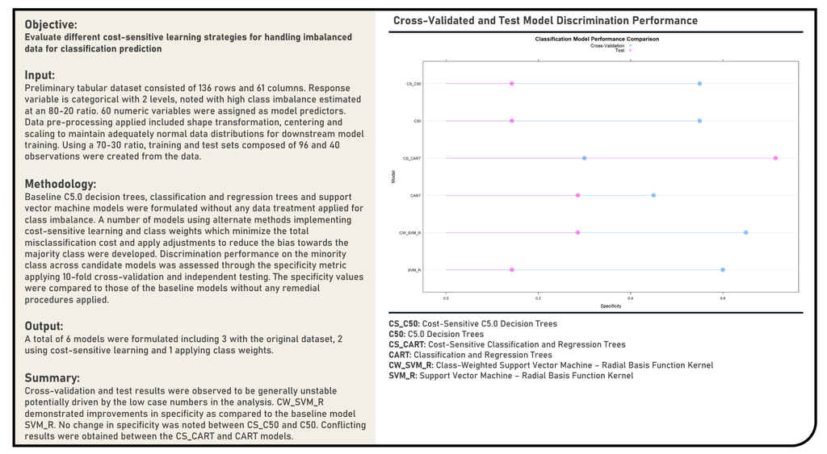

# **3. References**

**[Book]** [Applied Predictive Modeling](http://appliedpredictivemodeling.com/) by Max Kuhn and Kjell Johnson  
**[Book]** [An Introduction to Statistical Learning](https://www.statlearning.com/) by Gareth James, Daniela Witten, Trevor Hastie and Rob Tibshirani  
**[Book]** [Multivariate Data Visualization with R](http://lmdvr.r-forge.r-project.org/figures/figures.html) by Deepayan Sarkar  
**[Book]** [Machine Learning](https://bookdown.org/ssjackson300/Machine-Learning-Lecture-Notes/) by Samuel Jackson  
**[Book]** [Data Modeling Methods](https://bookdown.org/larget_jacob/data-modeling-methods/) by Jacob Larget  
**[Book]** [Reproducible Machine Learning for Credit Card Fraud Detection](https://bookdown.org/larget_jacob/data-modeling-methods/) by Yann-Aël Le Borgne, Wissam Siblini, Bertrand Lebichot and Gianluca Bontempi  
**[Book]** [Encyclopedia of Machine Learning](https://link.springer.com/referencework/10.1007/978-0-387-30164-8) by Claude Sammut and Geoffrey Webb  
**[R Package]** [AppliedPredictiveModeling](https://cran.r-project.org/web//packages/AppliedPredictiveModeling/AppliedPredictiveModeling.pdf) by Max Kuhn  
**[R Package]** [caret](https://topepo.github.io/caret/index.html) by Max Kuhn  
**[R Package]** [rpart](https://mran.microsoft.com/web/packages/rpart/rpart.pdf) by Terry Therneau and Beth Atkinson  
**[R Package]** [lattice](https://cran.r-project.org/web/packages/lattice/lattice.pdf) by Deepayan Sarkar  
**[R Package]** [dplyr](https://cran.r-project.org/web/packages/dplyr/index.html/) by Hadley Wickham  
**[R Package]** [moments](https://cran.r-project.org/web/packages/moments/index.html) by Lukasz Komsta and Frederick  
**[R Package]** [skimr](https://cran.r-project.org/web/packages/skimr/skimr.pdf) by Elin Waring  
**[R Package]** [RANN](https://cran.r-project.org/web/packages/RANN/RANN.pdf) by Sunil Arya, David Mount, Samuel Kemp and Gregory Jefferis  
**[R Package]** [corrplot](https://cran.r-project.org/web/packages/corrplot/corrplot.pdf) by Taiyun Wei  
**[R Package]** [tidyverse](https://cran.r-project.org/web/packages/tidyverse/tidyverse.pdf) by Hadley Wickham  
**[R Package]** [lares](https://cran.rstudio.com/web/packages/lares/lares.pdf) by Bernardo Lares  
**[R Package]** [DMwR2](https://mran.microsoft.com/snapshot/2016-05-02/web/packages/DMwR/DMwR.pdf) by Luis Torgo  
**[R Package]** [gridExtra](https://cran.r-project.org/web/packages/gridExtra/gridExtra.pdf) by Baptiste Auguie and Anton Antonov  
**[R Package]** [rattle](https://cran.r-project.org/web/packages/rattle/rattle.pdf) by Graham Williams  
**[R Package]** [rpart.plot](https://cran.r-project.org/web/packages/rpart.plot/rpart.plot.pdf) by Stephen Milborrow  
**[R Package]** [RColorBrewer](https://cran.r-project.org/web//packages/RColorBrewer/RColorBrewer.pdf) by Erich Neuwirth  
**[R Package]** [stats](https://search.r-project.org/R/refmans/stats/html/00Index.html) by R Core Team  
**[R Package]** [pls](https://cran.r-project.org/web/packages/pls/pls.pdf) by Kristian Hovde Liland  
**[R Package]** [nnet](https://cran.r-project.org/web/packages/nnet/nnet.pdf) by Brian Ripley  
**[R Package]** [elasticnet](https://cran.r-project.org/web/packages/elasticnet/elasticnet.pdf) by Hui Zou  
**[R Package]** [earth](https://cran.r-project.org/web/packages/earth/earth.pdf) by Stephen Milborrow  
**[R Package]** [party](https://cran.r-project.org/web/packages/party/party.pdf) by Torsten Hothorn  
**[R Package]** [kernlab](https://cran.r-project.org/web/packages/kernlab/kernlab.pdf) by Alexandros Karatzoglou  
**[R Package]** [randomForest](https://cran.r-project.org/web/packages/randomForest/randomForest.pdf) by Andy Liaw  
**[R Package]** [pROC](https://cran.r-project.org/web/packages/pROC/pROC.pdf) by Xavier Robin  
**[R Package]** [mda](https://cran.r-project.org/web/packages/mda/mda.pdf) by Trevor Hastie  
**[R Package]** [klaR](https://cran.r-project.org/web/packages/klaR/klaR.pdf) by Christian Roever, Nils Raabe, Karsten Luebke, Uwe Ligges, Gero Szepannek, Marc Zentgraf and David Meyer  
**[R Package]** [pamr](https://cran.r-project.org/web/packages/pamr/pamr.pdf) by Trevor Hastie, Rob Tibshirani, Balasubramanian Narasimhan and Gil Chu  
**[R Package]** [MLmetrics](https://cran.r-project.org/web/packages/MLmetrics/MLmetrics.pdf) by Yachen Yan  
**[R Package]** [C50](https://cran.r-project.org/web/packages/C50/C50.pdf) by Mak Kuhn  
**[Article]** [The caret Package](https://topepo.github.io/caret/index.html) by Max Kuhn  
**[Article]** [A Short Introduction to the caret Package](https://cran.r-project.org/web/packages/caret/vignettes/caret.html) by Max Kuhn  
**[Article]** Caret Package – A Practical Guide to Machine Learning in R by Selva Prabhakaran  
**[Article]** [Tuning Machine Learning Models Using the Caret R Package](https://machinelearningmastery.com/tuning-machine-learning-models-using-the-caret-r-package/) by Jason Brownlee  
**[Article]** [Lattice Graphs](http://www.sthda.com/english/wiki/lattice-graphs) by Alboukadel Kassambara  
**[Article]** [A Tour of Machine Learning Algorithms](https://machinelearningmastery.com/a-tour-of-machine-learning-algorithms/) by Jason Brownlee  
**[Article]** [Decision Tree Algorithm Examples In Data Mining](https://www.softwaretestinghelp.com/decision-tree-algorithm-examples-data-mining/) by Software Testing Help Team  
**[Article]** [4 Types of Classification Tasks in Machine Learning](https://machinelearningmastery.com/types-of-classification-in-machine-learning/) by Jason Brownlee  
**[Article]** [Spot-Check Classification Machine Learning Algorithms in Python with scikit-learn](https://machinelearningmastery.com/spot-check-classification-machine-learning-algorithms-python-scikit-learn/) by Jason Brownlee  
**[Article]** [Feature Engineering and Selection: A Practical Approach for Predictive Models](http://www.feat.engineering/index.html) by Max Kuhn and Kjell Johnson  
**[Article]** [Machine Learning Tutorial: A Step-by-Step Guide for Beginners](http://www.feat.engineering/index.html) by Mayank Banoula  
**[Article]** [Classification Tree](https://support.bccvl.org.au/support/solutions/articles/6000083204-classification-tree) by BCCVL Team  
**[Article]** [C5.0: An Informal Tutorial](https://www.rulequest.com/see5-unix.html) by RuleQuest Team  
**[Article]** [Understand Support Vector Machine In Depth](https://iq.opengenus.org/understand-support-vector-machine-in-depth/) by IQ OpenGenus Team  
**[Article]** [A Gentle Introduction to Imbalanced Classification](https://machinelearningmastery.com/what-is-imbalanced-classification/) by Jason Brownlee  
**[Article]** [8 Tactics to Combat Imbalanced Classes in Your Machine Learning Dataset](https://support.bccvl.org.au/support/solutions/articles/6000083212-generalized-boosting-model) by Jason Brownlee  
**[Article]** [Step-By-Step Framework for Imbalanced Classification Projects](https://machinelearningmastery.com/framework-for-imbalanced-classification-projects/) by Jason Brownlee  
**[Article]** [How to Handle Imbalanced Classes in Machine Learning](https://elitedatascience.com/imbalanced-classes) by Elite Data Science Team  
**[Article]** [Best Ways To Handle Imbalanced Data in Machine Learning](https://dataaspirant.com/handle-imbalanced-data-machine-learning/) by Jaiganesh Nagidi  
**[Article]** [Handling Imbalanced Data for Classification](https://www.geeksforgeeks.org/handling-imbalanced-data-for-classification/) by Geeks For Geeks Team  
**[Article]** [Cost-Sensitive Learning for Imbalanced Classification](https://machinelearningmastery.com/cost-sensitive-learning-for-imbalanced-classification/) by Jason Brownlee  
**[Article]** [Cost-Sensitive SVM for Imbalanced Classification](https://machinelearningmastery.com/cost-sensitive-svm-for-imbalanced-classification/) by Jason Brownlee  
**[Article]** [Cost-Sensitive Learning](https://ml-concepts.com/2021/10/08/3-cost-sensitive-learning/) by Sourabh Gupta  
**[Article]** [Cost-Sensitive Classification](https://mlr.mlr-org.com/articles/tutorial/cost_sensitive_classif.html) by MLR Org Team  
**[Article]** [Cost-Sensitive Learning and the Class Imbalance Problem](https://www.csd.uwo.ca/~xling/papers/cost_sensitive.pdf) by Charles Ling and Victor Sheng  
**[Publication]** [Support Vector Regression Machines](http://www.cs.cmu.edu/~pakyan/compbio/references/Drucker_NIPS_1996.pdf) by Harris Drucker, Chris Burges, Linda Kaufman, Alex Smola and Vladimir Vapnik (Advances in Neural Information Processing Systems)  
**[Publication]** [Classification and Regression Trees](https://www.semanticscholar.org/paper/Classification-and-Regression-Trees-Breiman-Friedman/8017699564136f93af21575810d557dba1ee6fc6) by Leo Breiman, Jerome Friedman, Richard Olshen, and Charles Stone (Computer Science)  
**[Publication]** [C4.5: Programs for Machine Learning](https://link.springer.com/article/10.1007/BF00993309) by Ross Quinlan  
**[Publication]** [Class-Weighted Evaluation Metrics for Imbalanced Data Classification](https://arxiv.org/abs/2010.05995) by Akhilesh Gupta, Nesime Tatbul, Ryan Marcus, Shengtian Zhou, Insup Lee and Justin Gottschlich (Arxiv Cornell University)  
**[Course]** [Applied Data Mining and Statistical Learning](https://online.stat.psu.edu/stat508/) by Penn State Eberly College of Science  
**[Course]** [Regression Methods](https://online.stat.psu.edu/stat501/) by Penn State Eberly College of Science  
**[Course]** [Applied Regression Analysis](https://online.stat.psu.edu/stat462/) by Penn State Eberly College of Science  
**[Course]** [Applied Data Mining and Statistical Learning](https://online.stat.psu.edu/stat508/) by Penn State Eberly College of Science